# Identifying Panel Conditioning with Refreshment Samples: Sharp Bounds and Design Assumptions

Author

Affiliation

Shoki Okubo

Department of Sociology, Toyo University

Published

October 1, 2026

Abstract

Refreshment samples are the standard remedy for panel attrition, and the identification results behind them maintain that participation does not change measurement. We characterize what a refreshment sample identifies about panel conditioning, modelled as a deterministic monotone map at reinterview, when attrition is unrestricted. A candidate map is consistent with the data if and only if the retention-scaled distribution of the stayers’ implied latent outcomes is setwise dominated by the refreshment distribution; every such map is rationalized by an explicit attrition process. Without attrition the map is identified on the latent-outcome support; with attrition, a density-ratio condition governs the identified set, and tail behaviour alone does not determine it. For an unrestricted map the survivors’ mean effect has the familiar trimming bounds; for an item with all categories reported, the model reduces to a test of no conditioning. Within a cohort, other waves, dropout patterns and entry-wave items leave the set unchanged unless restrictions link selection across waves. Under explicit selection restrictions, survival matching, symmetric matching and entry-wave correction identify survivor effects. We derive their biases and give rank conditions under which refreshment schedules identify curvature in the conditioning path. A Japanese panel illustrates the results.

Keywords

attrition, panel conditioning, partial identification, refreshment samples, rotation panels, survey design

# 1 Introduction

Research on refreshment samples and research on panel conditioning impose different restrictions on selection and measurement. The literature on attrition in panel surveys treats refreshment samples as the key to identification: a fresh cross-section drawn at a later wave reveals the population distribution that the retained sample no longer represents, and under additively separable models of nonignorable attrition the joint distribution can be recovered (Hirano et al. 2001; Deng et al. 2013). These models maintain that survey participation does not alter measurement. In Hirano et al. (2001) the restriction enters through the refreshment sample, which is treated as a fresh draw from the same population. The paper discusses repeated response and the possibility that effort during a first interview affects later response (Hirano et al. 2001, 1646, 1648), but its attrition model does not explicitly model changes in measurement caused by prior interviews. Deng et al. (2013) mention panel conditioning only in passing, when explaining why attrition bias in one panel differs from another [p. 250]. Their additive-nonignorable model restricts the attrition probability and not the measurement, and they note that a rotating panel supplies the equivalent of a refreshment sample so long as each cohort is randomly selected and administered the same questionnaire (Deng et al. 2013, 239).

The literature on panel conditioning documents that participation can alter reports (Warren and Halpern-Manners 2012; Bailar 1975) and treats attrition as a threat to its own comparisons. Warren and Halpern-Manners (2012, 508–10, 517) discuss attrition and mode as threats and describe comparisons of old and new cohorts restricted to two-wave survivors. Halpern-Manners and Warren (2012, 1506–8) compare adjacent rotation groups of the Current Population Survey within a calendar month, restricting both to respondents interviewed in both of their first two months. Halpern-Manners, Warren, and Torche (2017, 108–9 and note 14, p. 119) apply the same survival-matching comparison to the General Social Survey, explain the threat of attrition processes that differ by cohort, and give a regression diagnostic for it. Eckman and Bach (2021, 57, 64–65) apply it to four-wave respondents of the Consumer Expenditure Survey and state the assumption that respondents at different waves differ only in their exposure to the survey. A methodological review recommends such restrictions on the ground that they require no assumption about the form of attrition (Bach 2018, 14–15). Das, Toepoel, and van Soest (2011) bound conditioning effects for binary items under worst-case attrition and discuss the relation of their model to that of Hirano et al. (2001). They also note that the literature on panel conditioning typically assumes attrition to be completely at random or at random given the first-wave answer, whereas the attrition analysis of Hirano et al. (2001) weakens the assumptions on attrition but assumes that there is no panel conditioning (Das, Toepoel, and van Soest 2011, 43).

Official-statistics work on rotation group bias documents systematic differences by time in sample without being able to say how much of them is measurement. Krueger, Mas, and Niu (2017, 260, Table 1, and p. 262) find that adjusting for nonresponse accounts for more than one-third of the rise in rotation group bias after 1993, caution that their observational evidence cannot establish causation unambiguously, and suggest (p. 264) that the bias need not be an inherent consequence of repeated interviewing. Williams and Mallows (1970, 1338–39, 1342–43) showed that such contrasts can arise without any conditioning. If the probability of response depends on the characteristic under study and changes between interviews, estimates from units interviewed for the first and for the second time differ systematically, and restricting the comparison to units interviewed on both occasions does not remove the difference [p. 1339]. The selection term $\delta_e(t)$ of Equation 3 below is the counterpart here.

In this paper we characterize the sharp identified set for a deterministic monotone conditioning map under unrestricted attrition, and we state the additional distributional or mean restrictions that the comparison designs considered here require. The question is what a refreshment sample identifies about the conditioning map when the panel is subject to both nonignorable attrition and panel conditioning. We show that a candidate map is consistent with the data if and only if the retention-scaled distribution of the stayers’ implied latent outcomes is setwise dominated by the refreshment distribution (Theorem 1). The set so defined is sharp: every point in it is rationalized by an explicitly constructed attrition process.

The characterization has five implications for identification and survey design.

First, the constraint uses only the stayers’ reported outcome distribution, the refreshment distribution, and the retention rate. The stayers’ joint distribution with their baseline reports is not needed to identify the conditioning map; it matters only for reconstructing a selection process afterwards.

Second, with full retention the constraint collapses to an equality that identifies the map on the latent-outcome support as a quantile alignment, with no assumption on selection. As retention falls, the constraint relaxes into a set of observationally equivalent maps. For location shifts that set is governed by the ratio of the selection-weighted latent density to the refreshment density (Corollary 2). Tails constrain the set but do not determine it. When selection is bounded away from zero, a refreshment density with tails thinner than exponential excludes every perturbation that moves the implied latent distribution towards such a tail. The constraint must nevertheless hold at every outcome value, and it can bind in the centre of the distribution.

Third, two known bounds are related to the set. Das, Toepoel, and van Soest (2011) derive sharp worst-case bounds on the population conditioning effect for a binary item, of width equal to the attrition rate, and, in their online Appendix 1, the corresponding bounds on the survivors’ effect. Their model lets individual binary responses change at reinterview, whereas a weakly increasing deterministic map on a two-point support with both values reported can only fix both points, so the two models are compared and not nested. For the survivors’ mean effect under an unrestricted map, the sharp bounds are the trimming bounds of Horowitz and Manski (1995) and Lee (2009) (Corollary 6); they are $.70$ standard deviations wide at $80\%$ retention for a Gaussian refreshment distribution, and a location restriction narrows them.

Fourth, suppose that attrition does not depend on the latent outcome. The identified set for a location shift is then the sublevel set of the refreshment density’s shift-ratio function at the inverse retention rate (Corollary 3): a single point for the Gaussian and for any density with tails thinner than exponential, and an interval of half-width $\lambda^{-1}\log(1/p)$ for the Laplace and logistic densities. In that case conditioning is identified by a property of the population’s distribution and not by the absence of outcome-dependent attrition alone, and a plug-in width computed on a trimmed support measures the trim, not the selection (Remark 2).

Fifth, continuous and discrete items differ. For an item all of whose categories are reported by the stayers, the only admissible weakly increasing deterministic map is the identity, so the theorem reduces to a test of “no conditioning” that holds under every attrition process. Conditioning on such items requires a model beyond weakly increasing deterministic maps, such as a stochastic transition between response categories (Corollary 4).

Within a cohort, the longitudinal structure of a panel does not change this unless restrictions link the waves. Theorem 2 shows that, without restrictions linking selection across waves, the joint distribution of a cohort’s reports over many waves, the timing of its dropouts, and a battery of items asked once at entry do not narrow the identified set of the map at a given wave. The identified set of the map at a wave with a refreshment sample is the two-wave set computed from that wave’s respondents and its refreshment distribution, and the maps at other waves are unidentified. Every observed pattern of participation is reproduced by an explicit multiwave completion. Within the maintained model, additional identifying restrictions must therefore exclude otherwise feasible completions, and the necessity results below are statements about the full distribution of the data, not about a few moments.

We next ask which additional restrictions yield point identification. A single refreshment sample set-identifies conditioning. Two refreshment samples at different waves, generating several tenure configurations in common periods, together with an entry-wave negative-control battery and a transport restriction on selection with a known loading, point-identify the conditioning contrasts at the tenures observed at refreshment episodes (Theorem 4); a bounded loading gives a set. Overlapping birth years do not imply the transport restriction, which is maintained as an assumption. We distinguish two kinds of refreshment: *age-matched* refreshments, whose birth years overlap those of the incumbent cohorts (in the Japanese panel of Section 10, the 2011 refreshment), and *generational* refreshments, which recruit a new birth cohort with no overlap (the 2019 refreshment). For the latter, levels are only interval-identified under a bound on residual cohort effects, while increments between incumbent tenures remain identified under the same restrictions (Corollary 7). We thus obtain the identification theory behind single-refreshment comparisons and a design theory for panels that plan several refreshments.

The third part of the paper concerns the designs used in applied work, which combine a single refreshment sample with a restriction on attrition, often stated informally, to obtain a point estimate; the survival-matching comparison of Halpern-Manners, Warren, and Torche (2017) is one example. Section 7 expresses the comparability requirements of such designs as explicit restrictions on latent outcome means. Each is a restriction on the *selection functional*, the survivors’ advantage on the latent outcome, and each identifies the survivors’ mean shift. Survival matching takes the survivors’ latent mean from the later waves of the fresh cohort; a symmetric variant does so after equalizing the number of selection decisions; and an entry-wave correction takes it from the continuing cohort’s own entry wave, where reports are unconditioned by construction. The entry-wave functional is the observable combination used by Das, Toepoel, and van Soest (2011, 43–44, Assumption 3) under their stationary-attrition-bias assumption, which restricts conditioned outcomes and identifies a population conditioning effect. For binary outcomes, the survivor interpretation and its stationarity assumption on unconditioned outcomes are also explicit there (Das, Toepoel, and van Soest 2011, 41, and online Appendix 1, Assumption 3$^{\mathrm{Alt}}$, pp. 27–28): the same functional identifies the survivors’ conditioning effect under that alternative assumption. We formulate the restriction for general outcome means within the present multiwave framework, where it is a restriction on the selection functional, and analyse the symmetric comparison alongside it; the distinction between the two targets matters when effects are heterogeneous. We derive exact bias identities for each design and determine, under an explicit model with person-level traits, independent transient innovations and per-wave response decisions, which designs are biased under state-dependent and under non-stationary attrition, and the direction of the bias under state dependence (Proposition 5). The disagreements between designs then assess the compatibility of the maintained restrictions without uniquely identifying a failure mechanism (Section 8).

Section 9 treats the schedule itself as the object of choice. A rank condition determines, before any data are collected, which functionals of the conditioning path a proposed schedule identifies. The *stride* of the schedule, the greatest common divisor of the spacings between entry cohorts, fixes a set of directions that are never identified. A panel refreshed at a common interval greater than one therefore cannot identify ordinary curvature, whereas an entry at a coprime spacing, followed for long enough, can restore it (Theorem 5, Proposition 7). A balance–information result restates, for published aggregates, the classical finding that tenure-balanced rotation keeps time-in-sample bias constant in levels and absent from changes (Bailar 1975; Park, Kim, and Choi 2001). It adds that when only the balanced aggregate is released, the published series depends on the time-in-sample path only through its weighted average, which is itself confounded with the period level, so that no functional of the path is identified from it (Theorem 6).

Throughout, “conditioning” is a measurement map applied to latent outcomes at reinterview, in the sense of our companion paper on the identification of time-in-sample effects (Okubo 2026) (the *companion identification paper* below; its numbered results and assumptions refer to arXiv version 1). We take the two-wave measurement problem as primitive and ask what cross-sectional anchors add to it. Several formal treatments are close to ours. Feng, Hu, and Sun (2022) restrict response dynamics to first-order dependence on the previous report, so that measurement error at a first interview, which has no previous report to condition on, depends on the current true status alone; combined with rank and eigenvalue conditions, this restriction point-identifies misclassification probabilities in the Current Population Survey. Franguridi and Kosenkova (2026) and Franguridi et al. (2026) study the identification and estimation of the attrition process from refreshment samples in the absence of conditioning. Chadi (2021) separates attrition bias from participation-experience effects in a household panel by exploiting the coexistence of entrants recruited by the data collector and “natural” entrants, under regression-based identifying restrictions that allow experience effects common to both types of entrant; the sharp set for an unrestricted conditioning map is not characterized there. Bertoli, Jakli, and Pascoe (2026) formalize conditioning bias in two-wave event-impact surveys and propose a dual randomized design that avoids re-asking identical items. Okubo (2024) states potential-outcome estimands and identification assumptions for conditioning with a refreshment sample and applies the survival-matching comparison to the 2011 refreshment of the panel analysed in Section 10, under the added assumption that attrition operates in the same way at corresponding waves of the two cohorts. Our contribution relative to these works is the sharp identified set under both frictions in the deterministic monotone model, its multiwave extension, and a formal statement of the design restrictions, their biases, and the rank conditions of refreshment schedules.

# 2 Setup and Observables

A cohort enters at wave 1 with latent outcomes $(Y_1, Y_2^{*})$ jointly distributed as $F$ on $\mathbb{R}^2$, with marginals $F_1$ and $F_2$. Every cohort member reports $Y_1$ at wave 1. Between waves, attrition selects stayers: $S \in \{0,1\}$ with selection function
$$\pi(y_1, y_2) \;=\; \Pr(S = 1 \mid Y_1 = y_1,\, Y_2^{*} = y_2), \qquad p \;=\; \Pr(S=1) \;=\; \int \pi \, dF \;>\; 0,$$
left unrestricted, so that attrition may depend on the latent wave-2 outcome itself (nonignorable). At wave 2, stayers report a *conditioned* measurement
$$Y_2 \;=\; c(Y_2^{*}),$$
where $c$ belongs to $\mathcal{M}$, the class of increasing homeomorphisms of $\mathbb{R}$ (continuous, strictly increasing, and onto, so that $c^{-1}$ is defined on all of $\mathbb{R}$). (Location shift $c(y) = y + h$ is the leading parametric case.) A refreshment sample drawn at wave 2 from the same population reports $Y_2^{*}$ without conditioning (“refreshment validity”).

The observables are the tuple
$$\mathcal{O} \;=\; \bigl(F_1,\; F_2,\; G,\; p\bigr),$$
where $G$ is the joint distribution of $(Y_1, Y_2)$ among stayers, with first marginal $G_1$ and second (reported-outcome) marginal $Q$. All four components are directly estimable: $F_1$ from the full entry cohort, $F_2$ from the refreshment sample, $G$ and $p$ from the panel’s retention records. Throughout, distributions on $\mathbb{R}$ are assumed atomless where quantile alignments are invoked.

A *structure* is a triple $\theta = (F, \pi, c)$ with $F$ a distribution on $\mathbb{R}^2$, $\pi: \mathbb{R}^2 \to [0,1]$ measurable, and $c \in \mathcal{M}$. Structure $\theta$ *rationalizes* $\mathcal{O}$ if it reproduces all four components. The identified set for the conditioning map is
$$\mathcal{C}_{ID} \;=\; \bigl\{\, c' \in \mathcal{M} \;:\; \exists\, (F', \pi') \text{ such that } (F', \pi', c') \text{ rationalizes } \mathcal{O} \,\bigr\}.$$

We use two pieces of notation. For $c' \in \mathcal{M}$, write $Q_{c'} := (c'^{-1})_{\#} Q$ for the pullback of the stayers’ reported-outcome distribution, that is, the distribution the stayers’ latent $Y_2^{*}$ must have had if the conditioning map were $c'$. For measures $\mu, \nu$ write $\mu \le \nu$ for setwise domination: $\mu(A) \le \nu(A)$ for every Borel $A$ (equivalently $d\mu/d\nu \le 1$ where densities exist).

# 3 The Main Theorem

The main tool is a completion lemma: any candidate stayer sub-distribution consistent with the marginals can be embedded in a full structure. The lemma is an instance of the existence results for measures with given marginals of Strassen (1965, Theorems 6–7, pp. 432–434), which include domination constraints; we use the explicit residual-product construction below instead of appealing to that general theory.

**Lemma 1 (Completion Lemma)** Let $F_1, F_2$ be probability measures on $\mathbb{R}$ and let $\mu$ be a finite measure on $\mathbb{R}^2$ with total mass $p \in (0,1)$ and marginals $\mu_1, \mu_2$ satisfying $\mu_1 \le F_1$ and $\mu_2 \le F_2$. Then
$$F' \;:=\; \mu \;+\; \frac{(F_1 - \mu_1) \otimes (F_2 - \mu_2)}{1-p}$$
is a probability measure on $\mathbb{R}^2$ with marginals exactly $F_1$ and $F_2$, satisfying $\mu \le F'$. Consequently $\pi' := d\mu / dF'$ is a valid selection function ($0 \le \pi' \le 1$) whose stayer measure is exactly $\mu$ and whose retention rate is $p$.

*Proof*. $(F_1 - \mu_1)$ and $(F_2 - \mu_2)$ are nonnegative measures (by the domination hypotheses) each of mass $1-p$, so their product has mass $(1-p)^2$ and the second term has mass $1-p$; $F'$ has mass $1$. Its first marginal is $\mu_1 + (F_1 - \mu_1)\cdot \frac{(F_2-\mu_2)(\mathbb{R})}{1-p} = \mu_1 + (F_1 - \mu_1) = F_1$, and symmetrically for the second. Domination $\mu \le F'$ holds because the added term is nonnegative. The Radon–Nikodym derivative $\pi' = d\mu/dF'$ exists and lies in $[0,1]$ by domination; by construction $\pi' \, dF' = d\mu$, so the stayer measure is $\mu$ and $\int \pi' dF' = p$. $\square$

The completion has a design interpretation: the non-stayers are assigned the independent coupling of the leftover marginals. The data do not restrict the dependence between $Y_1$ and $Y_2^{*}$ among units never observed at wave 2, and the construction relies on this.

**Theorem 1 (Sharp identified set for the conditioning map)** Under refreshment validity, data compatibility $p\,G_1 \le F_1$ (the stayers’ first-wave sub-distribution fits under the full cohort’s, which holds automatically when the first wave is observed for the whole cohort), and $c \in \mathcal{M}$, the identified set is exactly
$$\mathcal{C}_{ID} \;=\; \bigl\{\, c' \in \mathcal{M} \;:\; p \cdot Q_{c'} \;\le\; F_2 \,\bigr\},$$
and for every $c' \in \mathcal{C}_{ID}$ the rationalizing pair $(F', \pi')$ can be taken to be the completion of $\mu_{c'} := (\mathrm{id} \times c'^{-1})_{\#}\,(p\,G)$ given by Lemma 1. The data, and membership in $\mathcal{C}_{ID}$, depend on $c'$ only through its inverse on the reported scale restricted to the support of $Q$: maps whose inverses agree there have the same pullback and are observationally equivalent, and off the support of $Q$ the inverse is restricted only by membership in $\mathcal{M}$.

*Proof*. *Necessity.* Let $(F', \pi', c')$ rationalize $\mathcal{O}$. Since $c'$ is a continuous, strictly increasing map onto $\mathbb{R}$, it has an inverse on $\mathbb{R}$, and the stayers’ latent joint measure is determined by the data and $c'$:
$$\mu' \;=\; (\mathrm{id} \times c'^{-1})_{\#}\,(p\,G) \;=\; \mu_{c'},$$
because the observed stayer measure of $(Y_1, Y_2)$ is $p\,G$ and $Y_2^{*} = c'^{-1}(Y_2)$ almost surely among stayers. Selection probabilities cannot exceed one: $\mu' = \pi' \, dF' \le dF'$ setwise. Taking second marginals, $p\, Q_{c'} = \mu'_2 \le F'_2 = F_2$, where the last equality is rationalization of the refreshment marginal. This is the stated constraint. (The first-marginal condition $p\,G_1 \le F_1$ holds automatically in any data set generated by a panel, since the stayers’ wave-1 sub-measure is part of the cohort’s wave-1 measure.)

*Sufficiency.* Let $c' \in \mathcal{M}$ satisfy $p\,Q_{c'} \le F_2$. Set $\mu = \mu_{c'}$; its mass is $p$, its first marginal is $p\,G_1 \le F_1$ (automatic, as above), its second is $p\,Q_{c'} \le F_2$ (the hypothesis). If $p = 1$, both marginal inequalities are between probability measures and therefore equalities, so $F' := \mu_{c'}$ and $\pi' \equiv 1$ have marginals $(F_1, F_2)$, stayer measure $\mu_{c'}$ and retention one. If $p < 1$, Lemma 1 yields $(F', \pi')$ with marginals $(F_1, F_2)$, stayer measure $\mu_{c'}$, and retention $p$. It remains to check that $(F', \pi', c')$ reproduces $\mathcal{O}$: $F_1, F_2$ are the marginals of $F'$ by construction; the stayer joint of $(Y_1, c'(Y_2^{*}))$ is $(\mathrm{id} \times c')_{\#}\,\mu_{c'} / p = G$; and the retention rate is $p$. $\square$

By the theorem, the stayers’ joint distribution $G$ restricts $c$ only through its outcome marginal $Q$: for this question, the association between baseline and later reports is summarized by one distribution. The constraint is a condition on likelihood ratios. Where densities exist it reads $p\, q_{c'}(y) \le f_2(y)$ for almost every $y$, so domination must hold at every point of the support; stochastic ordering, which compares distribution functions, is weaker. Since $p$ is observed, the problem differs from missing-data settings in which the selection rate itself must be bounded.

## 3.1 Corollaries: what attrition does to identification

**Corollary 1 (No attrition implies nonparametric identification on the support)** Let $F_2$ and $Q$ be atomless. If $p = 1$ then every $c' \in \mathcal{C}_{ID}$ agrees with $c$ on the support of $F_2$: the conditioning map is identified on the latent-outcome support, where it is the increasing rearrangement transporting $F_2$ to $Q$,
$$c(y) \;=\; Q^{-1}\!\bigl(F_2(y)\bigr) \qquad \text{for } F_2\text{-almost every } y$$
(writing CDFs for the measures), with no restriction on the dependence between attrition and outcomes—vacuously, since there is none. Off the support of $F_2$ a member of $\mathcal{C}_{ID}$ is restricted only by membership in $\mathcal{M}$, so $\mathcal{C}_{ID} = \{c\}$ if and only if $F_2$ has full support; in general the identified object is the restriction of $c$ to $\operatorname{supp} F_2$, and maps that agree there are observationally equivalent (Theorem 1).

*Proof*. With $p = 1$, the constraint $Q_{c'} \le F_2$ holds between two probability measures, and setwise domination between measures of equal total mass forces equality: $Q_{c'} = F_2$, that is, $c'$ pushes $F_2$ forward to $Q$, so $F_2(y) = Q(c'(y))$ for every $y$. Write $Q^{-1}(u) := \inf\{z : Q(z) \ge u\}$. At a point $y$ of the support of $F_2$ every left and every right neighbourhood of which carries mass—all points of the support except the countably many endpoints of its gaps and its extreme points—$F_2$ is strictly increasing on both sides of $y$, so, $c'$ being continuous and increasing, $Q$ is strictly increasing across $c'(y)$ and the level set $\{z : Q(z) = F_2(y)\}$ is the single point $Q^{-1}(F_2(y))$; hence $c'(y) = Q^{-1}(F_2(y)) = c(y)$, because $c$ satisfies the same equation. The exceptional points are countably many, hence $F_2$-null since $F_2$ is atomless, so this holds $F_2$-almost everywhere; and two continuous functions that agree $F_2$-almost everywhere agree on the support, a set of full $F_2$-measure being dense in it. Outside the support the equation restricts $c'$ only through its values at the ends of the gap: on a gap $(a,b)$ it holds for every increasing continuous $c'$ with $c'(a) = c(a)$ and $c'(b) = c(b)$, since $Q$ is constant on $[c(a), c(b)]$, and beyond the ends of a bounded support $c'$ is free up to monotonicity and continuity: with $F_2 = Q$ uniform on $[0,1]$, the identity and the map equal to $y$ on $[0,1]$, $2y$ below $0$ and $2y - 1$ above $1$ both belong to $\mathcal{M}$ and rationalize the same data. $\square$

Corollary 1 is the map-level counterpart of the no-attrition case of Das, Toepoel, and van Soest (2011, Example 1, pp. 38–39), in which comparing second-time with first-time respondents identifies the conditioning effect on a binary item. In the absence of attrition, matching quantiles of the stayer and refreshment distributions identifies the conditioning map on the latent-outcome support, nonparametrically for each item. Under the maintained deterministic monotone-map model and refreshment validity, only attrition weakens the identifying restriction.

**Corollary 2 (The identification funnel)** Let densities exist, and let $\bar\pi(y) := \mathrm{E}[\pi(Y_1, Y_2^{*}) \mid Y_2^{*} = y]$ be the outcome-conditional selection function of the true structure, so that the stayers’ latent-outcome density satisfies $p\,q_c(y) = \bar\pi(y) f_2(y)$, where $q_c$ denotes the density of $Q_c = (c^{-1})_{\#}Q$. Then $c' \in \mathcal{C}_{ID}$ if and only if
$$\bar\pi\bigl(g(y)\bigr)\, f_2\bigl(g(y)\bigr)\, g'(y) \;\le\; f_2(y) \quad \text{for a.e. } y, \qquad g := c^{-1} \circ c' ,$$
the Jacobian $g'$ entering because the constraint compares measures, not ordinates (the density form requires $g$ to be absolutely continuous with $g' > 0$ a.e., which we assume here in addition to membership in $\mathcal{M}$; the measure form of Theorem 1 does not). For a location perturbation $g(y) = y + \varepsilon$ the condition reads $\Phi(\varepsilon) \le 1$, where
$$\Phi(\varepsilon) \;:=\; \operatorname*{ess\,sup}_y \frac{\bar\pi(y + \varepsilon)\, f_2(y + \varepsilon)}{f_2(y)} .$$
In particular: (i) $\varepsilon = 0$ always satisfies it, since $\Phi(0) = \operatorname{ess\,sup}\bar\pi \le 1$; (ii) if $\bar\pi \ge \pi_{\min} > 0$ a.e., every feasible $\varepsilon$ satisfies $R(\varepsilon) \le 1/\pi_{\min}$, where $R$ is the shift-ratio function of Corollary 3; hence if $\log f_2(y)/|y| \to -\infty$ as $y \to -\infty$ (as $y \to +\infty$), no $\varepsilon > 0$ (no $\varepsilon < 0$) is feasible; (iii) if $\operatorname{ess\,sup}\bar\pi \le 1 - \kappa$ for some $\kappa \in (0, 1)$ and $\log f_2$ is $L$-Lipschitz, every $\varepsilon$ with $|\varepsilon| \le L^{-1}\log\{1/(1-\kappa)\}$ is feasible. The condition $\Phi(\varepsilon) \le 1$ is global in $y$: it can fail in the centre of the distribution although $\bar\pi$ decays in both tails (Example below).

*Proof*. The candidate latent distribution is $Q_{c'} = (c'^{-1})_{\#}Q = (c'^{-1} \circ c)_{\#} Q_c = (g^{-1})_{\#} Q_c$. Its density follows from the change-of-variables identity $\int_A q_{c'}\,dy = Q_c(g(A)) = \int_A q_c(g(y))\,g'(y)\,dy$ for every Borel $A$, so $q_{c'}(y) = q_c(g(y))\,g'(y)$ a.e. Substituting $p\,q_c = \bar\pi f_2$, the sharp constraint $p\,q_{c'}(y) \le f_2(y)$ a.e. (Theorem 1 in density form) is exactly the display, and with $g(y) = y + \varepsilon$ it is $\Phi(\varepsilon) \le 1$. (i) is immediate. (ii) $\Phi(\varepsilon) \ge \pi_{\min} R(\varepsilon)$, and $R(\varepsilon) = \infty$ for every $\varepsilon > 0$ under the lower-tail condition (and for every $\varepsilon < 0$ under the upper-tail condition) by the telescoping argument in the proof of Corollary 3, which uses only $f_2$. (iii) $\log f_2(y + \varepsilon) - \log f_2(y) \le L|\varepsilon|$ for every $y$, so $\Phi(\varepsilon) \le (1 - \kappa)\,e^{L|\varepsilon|} \le 1$. $\square$

Corollary 2 makes precise how attrition and conditioning are confounded: a perturbation of the map is admissible if and only if the selection-weighted latent density, moved by the perturbation, still fits under the refreshment density at every outcome value. Parts (ii) and (iii) give a necessary and a sufficient condition; neither is a tail criterion alone.

*Example (central binding).* Let $F_2 = N(0,1)$, $Q = N(0, \sigma^2)$ with $\sigma \in (0,1)$, $p = \sigma$, and let the true map be the identity. The implied selection function $\bar\pi(y) = p\,q(y)/f_2(y) = \exp\{-(\sigma^{-2} - 1)y^2/2\}$ lies in $(0, 1]$ and decays in both tails, and the stayers’ latent density has strictly lighter tails than $f_2$ on both sides. Yet for every $\varepsilon \ne 0$,
$$\Phi(\varepsilon) \;=\; \sup_y \frac{p\,q(y + \varepsilon)}{f_2(y)} \;=\; \exp\Bigl\{\frac{\varepsilon^2}{2(1 - \sigma^2)}\Bigr\} \;>\; 1 ,$$
the supremum being attained at $y = -\varepsilon/(1 - \sigma^2)$: the identified set is $\{0\}$ ($\sigma = p = .5$ gives a concrete structure). The constraint binds at the centre, where $\bar\pi = 1$, although there is slack in both tails. The example also shows that non-identification requires an actual feasible $\varepsilon \ne 0$: here $\inf_{\varepsilon \ne 0}\Phi(\varepsilon) = 1$, but the infimum is not attained away from zero.

*Example (logistic selection).* Let $f_2$ be Gaussian with variance $\sigma^2$ and let the true selection be logistic in the outcome, $\bar\pi(y) = \Lambda(\alpha + \beta y)$ with $\beta > 0$ (better-off respondents stay). For a location perturbation $c'(y) = c(y) + \Delta$ the constraint reads $\Lambda(\alpha + \beta(y+\Delta))\, f_2(y+\Delta) \le f_2(y)$ for all $y$. No $\Delta < 0$ is feasible (the constraint fails in the upper tail, where $\bar\pi \to 1$), and in the lower tail the log-ratio behaves as $y(\beta - \Delta/\sigma^2)$, so no $\Delta > \beta\sigma^2$ is feasible either. Because $f_2$ is unimodal, the set is an interval (Theorem 3), $[0, \Delta^{*}]$ with
$$\Delta^{*} \;\le\; \beta\sigma^2 ,$$
and the endpoint depends on the retention level through $\alpha$: the interior maximum of the constraint ratio (attained where $1 - \Lambda = \Delta/\beta\sigma^2$) pushes $\Delta^{*}$ towards $0$ as retention rises ($\alpha \to \infty$, where the set must collapse, since $p \to 1$ recovers Corollary 1) and towards the envelope $\beta\sigma^2$ as retention falls. The envelope is attained once retention is low enough that two conditions hold: the lower-tail limit of the constraint ratio, $\exp\{\alpha + \beta\Delta - \Delta^2/(2\sigma^2)\}$ evaluated at $\Delta = \beta\sigma^2$, is at most one, that is, $\alpha \le -\beta^2\sigma^2/2$; and the interior supremum is also at most one. With $\sigma^2 = \beta = 1$ and $\alpha = -1$, retention $.30$, the supremum at $\Delta = 1$ is $e^{-1/2}$, so $\Delta^{*} = \beta\sigma^2$ exactly. In this model the ceiling on the ambiguity is the product of selection strength ($\beta$) and outcome dispersion ($\sigma^2$): with mild outcome selection ($\beta\sigma \approx 0.1$ in standardized units) at most a tenth of a standard deviation of conditioning can be confused with selection, whatever the retention rate. This is a continuous-outcome counterpart of the worst-case bounds of Das, Toepoel, and van Soest (2011, 41) on the population effect, which rest on the bounded-outcome logic of Manski (1989, 345–46, eqs. (5)–(6)): those bounds have width equal to the attrition rate because they let the attriters’ unobserved answers range over the whole outcome space. Their bounds on the survivor effect (Das, Toepoel, and van Soest 2011, online Appendix 1, p. 26) already require the survivors’ implied unconditioned mass to fit under the refreshment distribution, as Corollary 6 does for continuous outcomes; Corollary 2 adds the map restriction, under which the survivors’ implied density, moved by the candidate shift, must fit under $f_2$ pointwise. The example is stated for location shifts $c(y) = y + h$; for a general map $c$ the perturbation $c' = c + \Delta$ does not reduce to $g(y) = y + \Delta$, and the constraint must be evaluated on $g = c^{-1} \circ c'$ directly.

**Corollary 3 (Attrition independent of the outcome)** Let the conditioning map be a location shift, $c(y) = y + h$, and suppose the true selection does not depend on the latent outcome, $\bar\pi(y) \equiv p$, so that the stayers’ latent distribution equals the population’s, $Q_c = F_2$. Define the *shift-ratio function* of the refreshment density,
$$R(\varepsilon) \;:=\; \operatorname*{ess\,sup}_y \frac{f_2(y + \varepsilon)}{f_2(y)} \;\in\; [1, \infty], \qquad R(0) = 1 .$$
Then the identified set of Theorem 1 for the shift is
$$\mathcal{H}_{ID} \;=\; h + \bigl\{\, \varepsilon : R(\varepsilon) \le 1/p \,\bigr\} .$$
In particular:

1. if $\log f_2(y)/|y| \to -\infty$ as $y \to -\infty$ and as $y \to +\infty$ (tails thinner than exponential on both sides, as for the Gaussian), then $R(\varepsilon) = \infty$ for every $\varepsilon \ne 0$ and $\mathcal{H}_{ID} = \{h\}$: the shift is point identified at every retention rate $p < 1$, although attrition is present and its mechanism is unknown to the analyst; if the condition holds in the lower (upper) tail only, no $\varepsilon > 0$ ($\varepsilon < 0$) belongs to the set;
2. if $\log f_2(y)/|y| \to -\lambda$ as $y \to \pm\infty$ for some $\lambda > 0$, then $R(\varepsilon) \ge e^{\lambda|\varepsilon|}$ and $\mathcal{H}_{ID} \subseteq [\,h - \lambda^{-1}\log(1/p),\; h + \lambda^{-1}\log(1/p)\,]$; if in addition $\log f_2$ is $\lambda$-Lipschitz (as for the Laplace density $f_2(y) \propto e^{-\lambda|y|}$ and, with $\lambda = 1$, the standard logistic density), then $R(\varepsilon) = e^{\lambda|\varepsilon|}$ and the inclusion is an equality, an interval of width $2\lambda^{-1}\log(1/p)$ that vanishes as $p \to 1$ and grows without bound as $p \to 0$;
3. if $\log f_2$ is $L$-Lipschitz, $\mathcal{H}_{ID} \supseteq [\,h - L^{-1}\log(1/p),\; h + L^{-1}\log(1/p)\,]$, and if $f_2$ is unimodal, $\mathcal{H}_{ID}$ is an interval (Theorem 3). For the standard Cauchy density, $R(\varepsilon) = \bigl(\tfrac{|\varepsilon|}{2} + \sqrt{1 + \varepsilon^2/4}\bigr)^2$ and $\mathcal{H}_{ID} = [\,h - (1-p)/\sqrt{p},\; h + (1-p)/\sqrt{p}\,]$. Tail behaviour alone does not determine $\mathcal{H}_{ID}$: a smooth, strictly positive density with Cauchy tails, or with logistic tails, can have a disconnected identified set.

*Proof*. With $Q_c = F_2$ the reported density is $q(y) = f_2(y - h)$. A candidate $c'(y) = y + h'$ implies the latent density $q_{c'}(y) = q(y + h') = f_2(y + \varepsilon)$ with $\varepsilon := h' - h$, and the constraint of Theorem 1, $p\,q_{c'} \le f_2$ a.e., reads $p f_2(y + \varepsilon) \le f_2(y)$ for a.e. $y$, i.e. $R(\varepsilon) \le 1/p$; sharpness is Theorem 1’s. Parts (i) and (ii) rest on a telescoping bound. If $R(\varepsilon) = M < \infty$ for some $\varepsilon > 0$, then $f_2(y) \ge f_2(y + \varepsilon)/M$ for a.e. $y$; the set of $y_0$ for which some $y_0 - n\varepsilon$, $n \ge 1$, falls in the exceptional null set is null, so for a.e. $y_0$ iteration gives $\log f_2(y_0 - n\varepsilon) \ge \log f_2(y_0) - n\log M$ for every $n$, and hence $\liminf_{n\to\infty} \log f_2(y_0 - n\varepsilon)/(n\varepsilon) \ge -\varepsilon^{-1}\log M$. (i) Under the lower-tail condition the left side is $-\infty$, a contradiction; so $R(\varepsilon) = \infty$ for every $\varepsilon > 0$, and the case $\varepsilon < 0$ uses the upper tail in the same way. (ii) Under the tail condition the left side equals $-\lambda$, so $\log M \ge \lambda\varepsilon$; symmetrically for $\varepsilon < 0$. If $\log f_2$ is $\lambda$-Lipschitz, $\log f_2(y + \varepsilon) - \log f_2(y) \le \lambda|\varepsilon|$ for every $y$, so $R(\varepsilon) = e^{\lambda|\varepsilon|}$. The Laplace log-density $-\lambda|y|$ is $\lambda$-Lipschitz with tail rate $\lambda$; the logistic log-density has derivative $-\tanh(y/2) \in (-1, 1)$ and tail rate one. (iii) The Lipschitz bound gives $R(\varepsilon) \le e^{L|\varepsilon|}$, and the interval statement is Theorem 3 with $q(\cdot) = f_2(\cdot - h)$. For $f_2(y) \propto (1 + y^2)^{-1}$, the ratio $r(y) = (1 + y^2)/(1 + (y+\varepsilon)^2)$ is continuous and tends to one at both tails; $r'(y) = 0$ reduces to $y^2 + \varepsilon y - 1 = 0$, and at $y^{*} = -\tfrac{1}{2}(\varepsilon + \sqrt{\varepsilon^2 + 4})$ one finds $r(y^{*}) = \bigl(\tfrac{\varepsilon}{2} + \sqrt{1 + \varepsilon^2/4}\bigr)^2 = e^{2\operatorname{asinh}(\varepsilon/2)}$ for $\varepsilon \ge 0$, so $R(\varepsilon) \le 1/p$ iff $|\varepsilon| \le 2\sinh\{\tfrac{1}{2}\log(1/p)\} = (1-p)/\sqrt{p}$. For the last sentence, let $f(y) \propto (1 + y^2)^{-1}\exp\{2e^{-y^2}\cos(20\pi y)\}$ and $p = 1/2$. The cosine factor has period $0.1$, so for $\varepsilon = 0.1$ the log-ratio is at most $0.1 + 0.2\sqrt{2/e} < \log 2$ and $0.1$ is feasible; but at $y = 0.05$ the log-ratio for $\varepsilon = 0.05$ is $\log f(0.1) - \log f(0.05) \approx 3.97 > \log 2$, so $0.05$ is not. Replacing $(1 + y^2)^{-1}$ by the logistic density gives the same conclusion with exponential tails, and there $R(1) \ne e$ although $R(\varepsilon) \ge e^{|\varepsilon|}$ (Appendix, deterministic checks). $\square$

Under outcome-independent attrition, therefore, the identified set is a sublevel set of the refreshment density’s shift-ratio function. Point identification follows from a property of the refreshment density that can be estimated; it does not follow from knowledge that attrition is outcome-independent. The corollary has three consequences. First, the width of the set does not measure selection. For the Laplace, logistic and Cauchy densities, and more generally whenever $\log f_2$ is Lipschitz, the set is nondegenerate even when attrition is completely ignorable, whereas with tails thinner than exponential it is a point even at low retention; a plug-in width should be interpreted accordingly (Remark 2). Second, under outcome-dependent attrition, whether the set is degenerate depends on the whole function $\Phi$ of Corollary 2 and not on tails alone: nondegeneracy means that $\Phi(\varepsilon) \le 1$ for some $\varepsilon \ne 0$, which is the hypothesis of Theorem 4(b) under the marginal version of (A1). Third, no selection process makes the stayers’ latent density a Gaussian with the population’s variance and a different mean. The ratio $p\exp(\delta y - \delta^2/2)$ of such a stayer density to the population density is unbounded in the tail towards which the mean moves, so no admissible selection process realizes it; under outcome-independent attrition the Gaussian is therefore a case of point identification.

*Remark 1* (What a funnel measures). Corollary 2 gives the funnel’s shape under a specified selection; Corollary 3 gives it under no selection on the outcome. Read together, they show that a perturbation is admissible where the stayers’ latent density, moved by it, still fits under $f_2$. The slack has two sources, which the data do not distinguish: selection that keeps the stayers’ latent density below $f_2$ wherever the moved density must fit, and a refreshment density whose shape can absorb a shift. Only the second is visible from the refreshment sample alone.

*Remark 2* (Point identification from the far tails and the effect of a trimmed support). Part (i) of Corollary 3 rests on the extreme tails: for a Gaussian $f_2$ with variance $\sigma^2$ and a shift $\varepsilon > 0$, the constraint $p f_2(y+\varepsilon) \le f_2(y)$ fails only where $y \le -\{\sigma^2\log(1/p)/\varepsilon + \varepsilon/2\}$, that is, at a distance of order $\sigma^2\log(1/p)/\varepsilon$ into the tail. Small shifts are excluded only far into the tails, where no finite sample has observations. If the constraint is imposed only on $|y| \le Y$, as in the trimmed implementation considered here (which trims the support at a fraction of the mode, as in Simulation 1), the effective set for a shift under outcome-independent attrition is not $\{h\}$ but the interval $|\varepsilon| \lesssim \sigma^2\log(1/p)/Y$ (to first order in $\varepsilon$), and a slack $\kappa$ in the criterion, $p\,q_{c'} \le (1 + \kappa) f_2$, widens it to $\sigma^2\log\{(1+\kappa)/p\}/Y$. With $Y = 2.15\sigma$ (the 10%-of-mode trim), $p = .8$, and $\kappa = .10$, this gives a half-width of $.15\sigma$; the exact population version of the same trimmed and relaxed criterion has width $.31\sigma$, against mean plug-in widths of $.25$–$.26$ in Simulation 1 at $\beta = 0$, $p = .8$, where the identified set is a point. To a good approximation, therefore, the plug-in width reflects the trim and the slack and not selection, and a positive numerical width is not sufficient evidence that identification fails. For this reason Section 10 treats plug-in criteria only as exploratory checks.

## 3.2 Discrete outcomes

The class $\mathcal{M}$ is rich when the outcome is continuous and nearly empty when it is discrete, so the theorem is used differently for the two kinds of survey item. Let the outcome take values in a finite ordered set $\mathcal{Y} = \{y_1 < \dots < y_m\}$ and let conditioning be a weakly increasing map $c: \mathcal{Y} \to \mathcal{Y}$, so that maps merging adjacent categories are allowed. Because a map may merge, the stayers’ latent sub-distribution is no longer determined by their reports, and a structure must specify it; the identified set is defined as before, as the set of maps for which some structure rationalizes the observables.

**Corollary 4 (Discrete outcomes: mass domination)** Under refreshment validity, a weakly increasing $c'$ belongs to the identified set if and only if
$$p\,Q(\{a\}) \;\le\; F_2\bigl(c'^{-1}(\{a\})\bigr) \qquad \text{for every } a \in \mathcal{Y} :
\tag{1}$$
the retention-scaled mass the stayers report in each category must fit under the population mass of the latent categories the map sends there. Consequently: (i) the image of $c'$ must contain the set $\mathcal{Y}_Q$ of categories the stayers report, $\mathcal{Y}_Q \subseteq c'(\mathcal{Y})$; categories in the image that the stayers do not report impose no constraint; (ii) when the stayers report every category, $c'$ is onto and hence the identity, and the identified set is $\{\mathrm{id}\}$ if $p\,Q(\{a\}) \le F_2(\{a\})$ for every $a$ and empty otherwise; (iii) for a binary item the same holds whenever both values are reported. When a category goes unreported, the identity can remain feasible and non-identity maps can be feasible, even uniquely: with $F_2$ uniform on $\{0, 1, 2\}$, $p = 1$, and $Q = (2/3, 0, 1/3)$, the only feasible map sends $(0, 1, 2)$ to $(0, 0, 2)$. In case (ii) the deterministic model has no identifying content beyond a specification test: the inequality $\max_a p\,Q(\{a\})/F_2(\{a\}) \le 1$ is a sharp implication of “no conditioning” that holds under every attrition process. Its violation is evidence against the maintained model (refreshment validity, comparable coding of the item in the panel and the refreshment sample, and deterministic monotone measurement) and, if the first two are credible, evidence of conditioning that no weakly increasing deterministic map represents, such as a stochastic change of individual answers (the model of Das, Toepoel, and van Soest (2011) for binary items).

*Proof*. *Necessity.* A rationalizing structure has a stayers’ latent sub-measure $\nu$ on $\mathcal{Y}$ (the second marginal of the stayers’ latent joint) with $\nu \le F_2$, because selection probabilities are at most one, and with $c'_{\#}\nu = p\,Q$; hence $p\,Q(\{a\}) = \nu(c'^{-1}(\{a\})) \le F_2(c'^{-1}(\{a\}))$. *Sufficiency.* On each block $c'^{-1}(\{a\})$ let $\nu$ be $F_2$ restricted to the block and scaled by $p\,Q(\{a\})/F_2(c'^{-1}(\{a\})) \le 1$ (zero if $p\,Q(\{a\}) = 0$); then $\nu \le F_2$ and $c'_{\#}\nu = p\,Q$. Couple $\nu$ with the entry report by giving the stayers whose latent category $b$ lies in the block $c'^{-1}(\{a\})$ the observed conditional law of $Y_1$ given the report $a$: the joint stayer measure $\mu(dy_1 \times \{b\}) := G(dy_1 \mid Y_2 = a)\,\nu(\{b\})$ has first marginal $\sum_a G(dy_1 \mid Y_2 = a)\,p\,Q(\{a\}) = p\,G_1 \le F_1$ and second marginal $\nu \le F_2$, and Lemma 1, which holds on any measurable space, completes the structure when $p < 1$; when $p = 1$ the constraints force $\nu = F_2$, and $\mu$ is itself the structure. (i): a category outside the image of $c'$ has empty preimage, so Equation 1 forces $p\,Q(\{a\}) = 0$ there; every reported category therefore lies in the image, while an unreported category in the image satisfies Equation 1 trivially. (ii): if every category is reported, the image is $\mathcal{Y}$, and a weakly increasing map of a finite chain onto itself is strictly increasing, hence the identity. (iii) is (ii) with $m = 2$. In the example, Equation 1 at $a = 0$ requires the preimage of $0$ to carry mass at least $2/3$, hence to be $\{0, 1\}$, and at $a = 2$ requires $2$ in the preimage of $2$. The “every attrition process” clause is the necessity direction, which uses only $\nu \le F_2$. $\square$

The corollary determines the scope of the deterministic model for the two kinds of survey item. For continuous items, and for ordinal items with enough categories to be treated as continuous, the class of maps is rich and the funnel is the object of interest. For items with a handful of categories, all of which the stayers use (most attitude and behaviour items in panels of the size considered here), the only admissible weakly increasing deterministic map is the identity, so Theorem 1 reduces to a test: the retention-scaled stayer mass in every category must fit under the refreshment mass. Section 10 applies this criterion. If shifts in the use of extreme and middle categories, such as those examined in Section 10, reflect conditioning, they are incompatible with weakly increasing deterministic maps (such a map sending $5$ to $4$ would have to do so for everyone, and the stayers still report $5$). Stochastic partial merging of categories is one possible explanation, but the marginal distributions alone do not distinguish it from nonmonotone deterministic responses. The bounds of Das, Toepoel, and van Soest (2011), applied to threshold events as they suggest [p. 36], provide an alternative analysis that does not impose a deterministic monotone map. We do not undertake this analysis or a joint treatment of ordered categories here. The check of Section 12 enumerates every weakly increasing map on four categories and confirms Equation 1 against a linear-programming feasibility test.

# 4 Multiwave Panels: What the Longitudinal Structure Adds

Theorem 1 concerns two waves. In this section we allow a cohort to be observed at many waves, with attrition between them, with a battery of items asked once at entry, and with response patterns that may be interrupted. We ask whether this longitudinal structure (the joint distribution of reports across waves, the timing of dropout, the negative controls) narrows the identified set of the conditioning map at a given wave. We show that, within one cohort and without restrictions that link waves, it does not: the identified set of the map at a wave with a refreshment sample is the two-wave set of Theorem 1 computed from that wave’s respondents and its refreshment distribution, and the maps at waves without a refreshment sample are unidentified. The result supplies the multiwave construction that the necessity part of Theorem 4 requires, and it shows what the constructive designs of Section 7 must assume, namely a restriction linking the selection at one wave to something observed at another.

## 4.1 Setting

A cohort enters at wave $e$ and is followed for $s$ waves; index waves by tenure $j = 1, \dots, s$. The latent path is $Y^{*} = (Y^{*}_1, \dots, Y^{*}_s) \sim F$ on $\mathbb{R}^s$; the entry coordinate may be vector-valued, carrying any battery of items asked once at entry, and nothing below changes if it is. Conditioning maps are tenure-specific, $c_1 = \mathrm{id}$ and $c_j \in \mathcal{M}$ for $j \ge 2$, and reports are $Y_j = c_j(Y^{*}_j)$; the case in which the map depends on the number of completed interviews rather than on tenure is treated in Remark 3. A *response pattern* is $r \in \{0,1\}^s$ with $r_1 = 1$; monotone attrition is the case $r = (1, \dots, 1, 0, \dots, 0)$, but interrupted patterns are allowed. Selection is a Markov kernel $\pi(r \mid y^{*}) = \Pr(R = r \mid Y^{*} = y^{*})$, unrestricted: the probability of any pattern may depend on the whole latent path, including coordinates that are never reported. Write $p_r := \Pr(R = r)$ and $p_j := \sum_{r: r_j = 1} p_r$ for the response rate at tenure $j$.

The observables are, for each pattern $r$, the sub-measure $\lambda_r$ on $\mathbb{R}^{|r|}$ of the reported coordinates $(Y_j)_{j: r_j = 1}$ among respondents with that pattern (of mass $p_r$); and, at every tenure $j$ in a set $J^{*}$ at which a fresh cohort is drawn, the population latent marginal $F_j$ (refreshment validity and cohort comparability, (A1) below). The entry marginal $F_1 = \sum_r \mathrm{proj}_1 \lambda_r$ is observed automatically. Let $Q_j := p_j^{-1}\sum_{r: r_j=1} \mathrm{proj}_j \lambda_r$ be the reported-outcome distribution of all respondents at tenure $j$, whatever their pattern, and $Q_{j,c'} := (c'^{-1})_{\#} Q_j$ its pullback through a candidate map. If $p_j = 0$, nobody responds at $j$; $Q_j$ is then undefined, and we read $p_j Q_{j,c'}$ as the zero measure, so that the constraints below are void at $j$ and $c_j$ is unrestricted. A structure is $\theta = (F, \pi, c_2, \dots, c_s)$; it rationalizes the observables if it reproduces every $\lambda_r$ and every $F_j$, $j \in J^{*}$.

**Lemma 2 (Pattern completion)** Let $\{\tilde\lambda_r\}$ be finite measures, $\tilde\lambda_r$ on the coordinates $\{j : r_j = 1\}$, indexed by patterns with $r_1 = 1$ and with masses summing to one. Let $J^{*} \subseteq \{1, \dots, s\}$ and, for $j \in J^{*}$, let $F_j$ be a probability measure on $\mathbb{R}$ with $\sum_{r: r_j = 1}\mathrm{proj}_j \tilde\lambda_r \le F_j$. Then there exist a probability measure $F'$ on $\mathbb{R}^s$ and a Markov kernel $\pi'(r \mid y^{*})$ such that (i) $\mathrm{proj}_j F' = F_j$ for every $j \in J^{*}$ and $\mathrm{proj}_1 F' = \sum_r \mathrm{proj}_1\tilde\lambda_r$; and (ii) for every pattern $r$, the sub-measure of the coordinates $\{j : r_j = 1\}$ among those with $R = r$ under $(F', \pi')$ is exactly $\tilde\lambda_r$.

*Proof*. For $j \notin J^{*}$ fix any probability measure $\kappa_j$ on $\mathbb{R}$. For $j \in J^{*}$ let $p_j$ be the total mass of $\sum_{r: r_j = 1}\tilde\lambda_r$; if $p_j < 1$ set $L_j := F_j - \sum_{r: r_j = 1}\mathrm{proj}_j\tilde\lambda_r$, a nonnegative measure of mass $1 - p_j$ by hypothesis, and $\kappa_j := L_j/(1 - p_j)$; if $p_j = 1$ nobody is missing at $j$ and $\kappa_j$ is not needed. For each pattern $r$ define the measure on $\mathbb{R}^s$
$$\nu_r \;:=\; \tilde\lambda_r \otimes \bigotimes_{j : r_j = 0} \kappa_j ,$$
which gives the reported coordinates the law $\tilde\lambda_r$ and the unreported ones independent draws from the $\kappa_j$. Put $F' := \sum_r \nu_r$, a probability measure because the masses sum to one, and $\pi'(r \mid y^{*}) := (d\nu_r/dF')(y^{*})$, which exists and lies in $[0,1]$ because $\nu_r \le F'$, and which sums over $r$ to $dF'/dF' = 1$. The pattern-$r$ sub-measure is then $\pi'(r \mid \cdot)\,F' = \nu_r$, whose projection onto the reported coordinates is $\tilde\lambda_r$: this is (ii). For (i), $\mathrm{proj}_j F' = \sum_{r: r_j = 1}\mathrm{proj}_j\tilde\lambda_r + \sum_{r: r_j = 0} p_r\,\kappa_j = (F_j - L_j) + (1 - p_j)\,L_j/(1-p_j) = F_j$ for $j \in J^{*}$, since $\sum_{r: r_j = 0} p_r = 1 - p_j$; at $j = 1$ every pattern reports, so $\mathrm{proj}_1 F' = \sum_r \mathrm{proj}_1\tilde\lambda_r$. $\square$

Under monotone attrition the kernel takes the sequential form used in Section 7: writing $N_j := \sum_{r: r_j = 1}\nu_r$ for the sub-measure of those still responding at tenure $j$, one has $N_1 = F' \ge N_2 \ge \dots \ge N_s$, and $\pi'_j := dN_{j+1}/dN_j \in [0,1]$ is the probability of continuing past $j$ given the latent path; the survivors through $j$ then have latent sub-measure $\prod_{u < j}\pi'_u\,F' = N_j$. The completion is the multiwave form of Lemma 1: everyone’s unreported coordinates are assigned independently of their reported ones, with the leftover distribution at each refreshment wave, and every observed restriction is preserved.

**Theorem 2 (No additional identification from within-cohort histories under unrestricted cross-wave dependence)** Under refreshment validity and cohort comparability at the tenures in $J^{*}$, the identified set for the family of maps $(c_j)_{j \in J^{*}}$ is the product
$$\prod_{j \in J^{*}} \bigl\{\, c' \in \mathcal{M} : p_j\, Q_{j, c'} \le F_j \,\bigr\},$$
each factor the two-wave set of Theorem 1 computed from the tenure-$j$ respondents’ reported distribution, the response rate at $j$, and the refreshment distribution at $j$. The maps at tenures outside $J^{*}$ are unidentified, every element of $\mathcal{M}$ being compatible with the data; and the joint distribution of reports across waves, the response patterns, and any battery of entry-wave items impose no further restriction. In particular, for a panel with one refreshment sample at tenure $s$, the identified set of $c_s$ is exactly $\{c' : p_s Q_{s,c'} \le F_s\}$, whatever the panel’s length, its attrition history, and its entry battery.

*Proof*. *Necessity.* Let $(F', \pi', c')$ rationalize the observables and fix $j \in J^{*}$. The latent sub-measure of the tenure-$j$ respondents is $\sum_{r: r_j = 1}\pi'(r \mid \cdot)\,F' \le F'$, because the kernel’s values are nonnegative and sum to one over $r$; its $j$-th marginal is therefore dominated by $\mathrm{proj}_j F' = F_j$. By rationalization that marginal is also the pullback of the observed reported distribution, $(c_j'^{-1})_{\#}(p_j Q_j) = p_j Q_{j,c'_j}$. Hence $p_j Q_{j, c'_j} \le F_j$.

*Sufficiency.* Take candidates $c'_j$, $j \in J^{*}$, each satisfying its constraint, arbitrary $c'_j \in \mathcal{M}$ at the other tenures, and $c'_1 = \mathrm{id}$. Pull every observed pattern measure back to the latent scale coordinate by coordinate, $\tilde\lambda_r := (\times_{j : r_j = 1} c_j'^{-1})_{\#}\lambda_r$. For $j \in J^{*}$, $\sum_{r: r_j = 1}\mathrm{proj}_j\tilde\lambda_r = (c_j'^{-1})_{\#}(p_j Q_j) = p_j Q_{j,c'_j} \le F_j$, which is the hypothesis of Lemma 2. The lemma returns $(F', \pi')$; pushing each $\nu_r$’s reported coordinates forward through the $c'_j$ recovers $\lambda_r$, and $\mathrm{proj}_j F' = F_j$ on $J^{*}$. So $(F', \pi', c')$ rationalizes the observables. The product structure follows because the constraints, and the construction, involve each $j \in J^{*}$ separately, and the unrestricted tenures never enter a constraint. $\square$

The theorem extends the first remark after Theorem 1 (that, for identifying $c$, the stayers’ joint distribution with their baseline reports is summarized by one distribution) to the entire panel. For identifying the map at a wave with a refreshment sample, that wave’s reported distribution, its response rate and its refreshment distribution exhaust the information in a cohort’s reports over any number of waves, in the pattern of its dropouts and in any battery of entry items. The longitudinal structure does not identify $c$, but it makes possible restrictions that use it. The transport restriction (A2) of Section 6 links the target item’s selection at $t$ to the negative controls’ selection at $t$; the restrictions B2–B4 of Section 7 link the survivors’ latent mean at $t$ to something observed, the fresh cohort’s future or the continuing cohort’s past. The construction in the proof shifts the survivors’ latent distribution at $t$ while holding every entry-wave quantity and every earlier wave fixed, and therefore violates each of these restrictions; this is why each of them identifies. The fixed-effects results of the companion identification paper are of this kind: the additive cell-mean structure there is a restriction across cohorts and waves, as the present theorem requires, and its Theorem 1 and Corollary 1 show how much of the path such a restriction recovers.

**Corollary 5 (Repeated tenures)** In the tenure model, where $c_s$ is common to all cohorts, suppose tenure $s$ is observed at two refreshment episodes (cohorts $e_1 < e_2$ compared with fresh cohorts at $t_r = e_r + s - 1$, $r = 1, 2$). Then the identified set of $c_s$ is the intersection of the two episodes’ sets, $\bigcap_{r=1,2}\{c' : p^{(r)} Q^{(r)}_{c'} \le F^{(r)}\}$, with $p^{(r)}$, $Q^{(r)}$, $F^{(r)}$ the response rate, reported distribution, and refreshment distribution of episode $r$. It contains $c_s$, can be strictly smaller than either set, and is not in general a point. Under the additional hypothesis that the selection functional is the same at the two episodes, $\beta_1(s) = \beta_2(s)$ in the notation of Section 6.1, within the location family $c_s(y) = y + h$, and with the moments of the two episodes expressed on a common scale (raw units or a fixed reference standard deviation), the data carry the testable restriction $C_1(s) = C_2(s)$: if it holds, the identified set of the shift is unchanged by the hypothesis, and if it fails, the hypothesis is rejected. On episode-specific scales, or for general maps, the hypothesis can exclude maps that satisfy both episodes’ domination constraints.

*Proof*. The two cohorts are independent samples with separate latent processes and selection kernels, so Theorem 2 applies to each with the common candidate $c'_s$, which is admissible iff it is admissible at both episodes; $c_s$ satisfies both constraints. That the intersection is not a point in general: under outcome-independent attrition at both episodes with Laplace refreshment tails of rate $\lambda$, Corollary 3 gives intervals of half-widths $\lambda^{-1}\log(1/p^{(r)})$ about $h$, whose intersection is the smaller interval. That it can be strictly smaller than either set: with Gaussian refreshment distributions and logistic selection increasing in the outcome at one episode and decreasing at the other, the example following Corollary 2 gives the one-sided sets $[h, h + a]$ and $[h - b, h]$ with $a, b > 0$, whose intersection is $\{h\}$. For the location clause, a candidate $h'$ implies survivor latent means $\mathbb{E}[Y^{(r)}_t \mid S] - h'$ at both episodes; on a common scale, $\beta_1(s) = \beta_2(s)$ reads $C_1(s) = C_2(s)$ after $h'$ cancels, a restriction on the data alone. If instead the episode-$r$ moments are divided by different standard deviations $\sigma_r$, the restriction reads $(C_1(s) - h')/\sigma_1 = (C_2(s) - h')/\sigma_2$ in raw units, which determines $h'$ when $\sigma_1 \ne \sigma_2$. For general maps the candidate does not cancel: with $F^{(1)} = Q^{(1)} = N(0,1)$, $F^{(2)} = Q^{(2)} = N(1,1)$, retention $.1$ at both episodes and the true identity (selection differentials zero at both), the candidate $c'(y) = 2y$ has pullbacks $N(\mu_r/2, 1/4)$, whose largest density ratios against $F^{(r)}$ are $2\exp(\mu_r^2/6)$ with $\mu_r \in \{0, 1\}$, so it satisfies both constraints; but it implies survivor latent means $\mu_r/2$, hence selection differentials $0$ and $-1/2$, and violates $\beta_1(s) = \beta_2(s)$. $\square$

The corollary is the formal basis of the recommendation in Section 9 that panels repeat a tenure across refreshment episodes. Repeating a tenure intersects the two episodes’ identified sets and, in the location family, adds a direct test of stationary selection, but it does not suffice for point identification, which requires a restriction of the kind that Theorem 4 and Section 7 supply.

*Remark 3* (Interrupted participation and dose-specific maps). If the map at a wave depends on the number $k$ of interviews completed before it and not on tenure (a dose model, as in interrupted rotation designs), then respondents at tenure $j$ with different patterns carry different maps $c_{j,k}$, and the constraint at $j \in J^{*}$ becomes $\sum_k (c_{j,k}'^{-1})_{\#}(p_{j,k}\,Q_{j,k}) \le F_j$, where $p_{j,k}$ and $Q_{j,k}$ are the response rate and reported distribution of the tenure-$j$ respondents with dose $k$: a joint constraint on the family $\{c_{j,k}\}_k$ requiring the sum of the dose-specific pullbacks to fit under $F_j$. The identified set for the family is then not a product over $k$, but the proof is unchanged, since Lemma 2 is stated for arbitrary patterns. The companion identification paper’s assumption of uninterrupted participation (its M1) is the case in which every respondent at a tenure has the same dose, and the present theorem shows why interrupted patterns do not affect the identification question addressed here: the construction re-encodes them and does not use them.

A deterministic check of the construction is reported in Section 12. On a four-wave cohort with a finite latent lattice, a binary entry-only negative control, all eight response patterns, and a selection kernel that depends on the never-reported coordinates, the completion of Lemma 2 is built explicitly for every candidate map at the refreshment wave. The candidates that satisfy the domination inequality reproduce every pattern sub-measure, the entry marginal, and the refreshment marginal within the script’s tolerance of $10^{-10}$ while moving the survivors’ latent mean by the candidate’s perturbation; those that violate it have a negative leftover.

# 5 Sharp Bounds for Location-Shift Conditioning

Before restricting the map, we record the bounds that Theorem 1 implies for the survivors’ mean conditioning effect when the map is unrestricted. These bounds are a known object, and they are the benchmark against which the shape restriction should be judged.

**Corollary 6 (Mean bounds for an unrestricted map)** Under the conditions of Theorem 1, suppose that $p < 1$, that $F_2$ and $Q$ are atomless with support $\mathbb{R}$, and that both have finite means. Let $m^{S} := \mathbb{E}[Y_2^{*} \mid S = 1]$ be the survivors’ latent mean and $h^{S} := \mathbb{E}[Y_2 - Y_2^{*} \mid S = 1]$ their mean conditioning effect. Write $q_u := F_2^{-1}(u)$ and
$$m_L(p) := \mathbb{E}_{F_2}[Y \mid Y \le q_p], \qquad m_U(p) := \mathbb{E}_{F_2}[Y \mid Y \ge q_{1-p}]$$
for the means of the lower and upper $p$-fractions of the refreshment distribution. Then the identified set for $m^{S}$ is the open interval $(m_L(p), m_U(p))$ and that for $h^{S}$ is $(\,\mathbb{E}[Y_2 \mid S] - m_U(p),\ \mathbb{E}[Y_2 \mid S] - m_L(p)\,)$: every interior point is attained by a map in $\mathcal{M}$, and the endpoints, which are the sharp infimum and supremum, are not. The closures are the trimmed-means intervals. The width $w(p) := m_U(p) - m_L(p)$ depends on the refreshment distribution and the retention rate only. The same argument bounds the survivors’ latent distribution function pointwise: $\max\{0, (F_2(y) - 1 + p)/p\} \le \Pr(Y_2^{*} \le y \mid S = 1) \le \min\{1, F_2(y)/p\}$.

*Proof*. By Theorem 1 the survivors’ latent distribution $\nu := Q_{c'}$ ranges over the probability measures with $p\,\nu \le F_2$ that are pullbacks of $Q$ through some $c' \in \mathcal{M}$. Any $\nu$ with $p\,\nu \le F_2$ has $\int y\,d\nu \le m_U(p)$: the density $d\nu/dF_2$ is bounded by $1/p$ and integrates to one, and among such densities the mean is maximized by the one equal to $1/p$ on $[q_{1-p}, \infty)$ and zero below, since moving mass from below $q_{1-p}$ to above it, at density at most $1/p$, raises the mean; because $F_2$ is atomless this maximizer $\nu^{*} := p^{-1}F_2|_{[q_{1-p},\infty)}$ is unique, and symmetrically $\int y\,d\nu \ge m_L(p)$ with equality only at the lower analogue. Neither extremal measure is admissible: its support is a half-line, whereas a pullback of $Q$ through an increasing homeomorphism of $\mathbb{R}$ has support $\mathbb{R}$ because $Q$ does. Conversely, with $\eta \in (0, 1]$, the mixtures $\nu_\eta := (1-\eta)\,\nu^{*} + \eta F_2$ satisfy $p\,\nu_\eta \le (1-\eta)F_2 + \eta\,p F_2 \le F_2$, are atomless with support $\mathbb{R}$, and have means filling $[\,\mathbb{E}_{F_2}Y,\ m_U(p))$; the lower analogue fills the rest of the open interval. For each such $\nu$ the increasing rearrangement $c' := Q^{-1}\circ F_\nu$ is a continuous, strictly increasing map of $\mathbb{R}$ onto $\mathbb{R}$, because both distribution functions are continuous and strictly increasing, so $c' \in \mathcal{M}$ and $(c'^{-1})_{\#}Q = \nu$; thus $c' \in \mathcal{C}_{ID}$ by Theorem 1, and $h^{S} = \mathbb{E}[Y_2 \mid S] - \int y\,d\nu$ because $\mathbb{E}[Y_2 \mid S]$ is observed and finite. The distribution-function bounds are $\nu(-\infty, y] \le F_2(y)/p$ and $\nu(y, \infty) \le (1 - F_2(y))/p$. $\square$

The closure of the interval is the identification region of Horowitz and Manski (1995) [Proposition 1A, p. 285; Corollary 4.1, eq. (14), p. 291] for the mean of one component of a mixture with a known mixing proportion. Here the refreshment distribution is the mixture, the survivors are the component of known proportion $p$, and the attriters’ latent distribution is the free component. Its width is also the width of the trimming bounds of Lee (2009) at trimming proportion $1 - p$; Lee (2009, Appendix, Lemma 1, pp. 1097–1098) states the mixture result and attributes its proof to the corollary of Horowitz and Manski. The trimmed-mean interval is therefore an established result. Corollary 6 adds the statement for the map class $\mathcal{M}$, that interior points are attained and endpoints are not; the interval then serves as the benchmark against which the location restriction is judged. For a Gaussian $F_2$ with standard deviation $\sigma$ the width is $w(p) = 2\sigma\,\phi(\Phi^{-1}(p))/p$: $.70\sigma$ at $p = .8$ and $1.29\sigma$ at $p = .6$. A location shift $h'$ places the survivors’ latent mean at $\mathbb{E}[Y_2 \mid S] - h'$, so the location set of the next theorem is contained in the closure of this interval. Under the logistic-selection example of Section 3.1 it has width at most $\beta\sigma^2$ ($.3\sigma$ for $\beta = .3$, $\sigma = 1$), and under outcome-independent attrition with tails thinner than exponential it is a point. In the design of Simulation 1 the location sets have widths between $0$ and $.26\sigma$ at $p = .8$, against $.70\sigma$ for an unrestricted map: most of the narrowing comes from the shape restriction and not from the retention rate.

*Remark 4* (The mean bounds do not depend on the conditioning model). The necessity half of Corollary 6 uses only that the survivors are a sub-population of known proportion $p$ of a population whose latent distribution the refreshment sample reveals; it never uses that conditioning is a deterministic increasing map. The interval $[m_L(p), m_U(p)]$ for the survivors’ latent mean, and hence the corresponding interval for $h^{S}$, therefore bounds these quantities under any conditioning mechanism (stochastic, nonmonotone, item-specific), and in a model rich enough to carry an arbitrary sub-population’s latent distribution to the observed reported one, as stochastic models are, the bounds are sharp and can be attained. With atoms the extremal sub-populations may split an atom, and the endpoints are the values of the linear programme $\max$ (or $\min$) $\int y\,d\nu$ over $0 \le \nu \le F_2/p$ with $\nu(\mathbb{R}) = 1$. For a binary item with population mean $\pi_2$ this gives $m^{S} \in [\max\{0, (\pi_2 - 1 + p)/p\},\ \min\{1, \pi_2/p\}]$, an interval of width $(1 - p)/p$ whenever $1 - p \le \pi_2 \le p$. The principal decomposition of Das, Toepoel, and van Soest (2011, 40–41) concerns a population conditioning effect, whose unobserved part is the attriters’ conditioned answers and whose sharp bounds have width $1 - p$. Their online Appendix 1 [p. 26] also gives the sharp bounds on the binary survivor effect, whose unobserved part is the survivors’ latent mean: they are the observed survivor mean minus the interval for $m^{S}$ above. Our result for continuous outcomes relates these bounds to the homeomorphism model and states when the endpoints are attained. In the stated interior-probability range the survivor interval is wider by the factor $1/p$; near the boundaries its width is truncated and no uniform ordering holds (at $p = .8$ and $\pi_2 = .01$ it is $.0125$, against $.2$ for the population interval). The location set of Theorem 3 and the mass criterion of Corollary 4, by contrast, do use the deterministic model, and their additional power derives from it.

When $\mathcal{M}$ is restricted to location shifts $c(y) = y + h$, the identified set becomes an interval and Theorem 1 yields sharp bounds on $h$.

**Theorem 3 (Sharp bounds)** Under the conditions of Theorem 1 with $c(y) = y + h$, and assuming the refreshment density $f_2$ is unimodal with an upper semicontinuous version (for example, continuous),
$$\mathcal{H}_{ID} \;=\; \Bigl\{\, h' : \; p\, q(y + h') \le f_2(y) \;\; \text{a.e.}\Bigr\} \;=\; \bigl[\,h_L,\; h_U\,\bigr] \;\ni\; h ,$$
where $q$ is the density of $Q$: the identified set is a closed interval containing $h$, and it is sharp, every $h' \in \mathcal{H}_{ID}$ being attained by the explicit completion of Lemma 1. Writing $\Psi(h') := \operatorname{ess\,sup}_y p\,q(y+h')/f_2(y)$, the endpoints are the infimum and supremum of $\{h' : \Psi(h') \le 1\}$. The interval is nondegenerate if and only if $\Psi(h') \le 1$ for some $h' \ne h$; Corollary 2(iii) gives a sufficient condition for a two-sided neighbourhood of $h$. It may be a single point at interior retention: with $f_2 = N(0,1)$, $q = N(-1,1)$ and $p = .5$ it is $\{-1\}$, and with $f_2 = N(0,1)$, $q = N(0, \sigma^2)$ and $p = \sigma < 1$ it is $\{0\}$ although the stayers’ latent density has strictly lighter tails than $f_2$ on both sides (the example following Corollary 2). Lighter tails of the stayers’ latent density are therefore not sufficient for a nondegenerate interval. The interval is contained in the closure of the unrestricted-map interval of Corollary 6.

*Proof*. From Theorem 1, the location family makes $Q_{c'}$ a shift of $Q$ and the domination constraint becomes the displayed density inequality. Rewriting it with $z = y + h'$, the constraint is equivalent to
$$f_2(z - h') \;\ge\; p\, q(z) \quad \text{for a.e. } z .$$
*Interval.* If $h'_1 < h'_2$ are feasible and $h'_1 < h' < h'_2$, then for a.e. $z$ both $f_2(z - h'_1) \ge p\,q(z)$ and $f_2(z - h'_2) \ge p\,q(z)$ hold; $z - h'$ lies between $z - h'_2$ and $z - h'_1$, and a unimodal density at a point between two others is at least the smaller of its values there, so $f_2(z - h') \ge p\,q(z)$. *Closed.* If feasible $h'_n \to h'$, then outside the countable union of the exceptional null sets $f_2(z - h'_n) \ge p\,q(z)$ for every $n$, and upper semicontinuity gives $f_2(z - h') \ge \limsup_n f_2(z - h'_n) \ge p\,q(z)$. The set is nonempty because it contains the true $h$. (Log-concavity of $f_2$ is sufficient a fortiori; no condition on $q$ is needed.) Sharpness of every point in it is Lemma 1. The characterization of the endpoints and of nondegeneracy restates the definition, and the Gaussian examples are computed in the example following Corollary 2 and in Section 12. Containment follows because a shift $h'$ fixes the survivors’ latent mean at $\mathbb{E}[Y_2 \mid S] - h'$, which must lie in $[m_L(p), m_U(p)]$ by the necessity half of Corollary 6. $\square$

*Remark* (Relation to Lee bounds). Lee (2009) bounds the average effect of a training programme on wages for those whose wages would be observed under either treatment assignment, by trimming the observed outcome distribution of the treated group from either tail by the proportion $p_0 = [\Pr(S=1 \mid D=1) - \Pr(S=1 \mid D=0)]/\Pr(S=1 \mid D=1)$, under random assignment and the monotonicity restriction $S_1 \ge S_0$ (Lee 2009, Proposition 1a, p. 1083). In his application the observation indicator is employment; the method is stated for sample selection in general, and his conclusion notes its application to survey nonresponse and attrition (Lee 2009, 1097). Corollary 6 trims the refreshment distribution at the retention rate to bound the survivors’ latent mean. The two results share the same geometry: a sub-measure of known mass must fit under a fixed measure, and the extremal fits lie in the tails. They differ in the estimand and in the assumptions that produce the mixture. Here the unidentified component is the survivors’ latent-outcome distribution, whose mixture with the attriters’ latent distribution is the refreshment distribution. In Lee (2009) the unidentified component is the outcome distribution of treated units who would be observed under either assignment, and the mixture follows from independence and monotonicity. The containment statement of Theorem 3 shows what the location restriction adds to the unrestricted-map interval.

## 5.1 Shrinking the funnel with covariates

Covariates observed for the whole cohort and in the refreshment sample shrink the identified set through stratification, and the covariate-standardized designs of Section 7 exploit this.

**Proposition 1 (Covariate stratification)** Let $X$ be a discrete entry covariate observed for the whole cohort and in the refreshment sample, let structures carry $X$ (so that $F$ is a law on $(X, Y_1, Y_2^{*})$ and $\pi$ may depend on $X$), and suppose the conditioning map does not vary with $X$. Write $p(x)$, $Q(\cdot \mid x)$, and $F_2(\cdot \mid x)$ for the retention rate, the stayers’ reported-outcome distribution, and the refreshment distribution within $X = x$. Then the identified set is
$$\mathcal{C}_{ID}(X) \;=\; \bigcap_{x}\bigl\{\, c' \in \mathcal{M} : p(x)\,Q_{c'}(\cdot \mid x) \le F_2(\cdot \mid x) \,\bigr\} \;\subseteq\; \mathcal{C}_{ID},$$
it is sharp, and in the location family $\mathcal{H}_{ID}(X) = \bigcap_x \mathcal{H}_{ID}(x)$. The inclusion is strict if and only if some map satisfying the pooled constraint violates the constraint of some stratum; this can happen when the strata differ only in their retention rates. If the map is allowed to vary with $X$, the identified set is the product of the stratum sets.

*Proof*. Necessity within each stratum is Theorem 1 applied conditionally on $X = x$: the stratum’s observables are $(F_1(\cdot \mid x), F_2(\cdot \mid x), G(\cdot \mid x), p(x))$, and a structure that rationalizes the pooled data rationalizes each stratum’s. Sufficiency: for $c'$ in the intersection, complete each stratum by Lemma 1 and glue, $F' := \sum_x \Pr(X = x)\,F'(\cdot \mid x)$ and $\pi'(y_1, y_2, x) := \pi'_x(y_1, y_2)$. The inclusion: the stayers’ sub-measure is the mixture $p\,Q = \sum_x \Pr(X = x)\,p(x)\,Q(\cdot \mid x)$ and the pullback commutes with mixing, so summing the stratum inequalities with weights $\Pr(X = x)$ gives $p\,Q_{c'} \le \sum_x \Pr(X = x)\,F_2(\cdot \mid x) = F_2$. The strictness statement restates the definition of the two sets, and the retention-only case is the example below. The product statement is immediate. $\square$

Whether the covariate identifies the map depends on an assumption that the data cannot check. If selection is known to be independent of the latent outcome within strata (missing at random given $X$), then the stayers’ latent distribution within each stratum equals $F_2(\cdot \mid x)$, and Corollary 1 applied within a stratum identifies the map by quantile alignment on the stratum’s latent-outcome support (the map being common, on the union of these supports). The data cannot reveal that this is so: the observables generated under selection on $X$ alone are also generated by outcome-dependent selection within strata, and without imposing the assumption the covariate shrinks the identified set only through the intersection. A covariate can tighten the set even when it predicts retention and nothing else. Take two equally prevalent strata with identical Laplace distributions of rate one, $F_2(\cdot \mid x) = Q(\cdot \mid x)$, the true map the identity, and retention $.8$ and $.2$. The pooled retention rate is $.5$ and the pooled location set is $[-\log 2, \log 2]$ (Corollary 3(ii)); the stratum sets are $[-\log 1.25, \log 1.25]$ and $[-\log 5, \log 5]$, whose intersection $[-\log 1.25, \log 1.25]$ is strictly smaller, because shifts with $\log 1.25 < |\varepsilon| \le \log 2$ satisfy the pooled constraint but violate the high-retention stratum’s.

# 6 Two Refreshments: Point Identification of the Path

A single refreshment sample bounds a single contrast. A panel with several refreshment samples observes several tenure configurations in common periods, and whether a contrast is identified then depends on the rank of a linear system, which we now set out.

## 6.1 The moment system

Entry cohorts $e_1 < e_2 < e_3$ (JLPS: 2007, 2011, 2019), tenure $s = t - e + 1$. A *refreshment episode* $r$ is a wave at which a new cohort enters alongside surviving older cohorts: episode 1 ($t = 2011$) generates tenures $\{5, 1\}$, episode 2 ($t = 2019$) generates $\{13, 9, 1\}$. Outcomes are standardized item by item, each on one scale fixed across episodes and cohorts (for example, divided by a single reference standard deviation); for a target item, write the survivor mean at episode $r$ and tenure $s$ as
$$m_r(s) \;=\; \mu_r \;+\; g(e) \;+\; \tau(s) \;+\; \beta_r(s),$$
where $\mu_r$ is the period effect, $g(e)$ the entry-cohort effect, $\tau(s)$ the conditioning path with the entry normalization $\tau(1) = 0$, and $\beta_r(s)$ the *selection functional*: the standardized difference between the surviving and full entry cohort at tenure $s$, with $\beta_r(1) = 0$ because a refreshment cohort at entry is an unselected draw. Within an episode, period effects cancel in contrasts and cohort is a function of tenure, so the estimable moments are the *entry contrasts*
$$C_r(s) \;=\; m_r(s) - m_r(1) \;=\; \Delta g_r(s) \;+\; \tau(s) \;+\; \beta_r(s),$$
one per experienced tenure per episode: $C_1(5)$, $C_2(9)$, $C_2(13)$. Negative-control items (time-invariant facts reported once at entry, so that $\tau^{N} \equiv 0$ by construction, and reported before any panel selection, so that their survivor means at $t$ equal the entry values of survivors) yield the parallel moments
$$N_r(s) \;=\; \Delta g^{N}_r(s) \;+\; \beta^{N}_r(s).$$

Two transport assumptions link the systems, both adapted from the recovery conditions of the companion identification paper (its sampling-equivalence assumption M2 and the transport condition (iv) of its Proposition 2, which concerns cohort effects and not selection), and both partially testable here:

**(A1) Cohort overlap and comparability.** Each refreshment targets the same birth cohorts as the incumbents on a common support (in the Japanese panel, the age-matched refreshment of 2011), and on that support entrants and incumbents are drawn from the same population up to sampling, so that $\Delta g_r(s) = \Delta g^{N}_r(s) = 0$ for durable items. Overlap of birth-year support is necessary for the second clause but does not imply it: comparability is a separate assumption about sampling frames, nonresponse at entry, mode, and the coding of items. (Off support, $\Delta g$ is bounded rather than zero and the conclusions become interval-valued; see Corollary 7.) *Information set.* Comparability can be asserted for the marginal laws of the target and of each negative control separately, or jointly for the target and a discrete vector $X$ of time-invariant entry variables observed both for the incumbent cohorts at their entry and in the refreshment sample (the negative-control battery, possibly with other discrete entry covariates). We call these the *marginal* and the *joint* versions of (A1). Under the joint version every cohort and the refreshment sample share one population law of $(X, Y^{*})$ on the common support. The entry distribution of $X$ is then the same in all of them, which is an observable implication of (A1), and the refreshment sample reveals the conditional law $F^{(r)}(\cdot \mid x)$ of the latent target given $X = x$ and not only its margin. The incumbents’ reports and response rates are observed within each stratum of $X$, so Proposition 1 applies at every episode. The two versions give the same result when the loading of (A2) is known and can give different identified sets when it is only bounded (Theorem 4(a)).

**(A2) Selection transport.** For target item $j$, $\beta^{j}_r(s) = \Gamma_j\, \beta^{N}_r(s)$ with loading $\Gamma_j$ known or bounded: the item-level selection differential is the common survivor-composition shift measured on the negative controls, scaled by the item’s loading on it. ($\Gamma_j = 1$ for all standardized items is a leading case; a bounded $\Gamma_j \in [\Gamma_L, \Gamma_U]$ gives intervals.) (A2) restricts the joint selection of the target item and the battery; it is not implied by (A1), and a small negative-control contrast is not sufficient evidence that the target item’s selection bias is small.

For episode $r$, experienced tenure $s$ and a value $x$ of $X$ with positive probability, let $p^{(r)}(s \mid x)$ and $Q^{(r)}_s(\cdot \mid x)$ be the response rate and the reported distribution of the cohort’s respondents at tenure $s$ within $X = x$. These are all respondents at that tenure, whatever their response pattern, as in Theorem 2; under monotone attrition they are the survivors of the moment system. Let $\mathcal{H}_r(s \mid x)$ be the location set of Theorem 3 computed from $p^{(r)}(s \mid x)$, $Q^{(r)}_s(\cdot \mid x)$ and $F^{(r)}(\cdot \mid x)$ and expressed in the units of the moment system. A stratum with $p^{(r)}(s \mid x) = 0$ imposes no constraint. Write $\mathcal{H}_r(s \mid X) := \bigcap_x \mathcal{H}_r(s \mid x)$. Under the marginal version of (A1), $X$ is empty and $\mathcal{H}_r(s \mid X) = \mathcal{H}_r(s)$, the set computed from the pooled response rate, reported distribution and refreshment distribution.

## 6.2 The theorem

**Theorem 4 (Point identification with two refreshments: the role of the negative-control battery)** Under (A1)–(A2), in a design with three entry cohorts and two age-matched refreshment episodes that generate experienced-cohort contrasts at the tenure pairs $(r, s) \in \{(1,5), (2,9), (2,13)\}$ (the episode structure of the Japanese panel, whose second refreshment is however generational; see Corollary 7 for that case), and, for the set statements in (a) and the attainability statement in (b), with conditioning at each tenure $s$ given by the same location map $c_s(y) = y + \tau(s)$ for every incumbent, whatever the value of $X$, on the fixed common scale of the target:

1. *(Sufficiency.)* If every episode that contributes an experienced-cohort contrast carries a negative-control battery and the loading $\Gamma$ is known, then $\tau(s)$ is point-identified at every tenure $s$ at which an experienced cohort is observed at a refreshment episode:
   $$\tau(s) \;=\; C_r(s) \;-\; \Gamma\, N_r(s), \qquad (r, s) \in \{(1,5), (2,9), (2,13)\}.$$
   No stationarity of selection across episodes is required: each episode’s selection functional is measured within that episode. If the loading is known only to lie in an interval, $\Gamma \in [\Gamma_L, \Gamma_U]$, then, because the loading is common to all pairs $(r, s)$, the pairs restrict it together: the identified set for the loading is
   $$\Gamma^{*} \;:=\; \bigl\{\, \Gamma \in [\Gamma_L, \Gamma_U] :\; C_r(s) - \Gamma N_r(s) \in \mathcal{H}_r(s \mid X) \text{ for every observed } (r, s) \,\bigr\},$$
   with $X$ the entry variables over which (A1) is asserted and $\mathcal{H}_r(s \mid X)$ the location set defined in Section 6.1 (if a tenure $s$ were observed at two episodes, $\Gamma$ would also have to make $C_r(s) - \Gamma N_r(s)$ equal across them, and the relevant set would be the intersection of Corollary 5). The identified set for the vector $(\tau(s))_s$ is $\{(C_r(s) - \Gamma N_r(s))_{(r,s)} : \Gamma \in \Gamma^{*}\}$. Because $\mathcal{H}_r(s \mid X) \subseteq \mathcal{H}_r(s)$ (Proposition 1), the set computed from the margins alone is sharp under the marginal version and only an outer bound under the joint version, where it can be strictly larger. Intersecting each pair’s interval $\{C_r(s) - \Gamma N_r(s) : \Gamma \in [\Gamma_L, \Gamma_U]\}$, of width $(\Gamma_U - \Gamma_L)\,|N_r(s)|$, with its own $\mathcal{H}_r(s \mid X)$ gives a further outer bound, which can also be strictly larger. The set is a point when $N_r(s) = 0$ at every pair or when the loading is known. The subtraction identity uses only the moment decomposition; the set statements also use the location map.
2. *(Necessity.)* Without a negative-control battery at episode $r$ (and without stationarity), $\tau(s)$ and $\beta_r(s)$ enter the observable moments of that episode only through their sum: for any $\epsilon$, setting $\tilde\tau(s) = \tau(s) + \epsilon$ and $\tilde\beta_r(s) = \beta_r(s) - \epsilon$ reproduces all of them. The perturbation is attainable by an admissible selection process whenever the corresponding location shift $h + \epsilon$ lies in the location set $\mathcal{H}_r(s \mid X)$ at every episode at which tenure $s$ is observed and none of those episodes carries a battery used under (A2); here $X$ collects the entry variables over which (A1) is asserted, and is empty under its marginal version. If those sets contain $h + \epsilon_0$ for some $\epsilon_0 \ne 0$ and are intervals (as when every refreshment density $f^{(r)}(\cdot \mid x)$ is unimodal), every $\epsilon$ between $0$ and $\epsilon_0$ is attainable; a one-sided set permits perturbations of one sign only. For every attainable $\epsilon \ne 0$, $\tau(s)$ is not point-identified, and the non-identification is not a moments-only artefact: by Theorem 2 the perturbed structure can be chosen to reproduce the entire observed distribution of every cohort involved (every response pattern’s joint distribution of reports across all waves, the entry-wave battery, and the retention pattern) together with the refreshment distributions, so that (A1) is preserved in the version asserted and no functional of the data distinguishes $\tau(s)$ from $\tau(s) + \epsilon$. The condition does not hold automatically. Under attrition independent of the latent outcome and a refreshment density with tails thinner than exponential, the location set is $\{h\}$ (Corollary 3(i)); under outcome-dependent attrition it can also be $\{h\}$ (the example following Corollary 2). Necessity therefore requires a nondegenerate location set, not merely outcome-dependent attrition. Cross-episode stationarity ($\beta_1 = \beta_2 = \beta$) does not substitute when the episodes’ tenure sets are disjoint (as in the Japanese panel, $\{5\} \cap \{9, 13\} = \emptyset$), because the common function $\beta(\cdot)$ is never evaluated twice at the same argument, so the constraint binds nothing; when a tenure is repeated it adds, in the location family, a testable restriction without shrinking the identified set (Corollary 5). Restrictions that link cohorts or waves beyond (A1)–(A2), such as an additive cell-mean structure across cohorts, must be checked against the perturbation separately.
3. *(Overidentification.)* With a $K$-item negative-control battery whose loadings are known, each pair $(r, s)$ yields $K$ estimates of the single factor $\beta^{N}_r(s)$, giving $K - 1$ testable restrictions per pair ($3(K-1)$ in the configuration of (a); $K = 23$ in the Japanese panel), the battery-dispersion placebo test. Under the additional hypothesis of stationarity in tenure ($\beta_r(s) = \beta(s)$ for a common $\beta$), no further restriction is testable in that tenure configuration (by the disjointness in (b)); a design with a repeated tenure across episodes (for example, refreshments eight waves apart in a panel observed at tenure 9 in both) adds one direct stationarity test per repeated tenure.

*Proof*.

1. Substitute (A1) into the moment equations: $C_r(s) = \tau(s) + \Gamma \beta^{N}_r(s)$ and $N_r(s) = \beta^{N}_r(s)$. The system, stacked over $(r,s) \in \{(1,5),(2,9),(2,13)\}$, is triangular: each $N_r(s)$ identifies its $\beta^{N}_r(s)$, and each $C_r(s)$ then identifies its $\tau(s)$ by subtraction; the coefficient matrix is the identity on $(\beta^{N}_1(5), \beta^{N}_2(9), \beta^{N}_2(13))$ stacked with a unit-diagonal block on $(\tau(5), \tau(9), \tau(13))$. With $\Gamma$ unknown, every $\Gamma$ in $\Gamma^{*}$ is attained: fix it and set $\tilde\tau(s) = C_r(s) - \Gamma N_r(s)$, which lies in $\mathcal{H}_r(s \mid x)$ for every $x$ by definition of $\Gamma^{*}$. For each cohort and each stratum $X = x$, Theorem 2 applied within the stratum, with $J^{*}$ the tenures at which that cohort meets a refreshment sample, the refreshment distributions $F^{(r)}(\cdot \mid x)$, the entry coordinate carrying the battery, and at each such tenure the location map shifted to $\tilde\tau(s)$ (the same map in every stratum), gives a structure that reproduces the cohort’s observables within the stratum. Mixing the strata with the cohort’s observed entry distribution of $X$ (complete conditionally, then mix, as in the proof of Proposition 1) reproduces all of the cohort’s observables, including their joint distribution with $X$. Under the joint version of (A1) that entry distribution is the refreshment sample’s, so the mixed population law of $(X, Y^{*})$ at each episode is the refreshment’s joint law: (A1) holds, the incumbents’ population mean of the target equals the entrants’ mean $m_r(1)$, and the survivors’ latent mean at each such tenure is $\mathbb{E}[Y \mid S] - \tilde\tau(s)$; hence $\tilde\beta_r(s) = C_r(s) - \tilde\tau(s) = \Gamma N_r(s)$, and (A2) holds with loading $\Gamma$. (If the entry distributions of $X$ differ, the joint version of (A1) is refuted by the data and the identified set is empty.) Cohorts are sampled independently, so the per-cohort structures combine. Conversely, a $\Gamma$ outside $\Gamma^{*}$ implies, at some pair and some stratum, a shift outside that stratum’s location set, which Theorem 3 applied within the stratum excludes. The two outer bounds: $\mathcal{H}_r(s \mid X) \subseteq \mathcal{H}_r(s)$ by the inclusion in Proposition 1, whose proof applies because the strata’s sub-measures add up to the pooled ones, and the per-pair bound drops the requirement that one $\Gamma$ serve all pairs; blocks 12 and 11 of the deterministic checks in Section 12 give cases in which each is strictly larger.
2. The observable moments of episode $r$ involve $(\tau, \beta_r)$ only through $C_r(s) = \tau(s) + \beta_r(s)$ (given (A1)), so the map $(\tau, \beta_r) \mapsto$ moments factors through the sum, and the $\epsilon$-perturbation leaves the sum invariant. If the location shift $h + \epsilon$ lies in $\mathcal{H}_r(s \mid X)$, that is, in $\mathcal{H}_r(s \mid x)$ for every $x$, at every episode observing tenure $s$, then for each cohort observed at tenure $s$ at a refreshment episode, Theorem 2 applied within each stratum of $X$ and mixed as in (a), with $J^{*}$ its refreshment tenures, the candidate map at $s$ shifted by $\epsilon$ and the true maps at its other refreshment tenures, and with the entry coordinate carrying the negative-control battery, produces a structure that reproduces every observed pattern sub-measure, the entry marginal (hence every negative-control moment and every entry-wave selection differential), and the refreshment marginals; under it the survivors’ latent mean at that episode moves by $-\epsilon$, so $\tilde\beta_r(s) = \beta_r(s) - \epsilon$ and $\tilde\tau(s) = \tau(s) + \epsilon$ while $C_r(s)$ and $N_r(s)$ are unchanged. Under unimodality the stratum location sets are intervals containing $h$ (Theorem 3), and so is their intersection, which gives the statement about $\epsilon$ between $0$ and $\epsilon_0$. For the stationarity clause: the hypothesis $\beta_1 = \beta_2$ constrains the function $\beta(\cdot)$ only at arguments where both episodes evaluate it; with disjoint tenure sets the constraint set is vacuous, so the perturbation above again reproduces all moments; with a repeated tenure, Corollary 5.
3. Under (A2) the $K$ negative-control moments at $(r,s)$ are $N^{(k)}_r(s) = \lambda_k \beta^{N}_r(s)$, $k = 1, \dots, K$, with known loadings $\lambda_k$: a one-factor system with $K$ observations and one unknown, hence $K - 1$ restrictions per $(r,s)$, testable as dispersion of the battery around its common factor. The final clause follows from the argument in (b). $\square$

The distinction between the marginal and the joint version of (A1) in (a) can matter only when the battery predicts retention ($N_r(s) \ne 0$ at some pair), and it can already arise at a single pair. Let a binary battery item $X = \pm 1$ take both values with probability one half, let the target $Y^{*}$ be independent of $X$ with a Laplace distribution of scale $b = 1/\sqrt 2$ (both variables have variance one), let the map be the identity, and let retention be $.8$ at $X = 1$ and $.2$ at $X = -1$, independently of $Y^{*}$ within strata. Then $p = .5$, $C = 0$, $N = .6$, and the true loading is zero. With $\Gamma \in [0, 1]$, the set computed from the margins admits $\Gamma \le b\log 2/.6 = .817$: at $\Gamma = .5$ the implied shift $-.3$ satisfies the pooled constraint, $.5\,e^{.3/b} = .764 \le 1$, but violates that of the high-retention stratum, $.8\,e^{.3/b} = 1.223$. Under the joint version of (A1) the identified set is $[0, b\log 1.25/.6] = [0, .263]$ (block 12 of the deterministic checks in Section 12). A completion that uses only the margins reproduces both margins but not their association: in the high-retention stratum it would need a latent law of the target other than the refreshment’s. The joint version is the natural reading of (A1) when the battery consists of time-invariant facts asked of both samples; the marginal version is appropriate when only the target’s margin is claimed to be comparable. Conditioning on a 23-item battery is impractical, but any coarsening $\varphi(X)$ gives a valid set between the two, because $\mathcal{H}_r(s \mid X) \subseteq \mathcal{H}_r(s \mid \varphi(X)) \subseteq \mathcal{H}_r(s)$; the set computed from $\varphi(X)$ is sharp when (A1) is asserted over $\varphi(X)$ only.

**Corollary 7 (Generational refreshment)** Suppose episode $r$’s refreshment cohort shares no birth-cohort support with the incumbents, so (A1) fails between entrants and incumbents, but two or more incumbent cohorts at episode $r$ do overlap. Then: (i) level contrasts against the entrants identify only the composite $\Delta g_r(s) + \tau(s) + \beta_r(s)$; after negative-control correction under (A2) with loading $\Gamma$, $C_r(s) - \Gamma N_r(s) = \tau(s) + \{\Delta g_r(s) - \Gamma\,\Delta g^{N}_r(s)\}$, so $\tau(s)$ is interval-identified, with width $2M$, under a bound $|\Delta g_r(s) - \Gamma\,\Delta g^{N}_r(s)| \le M$ on the residual cohort effect after transport; a bound on $|\Delta g_r(s)|$ alone does not suffice when $\Delta g^{N}_r(s)$ is unrestricted; (ii) the increment between incumbent tenures, $\tau(s) - \tau(s')$ for incumbent cohorts at tenures $s, s'$, remains point-identified on the incumbents’ common support under (A1) between the two incumbent cohorts and (A2) with a known loading for their contrast (a bounded loading gives an interval), by applying Theorem 4’s argument to the incumbent pair, with the negative-control contrast between the same two cohorts supplying $\beta^{N}_r(s) - \beta^{N}_r(s')$.

*Proof*.

1. With disjoint support, $\Delta g_r(s)$ cannot be zeroed by (A1) and enters every entrant contrast, and $\Delta g^{N}_r(s)$ enters every negative-control contrast; substituting $\beta_r(s) = \Gamma\beta^{N}_r(s)$ gives the display, and the bound on the residual gives the interval. If only $|\Delta g_r(s)| \le M$ is assumed, $\Gamma\Delta g^{N}_r(s)$ is free and the corrected contrast is unrestricted. (ii): restrict to the two incumbent cohorts (entered at $e_1, e_2$, observed at episode $r$ with tenures $s > s'$) on their overlapping birth years; under (A1) within this pair the target contrast is $[\tau(s) - \tau(s')] + [\beta_r(s) - \beta_r(s')]$ and the same-pair negative-control contrast is $\beta^{N}_r(s) - \beta^{N}_r(s')$; subtract under (A2). $\square$

Refreshments in practice are of two kinds. An *age-matched* refreshment replenishes the same birth cohorts (attrition repair); a *generational* refreshment extends the panel to a new cohort (coverage repair). Chadi (2021) distinguishes a different pair of entrant types (entrants induced by the data collector and “natural” entrants into a household panel) and uses their coexistence to separate attrition bias from participation-experience effects; the distinction here is between entrants whose birth years overlap the incumbents’ and entrants from a new birth cohort. The Japanese panel’s 2011 episode is of the first kind and its 2019 episode of the second: the 2019 entrants’ birth years (1987–1998) do not intersect the incumbents’ (1966–1986). Under (A1)–(A2) the panel therefore identifies $\tau(5)$ (episode 1, levels) and $\tau(13) - \tau(9)$ (episode 2, increments), while $\tau(13)$’s level rests on a bound on the residual cohort effect. For a panel planning a refreshment, the choice between the two kinds is therefore also a choice of what becomes identified.

Part (a) shows that point identification comes from the negative-control battery together with (A2), and not from the second refreshment itself. The second refreshment extends the set of tenures at which $\tau$ is recovered (from $\{5\}$ to $\{5, 9, 13\}$ when the second refreshment is age-matched, and to the increment $\tau(13) - \tau(9)$ when it is generational, as in the Japanese panel) and adds overidentifying restrictions at the newly observed pairs. Part (b) shows that stationary selection and two refreshments do not identify the path by differencing. In designs whose refreshment episodes observe disjoint tenure sets the stationarity restriction binds nothing; in designs that repeat a tenure it adds a testable restriction and does not shrink the set. This is the selection-side counterpart of the non-identification result in the companion identification paper (its Theorem 1): there, tenure–period–cohort collinearity; here, the sum structure $\tau + \beta_r$. Part (c) shows that under (A2) a placebo battery is an identifying instrument and not only a robustness check. The 23-item battery of the Japanese panel (Section 10, Table 4) is of this kind; its item contrasts at the 2019 episode include one rejection by a per-item test, an item on a telephone in the childhood home. One reading is that telephone availability varied with the era of childhood more finely than the three-year birth bands absorb. Another is a difference in how the entry questionnaires worded the item, which (A1) assumes away. The dispersion test of (c) is designed to expose an item of the first kind, which is also a reason to prefer facts whose distribution does not move with the era of childhood.

# 7 Constructive Designs: Restrictions That Identify the Survivors’ Mean Shift

Theorem 1 shows what a refreshment sample identifies without restrictions on attrition, and Theorem 4 shows what a second refreshment and a negative-control battery add. Applied work lies between these two cases: a single refreshment sample is combined with a restriction on the attrition process, often stated informally, as in the survival-matching design of Halpern-Manners, Warren, and Torche (2017). In this section we state such designs as restrictions within the theory. Each design is a restriction on the selection functional that identifies the survivors’ mean shift, and each is biased in a characteristic way when its restriction fails. Because the designs rest on different restrictions, their disagreements can be used to check whether the restrictions are compatible. Table 1, at the end of the section, collects the restrictions stated in prior comparisons of experienced and inexperienced respondents and their counterparts here. The designs are stated in the tenure notation used throughout, with the dose $k$ of prior interviews written as $k = s - 1$.

## 7.1 Multi-wave setting and the selection functional

Specialize the multiwave setting of Section 4.1 to the cohort structure of the moment system (Section 6.1) under monotone attrition. A continuing cohort enters at wave $e$ and is compared, at wave $t > e$, with a fresh cohort entering at $t$; the continuing cohort’s tenure is $s = t - e + 1$ (dose $k = s - 1$). Write $R_{iw} \in \{0,1\}$ for a completed interview at wave $w$ and $S_{i,a:b} = \prod_{w=a}^{b} R_{iw}$ for survival through waves $a, \dots, b$. The decision governing $R_{i,w+1}$ is taken at wave $w$, after the interview at $w$, and may depend on the transient component $\varepsilon_{iw}$ of that wave’s latent response. Hence $S_{i,e:t} = 1$ reflects decisions taken at waves $e, \dots, t-1$ and, under the independent-innovation model (M) of Proposition 5, is not selected on $\varepsilon_{it}$. A fresh cohort’s $S_{i,t:t+k} = 1$ reflects decisions at $t, \dots, t+k-1$ and is selected on $\varepsilon_{it}$. This is the timing implemented in the simulation code and the package. The latent (unconditioned) response at $t$ is $Y^{*}_{it}$; the continuing survivors report $Y_{it} = c(Y^{*}_{it})$, the fresh cohort reports $Y^{*}_{it}$. We write $h^{S} := \mathbb{E}[Y_{t} - Y^{*}_{t} \mid S_{e:t} = 1]$ for the survivors’ mean conditioning effect, which is defined for any conditioning mechanism and equals $h$ in the location-shift case $c(y) = y + h$.

Every design must identify the *selection functional*
$$\delta_e(w) \;:=\; \mathbb{E}\big[Y^{*}_{w} \mid S_{e:t} = 1,\ \text{cohort } e\big] \;-\; \mathbb{E}\big[Y^{*}_{w} \mid \text{cohort } e\big], \qquad w \in \{e, \dots, t\},
\tag{2}$$
the difference between eventual survivors and the whole entry cohort on the latent response at wave $w$. At $w = t$ it is the raw-scale version of $\beta_r(s)$ in Section 6.1; at $w = e$ it is observable, because every entrant reports at entry and entry reports are unconditioned. The naive contrast between continuing survivors and the fresh cohort decomposes, under refreshment validity, as
$$C \;:=\; \mathbb{E}[Y_t \mid S_{e:t}=1] - \mathbb{E}[Y^{*}_t \mid \text{fresh}] \;=\; h^{S} + \delta_e(t),
\tag{3}$$
so that $h^{S}$ is identified if and only if $\delta_e(t)$ is. By Theorem 1, the data at $t$ bound $\delta_e(t)$ but do not identify it, and by Theorem 2 the cohort’s own earlier waves do not identify it either. Every design below therefore rests on a restriction that links $\delta_e(t)$ to something observed.

We use the following restrictions. **B1** is refreshment validity together with cohort overlap (A1): the fresh cohort’s latent distribution at $t$ equals the continuing cohort’s population latent distribution at $t$ on a common support.

- **B2 (survival-matched attrition exchangeability).** $\mathbb{E}[Y^{*}_t \mid S_{e:t}=1,\ \text{cont}] = \mathbb{E}[Y^{*}_t \mid S_{t:t+k}=1,\ \text{fresh}]$: fresh respondents who go on to survive the same number of waves as the continuing survivors have the same latent mean.
- **B3 (stationary, symmetric attrition).** $\mathbb{E}[Y^{*}_t \mid S_{e:t+1}=1,\ \text{cont}] = \mathbb{E}[Y^{*}_t \mid S_{t:t+k+1}=1,\ \text{fresh}]$: when both arms are selected by exactly $k+1$ response decisions, one of them taken at $t$, the selected latent means coincide. The stationary case of model (M) in Proposition 5(i) (a common loading, traits equally distributed in the two cohorts, innovations independent and identically distributed across waves and independent of the traits, and a common continuation probability $\pi(A_i, \varepsilon_{iw})$ at every wave of both cohorts with decisions conditionally independent across waves) provides sufficient primitive conditions for B3.
- **B4 (time-invariant selection differential).** $\delta_e(t) = \delta_e(e)$: the survivors’ advantage on the latent response is the same at the comparison wave as at entry. This is (A2) of Section 6.1 with the negative control replaced by the item’s own entry-wave report and loading $\Gamma = 1$. It is a parallel-trends restriction on the unconditioned mean between survivors and the full cohort. For a binary outcome, it is Assumption 3$^{\mathrm{Alt}}$ of Das, Toepoel, and van Soest (2011, online Appendix 1, p. 27).

B2–B4 are restrictions on means of the latent outcome; they identify the mean shift $h^{S}$ (or $h^{S+}$), and they identify neither the conditioning map $c$ itself nor the selection process. The distributional versions of survival matching and symmetric matching require the corresponding restrictions to hold in distribution, which is stronger than B2 or B3 and which we do not test. In those versions the whole latent distribution of the matched fresh arm is taken as that of the survivors, so that $c$ is recovered on that distribution’s support by the quantile alignment of Corollary 1. No mean restriction determines a selection function: many selection processes are compatible with B2, B3, or B4, and for this reason the designs are compared against the identified set of Theorem 1 and not against any particular selection model.

B2–B4 are alternative restrictions and are not nested. B2 needs $k$ waves of follow-up on the fresh cohort; B3 needs $k+1$; B4 needs none, but needs the item at the cohort’s entry wave with the same coding.

## 7.2 Three designs and what each identifies

**Proposition 2 (Survival matching)** Under B1 and B2, $h^{S}$ is point identified: $h^{S} = \mathbb{E}[Y_t \mid S_{e:t}=1,\ \text{cont}] - \mathbb{E}[Y^{*}_t \mid S_{t:t+k}=1,\ \text{fresh}]$. If B2 holds in distribution (the two conditional distributions of $Y^{*}_t$ coincide), the map $c$ is identified on the survivor latent-outcome support in the model augmented by distributional B2, $c = Q^{-1} \circ F_{Y^{*}_t \mid S_{t:t+k}=1,\ \text{fresh}}$ almost everywhere there and hence, by continuity, on all of it; the unrestricted set $\mathcal{C}_{ID}$ of Theorem 1 is unchanged, distributional B2 being an additional restriction that selects, when it is compatible with the data, the members of $\mathcal{C}_{ID}$ that equal this map on that support.

**Proposition 3 (Symmetric survival matching)** Under B1 and B3, the mean shift among survivors who also respond at $t+1$, $h^{S+} := \mathbb{E}[Y_t - Y^{*}_t \mid S_{e:t+1}=1]$, is point identified: $h^{S+} = \mathbb{E}[Y_t \mid S_{e:t+1}=1,\ \text{cont}] - \mathbb{E}[Y^{*}_t \mid S_{t:t+k+1}=1,\ \text{fresh}]$; with B3 in distribution, $c$ is identified on the latent-outcome support of that subpopulation in the model augmented by distributional B3. The two survivor estimands differ by a composition term, $h^{S} = r\,h^{S+} + (1-r)\,h^{S-}$ with $r = \Pr(R_{t+1}=1 \mid S_{e:t}=1)$ and $h^{S-}$ the shift among survivors who do not respond at $t+1$.

**Proposition 4 (Entry-wave correction (the Das–Toepoel–van Soest functional))** Under B1 and B4, $h^{S}$ is point identified from the continuing cohort’s own entry wave and the fresh cohort’s first wave:
$$h^{S} \;=\; \mathbb{E}[Y_t \mid S_{e:t}=1,\ \text{cont}] \;-\; \underbrace{\big(\mathbb{E}[Y_e \mid S_{e:t}=1,\ \text{cont}] - \mathbb{E}[Y_e \mid \text{cont}]\big)}_{\delta_e(e)} \;-\; \mathbb{E}[Y^{*}_t \mid \text{fresh}] .
\tag{4}$$
In the location-shift submodel augmented by B4, the identified set for $h$ is $\mathcal{H}_{ID} \cap \{C - \delta_e(e)\}$, with $\mathcal{H}_{ID}$ the unchanged set of Theorem 3: the point $C - \delta_e(e)$ when the restrictions are compatible with the observations and empty otherwise. The mean identity itself needs no location-shift structure. The design uses no follow-up of the fresh cohort, is feasible for every $s \le t$, and admits a covariate-standardized version. Writing $\delta_e(\cdot \mid x)$ for the selection functional within $X = x$, entry covariates observed in both cohorts, and $m^{S}_e$, $m_e$ and $m^{*}_t$ for the regression functions on $x$ of the entry outcome among the survivors, of the entry outcome among all entrants and of the fresh cohort’s outcome, the conditional restriction $\delta_e(t \mid x) = \delta_e(e \mid x)$ identifies $h^{S} = \mathbb{E}[Y_t \mid S] - \mathbb{E}[m^{S}_e(X) - m_e(X) \mid S] - \mathbb{E}[m^{*}_t(X) \mid S]$, every regression prediction being integrated over the survivors’ covariate distribution. The restriction bears on the terms within each $x$; it identifies the shift only when the two predictions are integrated over one and the same distribution, and a version that averages the entry term over a subset of the survivors (those with an observed entry report, or those eligible at entry) and the fresh prediction over all of them is not identified by it alone (Section 10). The observable combination in Equation 4, $\mathbb{E}[Y_t \mid S] - \mathbb{E}[Y_e \mid S] + \mathbb{E}[Y_e] - \mathbb{E}[Y^{*}_t \mid \text{fresh}]$, is the one Das, Toepoel, and van Soest (2011) use for a binary item under their Assumption 3 [pp. 43–44] and, for the survivor effect, under their Assumption 3$^{\mathrm{Alt}}$ [online Appendix 1, pp. 27–28]; the proposition extends the survivor-effect result to general outcome means and does not propose a new estimator. Das, Toepoel, and van Soest (2011) distinguish two targets, the population and the survivor effect: their main-text Assumption 3 concerns conditioned outcomes, whereas Assumption 3$^{\mathrm{Alt}}$ concerns unconditioned outcomes and identifies the binary survivor effect, and the identifying expression under Assumption 3$^{\mathrm{Alt}}$ [online Appendix 1, p. 28] is the same observable functional as under Assumption 3 [p. 44]. B4 extends Assumption 3$^{\mathrm{Alt}}$ to general outcome means. Under a homogeneous shift the two targets coincide; under heterogeneous effects they do not, and a design can satisfy one restriction while violating the other. Simulation 3 (Appendix) illustrates the difference for a continuous outcome.

*Proof*. All three follow from Equation 3. Under B1 the fresh cohort’s mean of $Y^{*}_t$ (or of its survival-matched subset) is an unbiased proxy for the corresponding continuing-cohort latent mean whenever the restriction identifies the survivors’ latent mean: under B2 it is the fresh $k$-wave survivors’ mean, under B3 the fresh $(k+1)$-wave survivors’ mean (with the continuing arm restricted to $S_{e:t+1}=1$), under B4 the population mean plus $\delta_e(e)$, which is observed because entry reports are unconditioned and available for every entrant. Subtracting the proxy from the survivors’ reported mean leaves $h^{S}$ (or $h^{S+}$). The distributional statements replace means by distributions and apply Corollary 1: once the latent distribution of the relevant survivors is known, $c$ is, on that distribution’s support, the increasing rearrangement transporting it to those survivors’ reported distribution. The composition identity in Proposition 3 is the law of total expectation over $R_{t+1}$ among survivors. In the location-shift submodel $h^{S} = h$, so under B4 the identified value of $h$ is $C - \delta_e(e)$, which lies in $\mathcal{H}_{ID}$ if and only if B4 is compatible with the data. $\square$

The three propositions rest on one argument: each restriction names the observed quantity from which the survivors’ latent mean is obtained, and so identifies the relevant survivor mean without determining the selection function uniquely. Theorem 4 is the same idea with a battery of items whose $h$ is zero by construction in place of the item’s own entry wave; the entry-wave correction is its single-item version, available when the item has a comparable entry-wave measure, but without overidentifying restrictions.

The comparison with Das, Toepoel, and van Soest (2011) concerns the model, the targets, the restrictions and the identified objects. Their conditioning model lets each binary answer change at reinterview, a stochastic change of answers; ours is a deterministic monotone map, although the mean statements of Propositions 2–4, unlike their distributional and location-shift clauses, do not use it. Their main text defines the population conditioning effect PC and, as an alternative (Das, Toepoel, and van Soest 2011, 41), the survivors’ effect PC$^{\mathrm{Alt}}$ together with the attrition bias AB$^{\mathrm{Alt}}$ of unconditioned answers; for a binary item these are $h^{S}$ and $\delta_e(t)$. Their Assumption 3 [p. 43] fixes the attrition bias of conditioned answers over time, and their Assumption 3$^{\mathrm{Alt}}$ [online Appendix 1, p. 27] fixes AB$^{\mathrm{Alt}}$ and is B4 for a binary item. Both assumptions identify their target through the observable functional of Equation 4 [p. 44; online Appendix 1, p. 28], and without them the sharp binary bounds are those on PC [p. 41] and on PC$^{\mathrm{Alt}}$ [online Appendix 1, p. 26], the latter being the binary case of the survivor bounds in Remark 4. The survivor interpretation of the entry-wave functional for binary items is therefore theirs. They also note that their approach extends to non-binary outcomes through the binary events $\{Y > y\}$ [pp. 36, 52]; imposed on every such event, Assumption 3$^{\mathrm{Alt}}$ implies B4 whenever $Y_e$ and $Y^{*}_t$ have finite means (integrate the event-wise differences over $y$), whereas B4 restricts only the mean. This section adds the formulation for general outcome means (B4) in the multiwave notation, the symmetric comparison, the bias identities of Proposition 5, and the diagnostics of Section 8.

*Remark 5* (Transporting the retention function). Das, Toepoel, and van Soest (2011, 43, Assumption 4) also consider a stationarity restriction on the attrition probability and not on the attrition bias: attrition depends on the first- and second-wave answers in the same way. Its version for unconditioned answers [online Appendix 1, pp. 27–28, Assumption 4$^{\mathrm{Alt}}$], written for the two-wave setting of Theorem 1 and a general outcome, is
$$\Pr(S = 1 \mid Y_2^{*} = y) \;=\; \pi_1(y) := \Pr(S = 1 \mid Y_1 = y) \qquad \text{for } F_2\text{-almost every } y,
\tag{5}$$
where $\pi_1 = d(p\,G_1)/dF_1$ is the outcome-conditional retention function at entry, $\Pr(S = 1 \mid Y_1 = y)$, not the bivariate selection function $\pi(y_1, y_2)$ of Section 2. It is identified because the first wave is observed for the whole cohort, but only $F_1$-almost surely, so Equation 5 has content only where the second-wave latent distribution puts mass on values that the first wave takes: under $F_2 \ll F_1$ (or an explicit rule specifying $\pi_1$ on every $F_1$-null set to which $F_2$ assigns positive mass), the measure $H(dy) := \pi_1(y)\,F_2(dy)/p$ is identified. The restriction then says that $H$ is the stayers’ latent distribution, so $H$ must have total mass one, which is a check on the restriction. By the quantile alignment of Corollary 1 applied to $H$ and $Q$, $c$ is identified on the support of $H$ as the increasing rearrangement of $H$ onto $Q$. On that support the restriction selects the member of $\mathcal{C}_{ID}$ whose rationalizing retention function, as a function of the latent outcome, equals the one observed at entry, provided such a member exists (the normalization of $H$ does not guarantee a map in $\mathcal{M}$ compatible with the observables); outside it the map is restricted only by membership in $\mathcal{M}$. Without the support condition even the survivors’ mean shift is not identified. Let $F_1$ be uniform on $[0, 1]$, $F_2$ and $Q$ uniform on $[2, 3]$, $p = 1/2$, and let $Y_1$ be independent of the second-wave variables among stayers. Retention equal to $1/2$ throughout with $c$ the identity, and retention equal to one on $[2, 2.5]$ and zero elsewhere with $c(y) = 2y - 2$, produce the same observables and the same entry function $\pi_1 = 1/2$ on $[0, 1]$; their survivor mean shifts are $0$ and $.25$. The restriction constrains the outcome-conditional retention function and not only a mean, and it is not implied by B4. Under (M) of Proposition 5 it holds when selection acts on traits alone and the latent distribution does not change between the waves ($\mu_1 = \mu_2$, $\lambda_1 = \lambda_2$), because $(A_i, Y^{*}_{i1})$ and $(A_i, Y^{*}_{i2})$ then have the same law and survival depends on $A_i$ alone. It can fail under state-dependent attrition, as B2 and B4 do, because the response decision taken at the first wave depends on that wave’s innovation, though not necessarily: a dependence on the innovation that averages out within each value of the outcome (as when its sign is set by a trait with mean zero) leaves both functions equal. And, unlike B4, it can also fail when only the period mean changes ($\mu_1 \ne \mu_2$), which shifts the second function relative to the first, unless retention does not depend on the outcome at all.

## 7.3 Failure modes

The three designs rest on different restrictions, so they fail under different violations. Official statistics show that restricting the comparison to respondents present at every wave does not suffice to remove the pattern. Among Current Population Survey respondents who reported labour force status in all eight interviews, the slope of the multiplicative rotation-group index of the unemployment rate over the eight months in sample is $-1.23$ in 1982–1993 and $-1.22$ in 1994–2014 (Krueger, Mas, and Niu 2017, Table 5, p. 263). The bias identities below are exact; the directions require a model of how traits, transient states and response decisions are related.

**Proposition 5 (Biases under violation)** Let $\Delta_{SM} := \mathbb{E}[Y^{*}_t \mid S_{e:t}=1,\ \text{cont}] - \mathbb{E}[Y^{*}_t \mid S_{t:t+k}=1,\ \text{fresh}]$, $\Delta_{SSM} := \mathbb{E}[Y^{*}_t \mid S_{e:t+1}=1,\ \text{cont}] - \mathbb{E}[Y^{*}_t \mid S_{t:t+k+1}=1,\ \text{fresh}]$, and $\eta := \delta_e(t) - \delta_e(e)$. Then, under B1,
$$\hat h_{SM} \to h^{S} + \Delta_{SM}, \qquad \hat h_{EC} \to h^{S} + \eta, \qquad \hat h_{SSM} \to h^{S+} + \Delta_{SSM}.$$
Suppose in addition model (M): the latent response is $Y^{*}_{iw} = \mu_w + \lambda_w' A_i + \varepsilon_{iw}$, with a vector $A_i$ of person-level traits distributed identically in the two cohorts and transient innovations $\varepsilon_{iw}$ that are independent and identically distributed across persons and waves, have mean zero, and are independent of $A_i$; and the response decision taken at wave $w$ continues participation with probability $\pi_w(A_i, \varepsilon_{iw})$, the decisions being independent across waves given $(A_i, \varepsilon_{i\cdot})$. Then:

1. *(State-dependent, stationary attrition.)* If $\lambda_w \equiv \lambda$ and $\pi_w \equiv \pi$ at every wave of both cohorts, then $\Delta_{SSM} = 0$ and
   $$\Delta_{SM} \;=\; \eta \;=\; -\,\mathbb{E}[\varepsilon_t \mid S_{t:t+k} = 1,\ \text{fresh}] ;$$
   if $\pi(a, \cdot)$ is nondecreasing for every $a$ (continuation more likely at higher transient values), $\Delta_{SM} = \eta \le 0$, and if it is nonincreasing, $\Delta_{SM} = \eta \ge 0$. Survival matching and the entry-wave correction carry the same bias, and symmetric matching is unbiased for $h^{S+}$.
2. *(Non-stationary trait selection.)* If $\lambda_w \equiv \lambda$ and $\pi_w(a, \varepsilon) = \pi_w(a)$ does not depend on $\varepsilon$, then $\eta = 0$, while $\Delta_{SM} = \lambda'\{\mathbb{E}[A \mid S_{e:t}=1, \text{cont}] - \mathbb{E}[A \mid S_{t:t+k}=1, \text{fresh}]\}$ and $\Delta_{SSM} = \lambda'\{\mathbb{E}[A \mid S_{e:t+1}=1, \text{cont}] - \mathbb{E}[A \mid S_{t:t+k+1}=1, \text{fresh}]\}$: the entry-wave correction is unbiased, and survival and symmetric matching are biased whenever these trait contrasts are nonzero, that is, whenever selection makes the survivors’ mean of $\lambda'A$ differ between the continuing cohort’s selection waves and the fresh cohort’s.
3. *(Drift in the trait loading.)* If $\pi_w(a, \varepsilon) = \pi(a)$ at every wave of both cohorts but $\lambda_t \ne \lambda_e$, then $\Delta_{SM} = \Delta_{SSM} = 0$ and $\eta = (\lambda_t - \lambda_e)'\{\mathbb{E}[A \mid S_{e:t}=1, \text{cont}] - \mathbb{E}[A \mid \text{cont}]\}$: only the entry-wave correction is biased; this is the failure of the parallel-trends content of B4.

Outside (M) the directions are not implied. With symmetric innovations and continuation depending on $\varepsilon_t^2$, selection leaves the mean of $\varepsilon_t$ unchanged among survivors; and with serially dependent innovations, survivors selected on earlier innovations are also selected on the current one.

*Proof*. The identities: substitute the proxies of Propositions 2–4 into Equation 3; the SM proxy misses the continuing survivors’ latent mean by $\Delta_{SM}$, the SSM proxy misses the corresponding mean of the survivors through $t+1$ by $\Delta_{SSM}$, and the EC proxy misses by $\delta_e(t) - \delta_e(e)$. Under (M) the common term $\mu_t$ cancels from $\Delta_{SM}$, $\Delta_{SSM}$ and $\eta$. The continuing survivors $S_{e:t} = 1$ have passed the $k$ decisions taken at waves $e, \dots, t-1$, and the fresh survivors $S_{t:t+k} = 1$ the $k$ decisions taken at $t, \dots, t+k-1$.

1. With stationary $\pi$ and $\lambda$ and identically distributed innovations, the joint law of $(A, \text{decisions})$ is the same for the $k$ decisions of the two arms, so $\mathbb{E}[A \mid S_{e:t}, \text{cont}] = \mathbb{E}[A \mid S_{t:t+k}, \text{fresh}]$. The innovation $\varepsilon_t$ is independent of $A$ and of the continuing cohort’s decisions before $t$, so $\mathbb{E}[\varepsilon_t \mid S_{e:t}, \text{cont}] = 0$, whereas the fresh cohort’s first decision is taken at $t$ and depends on $\varepsilon_t$; hence $\Delta_{SM} = -\mathbb{E}[\varepsilon_t \mid S_{t:t+k}, \text{fresh}]$. For the entry-wave correction, $\delta_e(t) = \lambda'\{\mathbb{E}[A \mid S_{e:t}] - \mathbb{E}A\}$ because $\varepsilon_t$ is independent of the decisions before $t$, while $\delta_e(e) = \lambda'\{\mathbb{E}[A \mid S_{e:t}] - \mathbb{E}A\} + \mathbb{E}[\varepsilon_e \mid S_{e:t}]$ because the first decision of the continuing cohort is taken at $e$ and depends on $\varepsilon_e$: the survivors are selected on the entry innovation and not on the current one. So $\eta = -\mathbb{E}[\varepsilon_e \mid S_{e:t}, \text{cont}]$, and since the continuing cohort’s survivors pass $k$ decisions, the first depending on $\varepsilon_e$, exactly as the fresh cohort’s pass $k$ decisions, the first depending on $\varepsilon_t$, the two expectations are equal: $\eta = \Delta_{SM}$. For the sign, condition on $A = a$: the other decisions are independent of the relevant innovation given $a$, so $\mathbb{E}[\varepsilon_t\, 1\{S\} \mid a]$ has the sign of $\mathrm{Cov}(\varepsilon_t, \pi(a, \varepsilon_t))$, which is nonnegative when $\pi(a, \cdot)$ is nondecreasing, by the covariance inequality for monotone functions of one variable, and nonpositive when it is nonincreasing. For $\Delta_{SSM}$, both arms pass $k + 1$ decisions, exactly one of them taken at $t$ and depending on $\varepsilon_t$; because the innovations are exchangeable across waves and $\pi$ is stationary, the position of that decision among the $k+1$ does not change the joint law of $(A, \varepsilon_t)$ given survival, so the two selected latent means coincide.
2. Decisions do not depend on innovations, so $\mathbb{E}[\varepsilon_w \mid S] = 0$ for every $w$ and both arms, $\delta_e(t) = \delta_e(e) = \lambda'\{\mathbb{E}[A \mid S_{e:t}] - \mathbb{E}A\}$, and $\eta = 0$; the expressions for $\Delta_{SM}$ and $\Delta_{SSM}$ are the trait parts of the definitions.
3. Both arms of SM and of SSM pass the same number of decisions under the same $\pi$, so their trait laws coincide and the common loading $\lambda_t$ at the comparison wave cancels; the innovations do not enter the decisions; and $\delta_e(t) - \delta_e(e) = (\lambda_t - \lambda_e)'\{\mathbb{E}[A \mid S_{e:t}] - \mathbb{E}A\}$. The two examples in the last paragraph are immediate. $\square$

Under (M), violations (i) and (ii) of Proposition 5 bias different subsets of the three estimators: stationary state dependence biases survival matching and the entry-wave correction equally and leaves symmetric matching unbiased; non-stationary trait selection biases the two matching designs and leaves the entry-wave correction unbiased. Section 8 uses their disagreements as compatibility checks. Outside (M) the directions are not implied; Simulation 3 illustrates them in one parametrization.

Part (i) bears directly on the survival-matching comparisons used in practice. In the comparisons of adjacent rotation groups of the Current Population Survey (Halpern-Manners and Warren 2012, 1506–8; Warren and Halpern-Manners 2012, 517), of rotation groups one year apart in its December Food Security Supplement (Warren, Himmelstern, and Halpern-Manners 2024, 198), and of the 2006 and 2008 cohorts of the General Social Survey (Halpern-Manners, Warren, and Torche 2017, 108–9), $k = 1$. The fresh arm’s only selection decision is then the one taken after the comparison-wave interview, whereas the continuing arm’s was taken a wave earlier. Restricting both arms to respondents with the same number of completed waves therefore does not suffice to remove attrition bias. Williams and Mallows (1970, 1339) made this point for the comparison of a cohort’s first and second interviews among respondents present at both, and it qualifies the view that such a restriction eliminates attrition error “without having to impose any further assumptions” (Bach 2018, 14). Equal attrition mechanisms at corresponding waves, the assumption that Okubo (2024) adds to survival matching, do not remove the bias either: under (M) that assumption is the stationarity of part (i), and the bias remains because the comparison wave closes the continuing survivors’ selection window and opens the fresh survivors’. The comparison requires B2 and, under stationary state dependence, the symmetric version B3.

Table 1: Restrictions used in prior comparisons of experienced and inexperienced respondents, and their counterparts here

[output not shown]

## 7.4 Increments, generational refreshments, and cohort-level nuisances

Two further constructions transfer directly. First, when two continuing cohorts drawn from the same birth cohorts are observed at a common wave $t$ with tenures $s_A > s_B$, applying Proposition 4 to each with its own entry wave identifies the increment $h^{S_A}(s_A) - h^{S_B}(s_B)$ without any fresh cohort at $t$, under B4 for each cohort and comparability of the two cohorts’ latent distributions at $t$. This is the constructive version of Corollary 7(ii), and it is the quantity that remains identifiable under a generational refreshment, when B1 fails between entrants and incumbents. Second, suppose the two cohorts differ in a fixed attribute of the survey process that shifts every report additively by $\kappa$; in the JLPS, the 2011 cohort’s questionnaires are returned by mail while the 2007 cohort’s are collected by interviewer visit. Then no within-cohort adjustment removes $\kappa$, every level contrast identifies its estimand plus $\kappa$, and the diagnostics of Section 8, which compare designs within the same pair of cohorts, are unaffected. The combination $\vartheta := \{h^{S}(s) + \kappa\} - \{[h^{S_A}(s_A) - h^{S_B}(s_B)] + \kappa\}$ is free of $\kappa$ but constrains only the difference of two conditioning contrasts: it equals $h^{S}(s)$ when the path has saturated between $s_B$ and $s_A$ and zero under a time-homogeneous linear path with $s_A - s_B = s - 1$; it does not identify either contrast separately. We record this because it is the situation of the JLPS and because $\vartheta$ is easily misread as a level.

# 8 Diagnostics for the Attrition Process

Because Proposition 2 and Proposition 4 identify the same quantity under different restrictions, their difference is an overidentification statistic, and by Proposition 5 its expectation is a combination of the bias terms; the same holds for Proposition 3 against Proposition 2.

**Proposition 6 (Two directional diagnostics)** Define $\mathcal{T}_{\mathrm{NS}} := \hat h_{SM} - \hat h_{EC}$ and $\mathcal{T}_{\mathrm{SD}} := \hat h_{SSM} - \hat h_{SM}$. Add

- **B5 (survivor-effect homogeneity).** $h^{S+} = h^{S}$: the mean conditioning shift is the same among survivors of $k$ and of $k+1$ further waves.

Under B1–B5 both statistics have expectation zero. B5 is needed because $\mathcal{T}_{\mathrm{SD}}$ compares estimands defined on different survivor sets: without it, $\mathbb{E}[\mathcal{T}_{\mathrm{SD}}] = (h^{S+} - h^{S}) + \Delta_{SSM} - \Delta_{SM}$ even when B1–B4 hold, and a rejection can reflect a change in effect composition induced by the additional survival requirement rather than any failure of the attrition restrictions. The statistics are therefore compatibility checks among the maintained restrictions, not unique classifiers of which one fails. Under model (M) of Proposition 5: with stationary state-dependent attrition, $\mathbb{E}[\mathcal{T}_{\mathrm{NS}}] = \Delta_{SM} - \eta = 0$ and $\mathbb{E}[\mathcal{T}_{\mathrm{SD}}] = (h^{S+} - h^{S}) - \Delta_{SM}$; with non-stationary trait selection, $\mathbb{E}[\mathcal{T}_{\mathrm{NS}}] = \Delta_{SM}$ and $\mathbb{E}[\mathcal{T}_{\mathrm{SD}}] = (h^{S+} - h^{S}) + \Delta_{SSM} - \Delta_{SM}$, which need not vanish. In (M), therefore, $\mathcal{T}_{\mathrm{NS}}$ has no power against stationary state dependence, and $\mathcal{T}_{\mathrm{SD}}$ can respond to non-stationarity as well as to state dependence. Each statistic is a difference of subset means within two independent cohorts; its variance is estimated from influence functions that include the estimated group shares (Section 13), or by a person-level bootstrap within cohort that recomputes every arm and every share.

*Proof*. Immediate from Proposition 5: $\mathcal{T}_{\mathrm{NS}}$ estimates $\Delta_{SM} - \eta$ and $\mathcal{T}_{\mathrm{SD}}$ estimates $(h^{S+} - h^{S}) + \Delta_{SSM} - \Delta_{SM}$; substitute the values of $\Delta_{SM}, \Delta_{SSM}, \eta$ under (M)(i) and (M)(ii). $\square$

A rejection indicates incompatibility among the maintained restrictions B1–B5; it does not uniquely identify the source of the failure, and it does not say which design is wrong. A mechanism that biases SM and EC alike, such as stationary state dependence in (M), leaves $\mathcal{T}_{\mathrm{NS}}$ unaffected. The diagnostics therefore complement, and do not replace, the overidentification tests of Theorem 4(c), which use a battery of items instead of a pair of designs.

*Monte Carlo evidence.* Simulation 3 (Section 12) calibrates the designs to the size of the Japanese panel’s 2011 episode ($k = 4$, $n_{\text{old}} = 4{,}800$, $n_{\text{new}} = 960$, $R = 1{,}000$ replications per regime) under six attrition regimes generated within model (M). The constructive estimators have biases below $0.003$ in absolute value (outcome units) and 95% coverage between $0.94$ and $0.96$ under the regimes their restrictions allow. Survival matching is biased under non-stationarity ($-0.081$, coverage $0.65$) and under state dependence ($+0.104$, $0.53$); the entry-wave correction under state dependence ($+0.103$, $0.36$) but not under non-stationarity ($-0.002$, $0.95$); symmetric matching under non-stationarity ($-0.068$, $0.76$) but not under state dependence ($+0.002$, $0.95$), as Proposition 5(i)–(ii) implies for these processes. The diagnostics reject at rates between $0.039$ and $0.056$ under the three regimes in which B1–B4 hold; $\mathcal{T}_{\mathrm{NS}}$ rejects at $0.62$ under non-stationarity and at $0.040$ under state dependence, as (M) implies, and $\mathcal{T}_{\mathrm{SD}}$ at $0.99$ under state dependence and at $0.08$ under non-stationarity. Inverse-probability weighting on entry covariates, the adjustment that most users would apply first, is unbiased only under selection on observables; it is biased by $-0.11$ to $-0.31$ under every regime with selection on the unobserved trait. The constructive designs restrict the timing of selection; they do not require selection to be on observables.

# 9 Design Theory: What a Refreshment Schedule Identifies

The results so far take the panel’s schedule as given. In this section we treat the schedule as the object of choice. A design is the fielded support $\mathcal{S} \subset \{(e,t): t \ge e\}$ (which entry cohorts are interviewed at which times) together with an assignment of instrument and mode to cells. Under the additive cell-mean structure of the companion identification paper (its Assumption M4), $\mu(e,t) = \alpha(t) + g(e) + \tau(s)$ with $\tau(1) = 0$ and $g(e_1) = 0$, stacking the fielded cells gives a linear system $\mu = X_{\mathcal{S}}\,\theta$ with $\theta = (\alpha, g, \tau)$ and $X_{\mathcal{S}}$ the design’s incidence matrix. Here $\mu(e,t)$ is the mean report of cohort $e$ at $t$ in the population, or among survivors after a selection correction such as (A2); with attrition, raw survivor means add selection terms $\beta$ that vary by cohort and period and break the additive structure, which is the subject of Section 6. Two parameter vectors generate the same cell means iff their difference lies in $\mathcal{K} := \ker X_{\mathcal{S}}$; write $\mathcal{K}_\tau$ for the set of tenure components of its elements. Let $d$, the *stride* of the schedule, be the greatest common divisor of the spacings between entry cohorts. We use the *increment graph* of the companion identification paper: its vertices are the observed increments, the tenures $u$ at which some cohort is observed at tenures $u$ and $u + 1$ in consecutive periods, and $u$ and $u'$ are joined when two different cohorts are observed in the same two consecutive periods with those increments. Condition C$_d$ holds when every observed tenure is reached from tenure one through observed increments and the connected components of the increment graph are exactly the residue classes of the observed increments modulo $d$.

**Theorem 5 (What a design identifies)** Let $\mathcal{S}$ be a fielded support with cell means following the additive structure and the normalizations $\tau(1) = 0$, $g(e_1) = 0$.

1. *(Matrix form.)* A linear functional $\lambda'\tau$ is identified from cell means if and only if $\lambda$ annihilates $\mathcal{K}_\tau$. If, in addition, known linear restrictions $A\tau = a$ are imposed (anchors), the admissible directions are $\mathcal{K}_\tau \cap \ker A$: $\lambda'\tau$ is identified iff $\lambda$ annihilates it, and $\tau$ is point identified on the observed tenures iff $\mathcal{K}_\tau \cap \ker A = \{0\}$. The rank of $X_{\mathcal{S}}$, a basis of $\mathcal{K}_\tau$, and the identification of any proposed functional can be computed before fielding.
2. *(Directions that are never identified.)* For every $m \in \mathbb{R}$ and every $d$-periodic $\rho$ with $\rho(1) = 0$, the vector $h_\tau(s) = m(s-1) + \rho(s)$, $h_g(e) = m(e - e_1)$, $h_\alpha(t) = -m(t - e_1) - \rho(t - e_1 + 1)$ lies in $\mathcal{K}$. Hence no design identifies a level or the linear trend of $\tau$ from cell means alone, and when $d > 1$ no functional whose weights fail to sum to zero within some residue class modulo $d$ other than that of $s = 1$ is identified; in particular, no ordinary second difference is.
3. *(When those are all.)* If $\mathcal{S}$ satisfies C$_d$, the tenure components of the directions in (ii) span $\mathcal{K}_\tau$, and $\lambda'\tau$ is identified iff $\sum_s \lambda_s(s - 1) = 0$ and $\sum_{s \equiv r} \lambda_s = 0$ for every residue $r \not\equiv 1 \pmod d$; the centred lag-$d$ second differences $\Delta_d^2\tau(s) = \tau(s+d) - 2\tau(s) + \tau(s-d)$ are then identified, and when $d = 1$ every ordinary second difference is. Without C$_d$, $\mathcal{K}_\tau$ can be larger even when $d = 1$ and all observed tenures are linked through tenures observed in common periods: with entries at waves 1, 3 and 4 observed through wave 4, the seven cells leave nine parameters with rank seven, and besides the affine direction the kernel contains $h_\tau = (0, 0, 1, 1)$ on tenures $1$–$4$, $h_\alpha = (0, 0, -1, -1)$ on periods $1$–$4$, and $h_g = (0, 1, 1)$ on cohorts $1, 3, 4$, which moves $\tau(3) - 2\tau(2) + \tau(1)$. For staggered trapezoids $\{(e,t): e \le t \le T\}$, the dimension of $\mathcal{K}_\tau$ equals the number of components of the increment graph; C$_d$ holds whenever the last cohort is observed for $w := T - e_K \ge (e_2 - e_1) - d$ periods after its entry; with three cohorts the dimension is exactly $\max\{d, (e_2 - e_1) - w\}$; and with more cohorts that expression is an upper bound.
4. *(Mode assignment.)* A mode change applied uniformly to all cells at a time $t^{*}$ is absorbed in $\alpha(t^{*})$ and costs no identification. A mode assignment that is a function of tenure (for example, migrating long-tenure respondents to a cheaper mode first) adds a term $m(s)$ to the cell mean that loads on the same coordinates as $\tau(s)$; no functional separating $m$ from $\tau$ is identified, and the mode effect is confounded with the conditioning path itself.

*Proof*.

1. Two parameter vectors generate the same cell means iff their difference lies in $\mathcal{K}$; with anchors, the admissible differences are the elements of $\mathcal{K}$ whose tenure components satisfy $A h_\tau = 0$, and since $A$ acts on $\tau$ alone their tenure projection is $\mathcal{K}_\tau \cap \ker A$. A linear functional is constant on an affine family iff it annihilates the family’s direction space. (ii) At every fielded cell, $h_\alpha(t) + h_g(e) + h_\tau(s) = m[-(t - e_1) + (e - e_1) + (s - 1)] + [\rho(t - e + 1) - \rho(t - e_1 + 1)] = 0$, because $s - 1 = t - e$ and $e \equiv e_1 \pmod d$. The functional statements follow by taking $\rho = 0$, or $m = 0$ with $\rho$ the indicator of one residue class $r \not\equiv 1$; for $d > 1$ the weights $(1, -2, 1)$ of an ordinary second difference at $s - 1, s, s + 1$ fall into more than one residue class, and at least one class other than that of tenure one has a nonzero sum. (iii) The spanning statement is Theorem 1(c) of the companion identification paper, and the trapezoid statements are the component count, the sufficient follow-up condition, the three-cohort formula and the upper bound of its Lemma 1; the functional characterization is (i) with $\mathcal{K}_\tau$ spanned by $s - 1$ and the residue-class indicators. In the example the increment graph has the components $\{1, 3\}$ and $\{2\}$, and the rank and the null vector are verified by exact arithmetic (Section 12). (iv) A uniform switch adds a constant to all cells at $t^{*}$, which is a change in $\alpha(t^{*})$. A tenure-dependent assignment adds $m(s_{it})$, a function of the same coordinate as $\tau(s_{it})$; the columns of $X_{\mathcal{S}}$ that carry $\tau(s)$ and $m(s)$ are identical, so their sum is the only identified object. $\square$

A proposed schedule determines the matrix $X_{\mathcal{S}}$, so its identified space can be computed before any interview is conducted. Anchors enter the same calculation. A negative-control battery at a refreshment episode anchors the level of $\tau$ at that episode’s tenure (Theorem 4). Under C$_d$, a level anchor at a non-entry tenure $s > 1$ congruent to one modulo $d$ removes the affine direction and none of the periodic ones (at $s = 1$ it would restate the normalization $\tau(1) = 0$). A plateau restriction over $d + 1$ consecutive tenures removes all $d$ directions, and an external estimate of the linear part of $\tau$ removes the affine direction only. The Japanese panel of Section 10 (entries at waves 1, 5 and 13, observed through wave 19) has 41 cells, 39 free parameters and rank 35; it satisfies C$_4$, so the identified set of the path is four-dimensional. It identifies the eleven centred lag-4 second differences $\Delta_4^2\tau(s)$, $s = 5, \dots, 15$, and cross-class contrasts such as $\Delta^2\tau(2) - \Delta^2\tau(6)$ (a 14-dimensional space of functionals), but no ordinary second difference. Level anchors at tenures 5, 9 and 13, all congruent to one modulo four, which Theorem 4(a) would supply with an age-matched second refreshment, leave the three periodic directions. So do the anchors the panel actually supplies, a level at tenure 5 and the increment $\tau(13) - \tau(9)$. A plateau over five consecutive tenures would leave none (Section 12).

## 9.1 The stride of a refreshment schedule

For staggered trapezoids, Lemma 1 of the companion identification paper gives a sufficient follow-up condition for the identified set of the path to have the minimal dimension $d$, and the exact dimension with three cohorts. The proposition states them as three design rules.

**Proposition 7 (Refreshment spacing as an identification decision)** Let a panel enter cohorts at waves $e_1 < \dots < e_K$ and be observed at every wave through $T$, with $d$ the stride and $w = T - e_K$.

1. *(The identified set without anchors.)* Without anchors, the identified set of the path contains $\tau + \{m(s-1) + \rho(s)\}$, $\rho$ $d$-periodic with $\rho(1) = 0$: a schedule with stride $d > 1$ cannot distinguish, from cell means, a path from one that differs from it by a $d$-periodic pattern. Under C$_d$ this is the whole identified set, and the identified curvature is spanned by the centred lag-$d$ second differences and contrasts across residue classes.
2. *(Coprime spacing.)* Adding a cohort at a wave $e'$ with $\gcd(d, e' - e_1) = 1$ makes the stride one. If in addition the last cohort of the enlarged schedule is followed for at least $(e_2 - e_1) - 1$ periods after its entry, where $e_2$ is the second-earliest entry after the addition, the identified set is the affine line and every second difference of $\tau$ is identified.
3. *(Follow-up.)* With three cohorts, the identified set has dimension $\max\{d, (e_2 - e_1) - w\}$: each additional period of follow-up of the last cohort removes one dimension until the floor $d$ is reached. With more cohorts, $w \ge (e_2 - e_1) - d$ remains sufficient for dimension $d$ and $\max\{d, (e_2 - e_1) - w\}$ is an upper bound, but shorter follow-up of the last cohort can suffice: with entries at waves 1, 5, 6 and 9 and final wave 9, the last cohort has no follow-up and the identified set is nevertheless the affine line.

*Proof*.

1. is Theorem 5(ii)–(iii). (ii): the stride after the addition is $\gcd(d, e' - e_1)$, because every $e_k - e_1$ is a multiple of $d$; the dimension statement is the sufficient follow-up condition of the companion identification paper’s Lemma 1 with stride one. (iii) is the three-cohort formula and the upper bound of that lemma; the four-cohort example is verified by exact rank computation (Section 12), which also shows that among the four- and five-cohort trapezoids with first entry at wave 1, later entries in $\{2, \dots, 10\}$ and up to eight periods of follow-up, 176 attain dimension $d$ with $w < (e_2 - e_1) - d$. $\square$

Applied to the panel of Section 10: its entries at waves 1, 5 and 13 give $d = 4$. A fourth refreshment can restore stride one only if it enters at a wave $e'$ with $\gcd(4, e' - 1) = 1$, that is, at an even wave: entry at wave 20 gives $\gcd(4, 19) = 1$ and entry at wave 22 gives $\gcd(4, 21) = 1$, whereas entry at wave 21 ($\gcd(4, 20) = 4$) leaves the stride at four and entry at wave 19 ($\gcd(4, 18) = 2$) halves it. Stride one is necessary for identifying ordinary curvature but not sufficient: with the entry at wave 20 the identified set has dimension 4, 3, 2 and 1 for final waves 20, 21, 22 and 23, so three periods of follow-up after the new entry are needed; here the sufficient condition of Proposition 7(ii), $w \ge (5 - 1) - 1 = 3$, is also necessary. Refreshment timing is usually decided on budgetary and coverage grounds. By the proposition, it also determines what is identified. The same arithmetic applies to any refreshed panel: a panel refreshed every two years on an annual interview calendar has $d = 2$ and identifies curvature only at lag two, and a panel refreshed at irregular intervals whose gaps have no common divisor can identify ordinary curvature once the follow-up is sufficient. Rotation designs with interrupted participation, such as the 4–8–4 pattern of the US Current Population Survey, are treated separately in the companion identification paper. Table 2 collects a few cases; every entry is an exact rank computation.

Table 2: Strides and identified-set dimensions of common refreshment schedules (staggered trapezoids observed at every wave through $T$), by exact rank computation. The last column applies when the dimension equals $d$.

| Schedule (entry waves) | stride $d$ | dimension of the identified set | follow-up needed for dimension $d$ | identified curvature (dimension $d$) |
| --- | --- | --- | --- | --- |
| annual refreshment: $1, 2, 3, \dots$ | 1 | 1 | none | all $\Delta^2\tau$ |
| biennial refreshment: $1, 3, 5, \dots$ | 2 | 2 | none ($e_2 - e_1 = d$) | $\Delta_2^2\tau$ and cross-class contrasts |
| Japanese panel: $1, 5, 13$ | 4 | 4 | none ($e_2 - e_1 = d$) | $\Delta_4^2\tau$ and cross-class contrasts |
| Japanese panel with a fourth entry at wave 20 | 1 | 4, 3, 2, 1 for $T = 20, 21, 22, 23$; 1 thereafter | $T \ge 23$ | all $\Delta^2\tau$ once $T \ge 23$ |
| Japanese panel with a fourth entry at wave 21 | 4 | 4 | none | $\Delta_4^2\tau$ and cross-class contrasts |
| $1, 7, 10$ | 3 | ${\max\{3,\ 6 - (T - 10)\}}$ | $T \ge 13$ | $\Delta_3^2\tau$ and cross-class contrasts once $T \ge 13$ |
| a single refreshment at wave $e_2$ | $e_2 - 1$ | $e_2 - 1$ | none | $\Delta_{e_2-1}^2\tau$ and cross-class contrasts |

In the last row, a panel with a single refreshment sample has stride equal to the refreshment lag, so it identifies curvature only at that lag, by comparing the entrants with the incumbents at tenures $1$, $1 + (e_2 - 1)$ and $1 + 2(e_2 - 1)$. Most of the applied literature uses this design, and its practice of reporting level contrasts under normalizations instead of shapes is consistent with the stride.

**Theorem 6 (The balance–information trade-off)** Suppose aggregates are published as tenure-balanced averages: at every period the published statistic is $\bar y_t = \sum_s w_s\, \mu(t - s + 1, t)$ with weights $w_s \ge 0$, $\sum_s w_s = 1$, constant across $t$ (one-level rotation balanced on time in sample). Then, under the additive structure with cohort effects absorbed into the period path,
$$\bar y_t \;=\; \alpha(t) + \bar\tau, \qquad \bar\tau := \sum_s w_s\,\tau(s),$$
so that (i) the tenure component of the published level is the constant $\bar\tau$: it does not vary over time, so changes in the published series are free of time-in-sample bias while its level carries the bias $\bar\tau$ in every period (balancing holds the bias constant but does not eliminate it); and (ii) the published series depends on $\tau$ only through $\bar\tau$, which is not separately identified from the level of $\alpha$, so no nonconstant functional of $\tau$, in particular no normalization-free functional (differences, second differences, saturation tests), is identified from the published series alone. The information is lost because only the balanced aggregate is released, not because the design is balanced: the rotation-group components from which the aggregate is formed identify what Theorem 5 says the corresponding staggered support identifies.

*Proof*. Substituting the additive structure into the balanced average gives $\bar y_t = \alpha(t) + \sum_s w_s g(t - s + 1) + \sum_s w_s \tau(s)$. With cohort effects absorbed into the period path (or under sampling equivalence $g \equiv 0$), the middle term is a function of $t$ alone and joins $\alpha$. The map $\tau \mapsto (\bar y_t)_t$ then depends on $\tau$ only through the scalar $\bar\tau$, which is (i); (ii) follows because a functional of $\tau$ is identified from the published series only if it is a function of the series, hence of $\bar\tau$, and because $\alpha(t) + \bar\tau$ does not separate its two summands. $\square$

Part (i) restates, in the present notation, a property the rotation literature established. Bailar (1975, 26, eq. (4.2)) shows that under a constant rotation group bias the level estimates are biased while month-to-month changes are not, and concludes that “neither estimator is ‘best’ for every statistic” (Bailar 1975, 30). Park, Kim, and Choi (2001, 1488, eq. (6)) establish the constant level bias and its cancellation in changes for balanced one-level rotation designs, and their component-level model (Park, Kim, and Choi 2001, 1489, eq. (7)) supports estimating rotation group bias from the rotation-group components. Part (ii) adds an explicit identification statement for the case in which only the fixed-weight aggregate is released (the series then depends on the time-in-sample path only through its weighted average, which is confounded with the period level), together with its connection with the rank calculation of Theorem 5. It is the design-side counterpart of the absorption result in the companion identification paper (its Theorem 3): there, the orthogonality that makes two-way fixed-effects estimates invariant to affine drift also makes the affine drift unidentifiable from them. Releasing disclosure-approved rotation-group summaries alongside the balanced aggregate can preserve information that the aggregate loses. We leave open the allocation problem of how to distribute a fixed budget of fresh interviews across injection times to maximize the information on the drift coefficient; numerical evaluation of the design information matrix on lattice designs suggests that two injections at maximal temporal spread dominate, but we have no proof and state no theorem.

# 10 Implementation: JLPS

The Japanese Life Course Panel Surveys (JLPS) provide the three-cohort configuration of Theorem 4, with a negative-control battery of 23 time-invariant childhood-circumstance items asked once at entry in every cohort. The empirical contrasts below illustrate the methods under the stated identifying restrictions; the accompanying diagnostics assess compatibility among restrictions and do not validate any one identifying assumption. The birth years of the 2011 entrants lie within those of the incumbents (1966–1986): the birth-year supports overlap, and the analysis additionally assumes cohort comparability as specified in (A1), equal latent distributions on the common support, which overlap does not establish and which differences in sampling frames, nonresponse at entry, mode (Section 7.4) or coding could violate. The battery consists of the 23 items whose question stems appear in all three cohorts’ entry questionnaires (the map from each item to its variable in the three entry questionnaires is built from the data provider’s variable labels; it is not redistributed with the replication materials and is available from the author to licensed users). We assume, and do not test, equality of response categories and of administration across the entry questionnaires. The 2019 episode is the generational case of Corollary 7: entrants born 1987–1998 against incumbents born 1966–1986, an empty overlap, verified in the data.

The estimand implemented at that episode is therefore the incumbent increment: the 2007 cohort (tenure 13, $n = 2{,}638$ at wave 13) against the 2011 cohort (tenure 9, $n = 619$) on their common birth-year support, with the same-pair negative-control contrast $\hat\beta^{N}_2(13) - \hat\beta^{N}_2(9)$ as the correction under (A2). Across the 23 items, stratified by three-year birth band and sex (Table 4), the median absolute standardized contrast is $.033$ and the inverse-variance pooled value is $-.035$. One item in 23 is rejected at a Benjamini–Hochberg $q < .10$ (the item recording a telephone, mobile telephones included, in the childhood home, whose availability varied with the era of childhood), and nine are equivalent by two one-sided tests with margin $.10$ at the 5% level, without multiplicity adjustment. The standard error $.0095$ of that pooled value, computed as $(\sum_k 1/\mathrm{se}_k^2)^{-1/2}$, treats the 23 item contrasts as independent; because the items are answered by the same respondents, we also computed a person-level bootstrap within cohort ($2{,}000$ replications, every item contrast, stratum weight and pooling weight recomputed), which keeps their covariance. The bootstrap standard error is $.0186$, 2.0 times the independence value (a variance ratio, or design effect, of $3.84$; the mean correlation between item contrasts across replications is $.116$), and the 95% percentile interval is $[-.072, .001]$, which includes zero. Without the rejected item the pooled value is $-.028$ (bootstrap standard error $.0185$). Under (A2) with a common loading $\Gamma$, increment estimates that skip the correction would be biased by $\Gamma$ times the survivor-composition drift, estimated at about $.035\,\Gamma$ standard deviations in magnitude ($.017$ to $.052$ over $\Gamma \in [.5, 1.5]$). Because the interval for the pooled value includes zero, the battery does not establish that the survivor composition has drifted; it limits the size of the drift at the 95% level, and at the far end of the interval the implied bias would be $.072\,\Gamma$ ($.036$ to $.108$ over the same range of $\Gamma$). A small negative-control contrast measures the drift in survivor composition on the battery; it removes the target’s selection bias only to the extent that (A2) and its loading hold.

In practice, Theorem 1 yields one empirical check per item. For a continuous item, $\sup_y \hat p\, \hat q(y)/\hat f_2(y)$ over a trimmed support, with $\hat q$ the stayers’ reported density, is a plug-in estimate of $\Psi(0)$, the constraint ratio of Theorem 3 for the candidate of no conditioning (equal to $\operatorname{ess\,sup}\bar\pi$ when the true shift is zero), and the caveat of Remark 2 applies to it. At the population level, $\Psi(0) > 1$ excludes the no-conditioning candidate. Its sample analogue is an exploratory diagnostic until sampling uncertainty has been calibrated. At the population level, likewise, a value of $\Psi(0)$ well below one, together with a log-density that does not vary too fast, implies that shifts near zero belong to the location set, because $\Psi(h') \le \Psi(0)\,e^{L|h'|}$ when $\log f_2$ is $L$-Lipschitz, the argument of Corollary 2(iii); a value near one does not imply a tight set, because $\Psi(0)$ does not restrict $\Psi$ elsewhere. For a discrete item, the mass ratio $\max_a \hat p\,\hat Q(\{a\})/\hat F_2(\{a\})$ of Corollary 4 needs neither trimming nor slack, and its population version is exact; its sample analogue for the Japanese panel is reported below.

The constructive designs of Section 7 have been applied to the same panel at the 2011 episode, with the fresh cohort’s follow-up supplying $k = 4$ and $k + 1 = 5$ matched waves and the 2007 cohort’s entry wave supplying the entry-wave correction (computations in the R package `panelcond`; aggregate outputs only). The arms are 2,797 continuing survivors of five consecutive waves against 963 fresh entrants, of whom 574 survive four further waves and 540 five. Item-level inference is by a joint person bootstrap with 500 replications that resamples persons within cohort and recomputes every arm and every group share, so it does not rely on the analytic formula of Section 13.

The item universe is declared variable by variable in a specification table checked against the 2011 and 2007 questionnaires (`kit/R/15_item_scale.csv`). Of the 540 wave-5 variables, 53 are excluded (open-ended and after-coded classifications, dates and the components of clock times and durations, duplicate recodes, and a spouse-income bracket whose top code means that there is no spouse). Each of the others is given a scale, with codes outside the scale (“other”, “not fixed”, “public sector”, “no parent at the time”) set to not applicable. The fifteen nominal single-choice questions, among them party identification, occupation, work status, housing tenure, marital status and relationship status, enter as 90 zero/one indicators, one per category, and the four clock times and the duration of the current relationship are rebuilt from their components by one rule at both waves. This gives 523 columns: 284 binary, 102 ordered and 41 continuous items, the 90 indicators and 6 derived items.

The counts below cover the 490 columns for which a mean contrast between the arms is meaningful. We exclude the other 33 from every count and every multiplicity adjustment: 31, in the marriage-history block, because their item-nonresponse rate differs between continuing respondents and entrants by more than fifteen percentage points, one as a follow-up to such a question, and one sensitivity variant of the bedtime item. The flag is a screening rule on the observed nonresponse rates; the questionnaire filters behind the difference have not been verified against the instruments. The detection counts below are not sensitive to the rule. Moving the threshold to ten or to twenty points leaves the flagged set, and with it every count, unchanged. Dropping the routing exclusion altogether returns the 32 columns to the counts and changes the flagged numbers by at most one (31, 21, 14, 29 and 22 in the order below), with the same three items flagged by all five designs.

The entry-wave correction exists for the 320 columns whose 2007 counterpart shows the same codes after the recodes of the table (a party listed in 2007 but not in 2011 and one listed in 2011 but not in 2007, and a 2007 after-code for agriculture, are folded into “other” at both waves). Of these, 16 are among the routing-flagged columns and 35 have a 2007 version that differs in reference period, options or format; their entry-wave estimators are computed but stay outside the counts, and admitting the latter would raise the two entry-wave counts below by two each (`kit/KIT_README.md`). The remaining 269 columns enter the main entry-wave analysis. Excluding the sensitivity variant leaves 268 columns in the detection counts: 181 columns whose 2007 question has the same wording, response options and eligibility criteria, allowing minor differences of layout (classes A and B), and 87 asked in 2007 only of a subgroup (class C).

Two entry-wave corrections are computed, and their respondent sets are stated because the restrictions are stated on them. Let $T$ be the survivors with a substantive answer at the comparison wave (the continuing arm for the entry-wave corrections and survival matching, symmetric matching additionally requiring a response at $t + 1$; for an item asked only of a subgroup, its current members $G_t$ by construction). Let $E$ be the entrants of the continuing cohort who were eligible for the item at entry, $G_e$, and gave a substantive entry answer; here $G_e$ is the set reached by the entry questionnaire’s routing: for a class-C item, the 2007 subgroup named in the specification table (the employed, employees, the married, respondents with a partner or parents); for an item asked of everyone, the whole cohort. Let $P = T \cap E$, and let $F$ be the fresh entrants with a substantive answer. The unadjusted correction is $\bar Y_T - (\bar Y^{e}_P - \bar Y^{e}_E) - \bar Y^{*}_F$, with $\bar Y^{e}$ the mean entry answer: the sample form of Equation 4 with the answerers in place of the cohorts. Its target is $h^{S}$ for the survivors in $T$, and it equals that target when the fresh answerers stand for $G_t$ and the entry answerers for $G_e$ and for $T \cap G_e$ (representative item completion, the requirement also placed on the mass diagnostic below), and $\mathbb{E}[Y^{*}_t \mid T] - \mathbb{E}[Y^{*}_t \mid G_t] = \mathbb{E}[Y_e \mid T \cap G_e] - \mathbb{E}[Y_e \mid G_e]$. When the eligible population is unchanged across waves, the bridge reduces to B4 with the response indicator included in the conditioning set. Classes A and B describe questionnaire comparability and are not sufficient for unchanged eligibility: membership in groups such as the non-working or the unmarried can change even under an identical routing rule. The eligible population changes between the waves for every class-C item by construction, since its 2007 filter differs from the 2011 one, and for any item routed on a status that can change, such as the follow-up asked of those not working or the reasons for remaining single. In such cases a person who marries or stops working between the waves contributes to one difference and not to the other. The condition is then a transport of the selection bias across the two eligible populations; B4 within one fixed population does not imply it, and matching wording and coding do not establish it. Two artificial populations with no conditioning illustrate this. In one, eligibility at the comparison wave is the outcome itself; in the other, the same routing rule is applied at both waves but the status it is applied to changes. Both give a correction of $-.5$ with B4 intact. Item completion that depends on the answer biases the two classes alike: artificial populations with no conditioning give $-.5$ when the entry answer is missing according to its value and $+.17$ when the fresh answer is (`kit/R/15_test_ec_adj.R`).

The covariate-standardized correction fits three least-squares regressions on the entry covariates (sex, birth year and education): of the entry answer among $P$ and among $E$, and of the fresh answer among $F$. It is $\bar Y_T - \overline{(m_P - m_E)}_T - \overline{m_F}_T$, every prediction averaged over the covariate distribution of $T$: the unadjusted correction with its two comparison terms replaced by regression predictions integrated over one population, the sample form of the standardized version in Proposition 4. Sufficient conditions for identification are the conditional bridge $\delta_e(t \mid x) = \delta_e(e \mid x)$ and representative item completion within covariate values, with the response indicators included in the conditioning sets. The regression implementation further assumes correctly specified conditional means. Where the covariate support of $T$ extends beyond that of $P$, the entry regression is extrapolated linearly, and its interpretation at those values rests on the maintained extrapolation model. An earlier version of this analysis averaged the entry residual over $P$ and the fresh prediction over $T$, two covariate distributions whenever some survivors lack an entry answer or, for class C, were not eligible at entry. Under that rule equal conditional selection terms do not give a zero bias (a sixteen-type population with no conditioning and equal conditional terms gives $1/12$), and the standardized counts below supersede those of that version. The class-C estimates are reported under the stated transport restriction, and the entry-wave counts and the diagnostic $\mathcal{T}_{\mathrm{NS}}$ are given both for classes A–C and for classes A and B alone (`kit/KIT_README.md`, §3c). The A–B analysis excludes the documented class-C questionnaire differences, but the stated bridge and item-completion conditions remain necessary for any included item whose eligible population changes; it is a sensitivity comparison, not a fixed-population design.

The counts are exploratory: the Benjamini–Hochberg adjustment is applied within the stated families, and the screening that defines the families is not sufficient for false-discovery control.

The designs disagree. At a Benjamini–Hochberg-adjusted threshold of $q < .10$, the naive contrast flags 30 of 490 columns; survival matching and symmetric matching flag 21 and 13 of 489, one item lacking variation in the matched arms. The unadjusted and covariate-standardized entry-wave corrections flag 29 and 22 of the 268 columns in the main entry-wave analysis. Restricting the analysis to the 181 columns of classes A and B and recomputing the adjustment within that family gives 28 and 19 flags; in the full 268-column family the class-C columns account for 5 and 3 of the 29 and 22, contributions that are not additive to the separately adjusted A–B counts. On the common set of 268 columns the five counts are 18, 16, 9, 29 and 22. Three items are flagged by all five designs: subjective social position, owner-occupancy of a detached house, and anxiety about married life as a reason for remaining single. The last is an item asked of the unmarried, whose eligible population changes between the waves, so that its two entry-wave flags rest on the transport restriction stated above.

Using bootstrap standard errors, $\mathcal{T}_{\mathrm{NS}}$ rejects at the 5% level for 39 of the 268 columns on which it exists (14.6%; it needs the entry wave; 24 of the 181 columns of classes A and B, 13.3%), $\mathcal{T}_{\mathrm{SD}}$ for 43 of 489 columns (8.8%), and $\mathcal{T}_{\mathrm{SD}}$ for 73 of 409 item-nonresponse indicators (17.8%). The last share overstates the breadth of the evidence: the items of a question grid are answered or skipped together, and 50 of the 73 rejections come from four grids. Given B5, the rejections are read as incompatibilities among the maintained restrictions rather than as counts of failures of a named kind.

We also compare two person-level response-style composites. The first is the share of a respondent’s answers that fall in an extreme category, over a list of 46 rating-scale items: agreement, satisfaction and evaluation scales with verbal anchors, listed by variable name with their number of categories in the archive (`kit/R/15_style_items.csv`). The second is the share that fall in the neutral middle category, over the 28 of these items that have one. All five designs are computed on the 42 items of the list (25 with a neutral middle) that were asked with the same codes at entry, so that the entry-wave and comparison-wave composites, and the five designs, use one battery. Frequency scales, quantity bands, classifications and nominal codes are outside it. Extreme-category use falls by .22 to .31 standard deviations and midpoint use rises by .19 to .21 across the five designs. Both contrasts retain their direction, and broadly similar magnitudes, across the alternative item sets examined (`kit/KIT_README.md`). Over all 46 rating items, for the three same-wave designs, extreme-category use falls by .23 to .32 and midpoint use rises by .20 to .23. Over the 17 agreement items, which are asked of every respondent, the fall is .20 to .28 and the rise .15 to .17. (The composites are shares of the items a respondent answered; the job-characteristics items and the job and marriage satisfaction items reach only respondents with a job or a spouse, whose shares differ between the arms.) Over the 21 five-point agreement and satisfaction scales, the fall is .21 to .29 and the rise .15 to .17, the smallest midpoint contrasts. With the 24 frequency scales that were asked with the same codes at entry added to the common battery, extreme-category use falls by .22 to .29; midpoint use is unchanged, since the frequency scales have no neutral middle. The rule of an earlier version of this analysis, which admitted every item with four to seven consecutively numbered codes, among them frequency scales, occupational rank, smoking and drinking, and education, gives on the present universe a fall of .21 to .26 and a rise of .20 to .22.

For employment the designs differ: after the entry-wave correction, continuing respondents are more often employed than entrants, by 4.9 percentage points, a difference flagged by that correction ($q = .03$, Benjamini–Hochberg over the 268 columns in the main entry-wave analysis) and by survival matching ($q = .05$), but not after covariate standardization ($q = .14$) or without correction ($q = .38$).

The sample analogue of the mass-domination criterion of Corollary 4, $\max_a \hat p\,\hat Q(\{a\})/\hat F_2(\{a\})$, uses no trimming and no slack, and it is a complete-case quantity. Here $\hat Q$ is the distribution of the stayers’ substantive answers and $\hat F_2$ that of the fresh entrants who gave one. Its categories are the union of those observed among the stayers and in the fresh cohort; a codebook category observed in neither contributes $0 \le 0$ and is not a category here. For an item asked only of a subgroup, such as respondents with a spouse, the comparison is within the subgroup, so $\hat p$ is the share of the continuing cohort that survived and answered, divided by the share of fresh entrants who reached the question (one for an item asked of everyone). Reading these quantities through Corollary 4 requires two conditions beyond refreshment validity. The reach rate must stand for eligibility, which requires the same eligible share in the two cohorts and routing that can be distinguished from ordinary nonresponse; in these data an item nonresponse recorded as missing, and not with a no-answer code, cannot be distinguished from routing. For this diagnostic, incumbent survivors without a substantive item response are treated as unobserved and excluded from the numerator defining $\hat p$. And the fresh entrants who answer must be representative of the eligible subgroup, $\mathcal{L}(Y^{*} \mid G, A_f = 1) = \mathcal{L}(Y^{*} \mid G)$, writing $G$ for eligibility and $A_f$ for a substantive fresh answer; refreshment validity concerns the sample, not its answerers, and does not imply this. Das, Toepoel, and van Soest (2011, 37) make the corresponding assumption explicit for their design: no nonresponse in the refreshment sample, or nonresponse missing at random. Without it, fresh item nonresponse alone can produce a ratio above one: if half the population has outcome one, survival is .8 and independent of the outcome, every survivor answers, and among fresh entrants everyone with outcome zero answers but only a fifth of those with outcome one, then the complete-case ratio at outcome one is $.8 \times .5 / (1/6) = 2.4$ with no conditioning at all.

A category reported by stayers but by no fresh entrant makes the sample ratio infinite. Such a category is excluded from the finite maxima but recorded. Among the 485 columns of the universe with two to nine observed categories (the zero/one indicators of the nominal questions included, every one of them assessed with its question’s reach), 10 have such a category, one each, none of them an indicator. Nine of the ten are items asked only of a subgroup, six of them on how a respondent with a fiancé(e) or partner met that person; two belong to the marriage-history block flagged above, so that for them the comparison may not be between like groups. The finite ratio exceeds one for 11 columns. The largest are two indicators of nominal questions whose category has fewer than ten fresh entrants, support for one minor party ($1.955$) and a spouse working as a family employee ($1.581$), followed by two rare events, whether the respondent’s mother died in the past year ($1.369$) and whether the respondent expects to have taken over the family business in ten years’ time ($1.270$). For 9 of the 11 the exceedance occurs only in categories with fewer than ten fresh entrants; the two items that exceed one in a category with at least ten are how often the spouse prepares meals ($1.192$) and whether the respondent would ask siblings for help in finding work ($1.020$).

We also assess compatibility with the identity map while allowing fresh-sample missing outcomes to occupy any category. Let $l_a$ be the stayers who answered $a$ and $r_a$ the fresh entrants who answered $a$, both per eligible member, and let $r_M$ be the fresh entrants who reached the item but gave no substantive answer. A common latent distribution consistent with no conditioning then exists if and only if $\sum_a \max\{l_a - r_a, 0\} \le r_M$ (the eligible populations and the categories being taken as common); in the example the required mass is $.3$ and the available mass $.4$.

On these data the condition holds for all 21 flagged columns (the 10 with a positive/zero category and the 11 finite exceedances), the two supported exceedances included. The fresh missing mass is small, with a median of 1.8% over the 485 columns, and the mass needed to cover the stayers under the identity map is smaller still, at most $.0065$ among the flagged columns. The reach rates of the two arms differ by less than ten percentage points over the 485 columns, the largest gaps being on items asked of respondents in owner-occupied housing or of the unmarried; since attrition may select on the routing variable, this gap is descriptive and does not test the equal-eligibility requirement. The condition is permissive, since it lets the missing mass fall wherever it helps, so passing it shows that a flag is within what fresh item nonresponse alone could produce, not that it is an artefact of it. For an item with nominal codes the inequality is the implication of no conditioning (the identity map), without the monotone-map interpretation of Corollary 4. At the population level, no conditioning implies the inequality for the distribution of all eligible fresh entrants under every attrition process. A violation is therefore evidence against the maintained model that no attrition process removes (Corollary 4); that model comprises refreshment validity, comparable coding, deterministic monotone measurement for an ordered item whose categories the stayers all report, and, for the complete-case ratio, the two item-response requirements above. We report these ratios as descriptive complete-case diagnostics. Fresh-sample item nonresponse can generate a flag even without conditioning; interpreting the ratios through Corollary 4 additionally requires representative item completion within comparable eligible subgroups, and sampling calibration alone does not establish that requirement. Nor does an infinite or large sample ratio show that a population mass is zero or that the population inequality fails. The criterion is a maximum of estimated ratios whose sampling error is not calibrated here. Rare categories inflate it, since the denominator is the fresh cohort’s share of the category, estimated from at most 963 entrants and from far fewer for subgroup items, whose $\hat p$ also carries the error of the estimated subgroup share. No multiplicity adjustment is applied across items. A one-sided confidence bound on the maximal ratio, with multiplicity control across items, is the appropriate inferential version and is left to future work.

# 11 Discussion

We have shown what a refreshment sample can and cannot do. On its own it cannot separate conditioning from attrition selection when the location set is nondegenerate: Theorem 1 gives the exact residual ambiguity, which, on the latent-outcome support, vanishes without attrition and, under outcome-independent attrition, whenever the refreshment density has tails thinner than exponential (Corollary 3). Within a cohort and without restrictions linking waves, the panel’s own history does not narrow it (Theorem 2), so, within the maintained model, additional identifying restrictions must exclude otherwise feasible completions. A refreshment sample can, however, bound the ambiguity by an observable density-ratio criterion: the Horowitz–Manski interval for an unrestricted map (Corollary 6), the location set of Theorem 3, and the mass inequality for an item whose categories are all reported (Corollary 4). Covariates shrink the ambiguity (Proposition 1), as do negative controls under a transport restriction. With a negative-control battery at each refreshment and the transport restriction (A2) with a known loading, the ambiguity is removed at the tenures observed at refreshment episodes. The no-conditioning restriction that the refreshment-sample attrition literature maintains (Hirano et al. 2001; Deng et al. 2013; Franguridi et al. 2026, 4) selects one point of a set whose extent the data reveal, and whose plug-in width, as Remark 2 shows, depends on where the support is trimmed.

Franguridi and Kosenkova (2026, n. 1, p. 5) observe that without restrictions on the attrition process the observed marginals leave the joint distribution of the two waves largely unrestricted, so that bounds on their structural parameter are in most cases uninformative (the stayers’ observed joint law does restrict it, since an admissible joint must dominate $p$ times that law). The object here is different, the conditioning map and not the joint distribution, and Theorem 1 shows that the refreshment marginal does restrict it, to the extent measured by the density-ratio criterion of Corollary 2. The same point applies to the test of selection on observables of Franguridi and Kapteyn (2026, 3, 13, and Appendix B, p. 20), which compares the inverse-probability-weighted second-period distribution of the stayers with that of the refreshment sample and rejects when the two differ. Conditioning can make them differ even when selection is ignorable, so a rejection need not indicate nonignorable selection. Conversely, under credible selection on observables and the maintained common monotone-map model, the test is a test of no conditioning on the latent-outcome support (a distributional comparison need not detect a stochastic or nonmonotone change of responses that preserves the marginal distribution). Their application rejects for a set of variables that includes a cognition score corrected beforehand for practice effects (Franguridi and Kapteyn 2026, 12 and Appendix C, pp. 25–26), a conditioning correction applied to one variable before the test.

Warren and Halpern-Manners (2012, 521–22) suspect that, unlike attrition, conditioning leaves the data “irredeemably biased” once it has occurred. The results here qualify this view: with a refreshment sample the conditioning map is set-identified without further assumptions, and each design restriction selects a member of the set.

The results have three consequences for practice.

Das, Toepoel, and van Soest (2011, main text and online Appendix 1) show that the same entry-wave functional identifies population or survivor conditioning effects under different stationarity assumptions. The general-mean formulation here (B4 for the survivor effect) preserves that distinction, which is important when conditioning effects are heterogeneous: the two readings coincide under homogeneous effects and differ by the composition term $\mathbb{E}[\tau_i \mid S] - \mathbb{E}[\tau_i]$ otherwise (Simulation 3), so reports of entry-wave-corrected estimates should state which target they intend.

The diagnostics are compatibility checks among the maintained restrictions B1–B5, not classifiers. When non-stationary and state-dependent attrition are both present, the estimator with the smallest bias in Simulation 3 is survival matching, whose restriction both failures violate, because the two failures bias it in opposite directions; and under stationary state dependence in model (M), $\mathcal{T}_{\mathrm{NS}}$ has no power at all. A rejection is evidence that the set of restrictions is inconsistent, to be followed by the overidentification tests of Theorem 4(c).

The identified set of the conditioning path on a staggered trapezoid has dimension at least the stride of the refreshment schedule, and more when the follow-up of the last cohort is short. On irregular supports it can be larger or smaller, and the rank computation of Theorem 5, not a closed-form condition, is the general check.

The deterministic monotone-map model serves continuous items. For items whose categories are all reported it is a specification test (Corollary 4), and shifts in the use of extreme and middle categories of the kind examined in Section 10, if they reflect conditioning, are incompatible with the deterministic weakly increasing-map model; stochastic partial merging of categories is one possible explanation. Neither the application of the binary analysis of Das, Toepoel, and van Soest (2011) to each event $\{Y > a\}$, which they suggest for non-binary outcomes [p. 36], nor a joint treatment of ordered categories is attempted here.

For panels with refreshment designs we recommend the following. Report the identified set, with the trim and slack of any plug-in version, instead of assuming it away. Report survivor and population targets separately when effects may be heterogeneous. Design panels with at least two refreshments, an entry-wave negative-control battery and, where possible, a repeated tenure across refreshment episodes, which in the location family adds a direct test of stationary selection. Compute the rank of a proposed schedule before fielding it. Choose refreshment waves whose spacings have no common divisor, and follow the last refreshment cohort long enough (for the panel of Section 10, an entry at an even wave followed for at least three waves). Release disclosure-approved rotation-group summaries alongside balanced aggregates. Each of these is an identification decision, although it is usually taken on other grounds.

# 12 Appendix: Simulation Evidence (ADEMP)

Three simulation studies, reported in the ADEMP format, examine the finite-sample content of the results, and three deterministic scripts verify the worked examples, the counterexamples, and the design-rank statements. Code and outputs are in the `sims/` folder of the replication archive: the scripts `sim1_bounds.R`, `sim2_multicohort.R` and `sim3_designs.R`, and the checks `check_funnel_examples.R`, `check_multiwave_completion.R` and `check_design_rank.py`. No confidential data are involved. `check_manuscript_values.R`, also in `sims/`, asserts every simulation value quoted in the text and tables against a named cell of the output files, with the estimand and units of each. The data-generating processes and estimands below are those implemented in the archived scripts.

**Simulation 1 (Theorem 1, Corollary 2, Theorem 3: a relaxed plug-in procedure).** *Data-generating mechanism*: bivariate Gaussian $(Y_1, Y_2^{*})$ with unit variances and $\rho = .5$; logistic outcome selection $\pi = \Lambda(a + \beta Y_2^{*})$ with $\beta \in \{0, .3, .6\}$ and $a$ tuned to retention $p \in \{.6, .8\}$; location conditioning $h \in \{0, .2\}$; $n = 4{,}000$ plus a refreshment sample of $2{,}000$; 200 replications per cell (in two cells one replication produced an empty plug-in set and is excluded from the set summaries). *Estimand*: $h$. *Methods*: a relaxed plug-in set $\{h' : \sup_{y} \hat p\, \hat q(y + h')/\hat f_2(y) \le 1 + \kappa\}$ with kernel densities, the supremum taken over the support trimmed at $10\%$ of the refreshment density’s mode, slack $\kappa = .10$, and candidates $h' \in [-1, 1.5]$ on a grid of step $.01$ that contains the true values; the naive comparator is quantile alignment ignoring attrition. As population benchmarks the script computes, without sampling, the identified set of Theorem 3 for the same process, $h + [0, \Delta^{*}]$ (a point when $\beta = 0$), and the population analogue of the relaxed procedure (the same trim and slack applied to the true densities). *Performance*: The naive estimator’s bias is essentially zero at $\beta = 0$ (at most $.004$ in absolute value), $.056$–$.058$ at $\beta = .3$ and $.114$–$.116$ at $\beta = .6$ when $p = .8$, and $.116$–$.118$ and $.218$–$.220$ when $p = .6$: raising retention from $.6$ to $.8$ halves it. The population identified sets have widths $0$, $.145$ and $.262$ at $p = .8$ and $0$, $.260$ and $.489$ at $p = .6$ for $\beta = 0, .3, .6$. The relaxed plug-in sets are wider (mean widths $.25$–$.32$ at $p = .8$ and $.58$–$.68$ at $p = .6$), and positive at $\beta = 0$, where the identified set is a point. Their widths track those of the population analogue of the relaxed procedure ($.31$–$.38$ at $p = .8$, $.61$–$.71$ at $p = .6$), so they are properties of the trim and the slack, not of the identified set (Remark 2), and Figure 1 reports them as such. Coverage of the true $h$ by the relaxed plug-in set, counting an endpoint equal to the truth as covering it, is $.930$–$1$ at $p = .6$ and $.760$–$.965$ at $p = .8$, falling with $\beta$; a uniformly valid version requires inference-aware calibration of the slack, in the spirit of intersection-bounds methods, which we leave to future work.

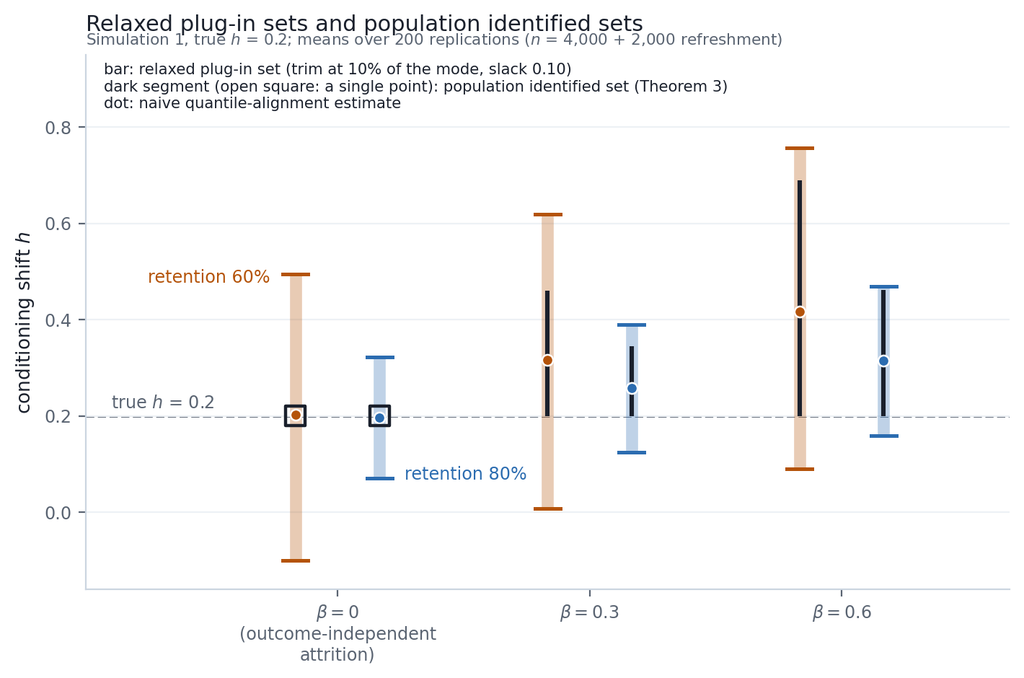

Figure 1: Relaxed plug-in sets and population identified sets, Simulation 1, true $h = 0.2$. Bars: mean over 200 replications of the relaxed plug-in set (support trimmed at 10% of the refreshment density’s mode, slack 0.10). Dark segments: the population identified set of Theorem 3 for the same data-generating process (open squares: a single point). Dots: mean naive quantile-alignment estimate. The plug-in widths reflect the trim and the slack; the population sets widen with selection strength and narrow with retention.

**Simulation 2 (Theorem 4, Corollary 7).** *Data-generating mechanism*: three cohorts entering at waves 1, 5 and 13 ($n = 3{,}000$ each), compared at wave 13; a latent trait $u_i \sim N(0,1)$ and per-wave retention $\Lambda(1.6 + 0.6u_i)$, so that the first cohort has passed twelve response decisions and the second eight; target item $y = g_e + \tau(s) + u + e$ with $e \sim N(0,1)$ and $\tau(s) = .15(1 - e^{-(s-1)/4})$; a $K = 23$ negative-control battery measured at entry, $x_k = .6u + \eta_k$; a generational variant adds a cohort effect $g = .35$ to the wave-13 entrants’ target item; a contaminated variant adds recall drift $.15$ to three battery items of the first cohort; 300 replications. *Estimands*, in units of the target’s population standard deviation $\sqrt 2$: the incumbent increment $(\tau(13) - \tau(9))/\sqrt2 = .15(e^{-2} - e^{-3})/\sqrt2 = .0091$ and the level contrast $(\tau(13) - \tau(1))/\sqrt2 = .1008$. *Methods*: contrasts of survivors’ raw means, divided by $\sqrt 2$; negative-control corrections subtract $\Gamma$ times the mean raw battery contrast of the same pair of cohorts, with the true raw loading $\Gamma = 1/.6$ (exact (A2)) or a unit loading on the population-standardized scale ($\Gamma = \sqrt2/\sqrt{1.36}$, an under-correction by the factor $.73$); a screened correction removes items flagged by a per-item outlier screen ($|z| > 2.5$, centred at the median item contrast) before pooling by the mean, and a median-pooled correction uses the median item contrast. The script also computes the population limit of each estimator by numerical integration. *Performance*: the naive increment is biased by $.152$ (population limit $.151$) from differential selection; the correction with the true loading has bias $.002$ (Monte Carlo standard error $.002$; population limit zero) and RMSE $.042$; the unit loading leaves $.043$ (limit $.041$): (A2) is a substantive assumption, and a miscalibrated loading under-corrects in proportion. The corrected level contrast has bias $.003$ (standard error $.002$) in the age-matched design and $-.250$ in the generational design, where the corrected contrast contains $-g/\sqrt2 = -.247$; the incumbent increment stays unbiased there ($-.000$). The battery-homogeneity $Q$ test rejects at $.003$–$.007$ at nominal $.05$ without drift and at $.34$ with three drifted items; the screen flags at least one of the three drifted items in $68\%$ of replications, against $2\%$ for the same three items without drift, and flags an undrifted item at a per-item rate below $.01$. Undetected drift contaminates the mean-pooled correction (bias $-.017$); screening before pooling ($-.007$) and median pooling ($-.006$) reduce it.

**Simulation 3 (constructive designs and diagnostics; Section 7–Section 8).** *Data-generating mechanism*: model (M) of Proposition 5 with a continuing cohort of $n_{\text{old}} = 4{,}800$ entering at wave 1 and a fresh cohort of $n_{\text{new}} = 960$ entering at wave 5 (dose $k = 4$); latent outcome $Y^{*}_{it} = 0.5X_i + 0.5U_i + \varepsilon_{it}$ with $X_i \sim$ Bernoulli$(.5)$, $U_i \sim N(0,1)$, $\varepsilon_{it} \sim N(0,1)$ independent across waves, untreated standard deviation $1.146$; a heterogeneous conditioning shift $\tau_i(s) = 0.30\{1 - e^{-(s-1)/4}\}(1 + \gamma U_i)$ whose population mean at $s = 5$ is $0.190$ ($0.166$ standard deviations); and a dropout logit $-2.2 + a_X X_i + b_w U_i + a_E\varepsilon_{iw}$ for the decision taken at wave $w$. Six regimes: MCAR; MAR on $X$ ($a_X = .8$); MNAR on the trait ($a_X = .4$, $b_w = .8$); non-stationary MNAR on the trait, in which the trait coefficient is $1.4$ at the continuing cohort’s waves before the comparison wave and $.8$ at every other wave of both cohorts, so that trait selection is stronger in the continuing cohort’s selection period; state-dependent MNAR ($a_X = .4$, $b_w = .4$, $a_E = .8$); and both failures together. Heterogeneity is $\gamma = .3$ (survivor targets $h^{S}$ and $h^{S+}$ differ from the population shift and from each other, the case B5 excludes) or $\gamma = 0$. *Estimands*: $h^{S}$ (SM, EC, naive), $h^{S+}$ (SSM), the population shift (IPW). *Methods*: the five estimators with influence-function standard errors that include the estimated group shares (Section 13); the diagnostics $\mathcal{T}_{\mathrm{NS}}$ and $\mathcal{T}_{\mathrm{SD}}$ at the 5% level. *Performance measures*: bias against each estimator’s own estimand and against the population shift, coverage of 95% intervals, rejection rates. There are $R = 1{,}000$ replications per regime and setting. The two settings of $\gamma$ within a regime use the same seed, so their data are identical apart from the shift (common random numbers) and paired differences isolate the effect of heterogeneity. Part D adds the variance experiments described below. Code: `sims/sim3_designs.R`.

Table 3: Simulation 3, bias against each estimator’s own estimand in outcome units (95% coverage in parentheses) and rejection rates of the two diagnostics at the 5% level; 1,000 replications per regime. Monte Carlo standard errors of the biases are at most 0.002 and of the rejection rates at most 0.016.

| Regime ($\gamma = 0.3$) | naive | SM | SSM | EC | IPW | $\mathcal{T}_{\mathrm{NS}}$ rej. | $\mathcal{T}_{\mathrm{SD}}$ rej. |
| --- | --- | --- | --- | --- | --- | --- | --- |
| MCAR | +.001 (.94) | −.000 (.95) | −.000 (.95) | +.001 (.95) | .000 | .046 | .053 |
| MAR on $X$ | −.058 (.75) | −.001 (.96) | −.002 (.95) | −.001 (.96) | −.001 | .041 | .056 |
| MNAR trait | −.198 (.00) | .000 (.94) | +.002 (.94) | −.001 (.94) | −.198 | .039 | .056 |
| MNAR non-stationary | −.279 (.00) | **−.081 (.65)** | **−.068 (.76)** | −.002 (.95) | −.292 | **.623** | .078 |
| MNAR state-dependent | −.127 (.17) | **+.104 (.53)** | +.002 (.95) | **+.103 (.36)** | −.115 | .040 | **.993** |
| MNAR, both failures | −.292 (.00) | +.012 (.93) | **−.062 (.80)** | **+.078 (.59)** | −.306 | **.430** | **.945** |

The first five rows of Table 3 match Proposition 5(i)–(ii) row by row: survival matching fails under non-stationarity and under state dependence, symmetric matching only under non-stationarity, the entry-wave correction only under state dependence, and under state dependence survival matching and the entry-wave correction carry the same bias ($+.104$ and $+.103$), so that $\mathcal{T}_{\mathrm{NS}}$ keeps its nominal size there. The sixth row is a case the diagnostics cannot classify: with both failures present, $\mathcal{T}_{\mathrm{SD}}$ rejects almost always and $\mathcal{T}_{\mathrm{NS}}$ less than half the time, and the estimator with the smallest bias is survival matching; its restriction fails, but the two failures bias it in opposite directions. A rejection is evidence of incompatibility among the maintained restrictions, and a non-rejection of one statistic is not evidence that the corresponding restriction holds.

*Survivor versus population targets (Proposition 4).* This part illustrates, for a continuous outcome, the distinction that Das, Toepoel, and van Soest (2011, 41, and online Appendix 1, pp. 27–28) draw for binary items between the population and the survivor target of the same functional. With heterogeneous shifts ($\gamma = 0.3$), dropout increases with $U$, so the survivors carry smaller shifts than the population: under MNAR on the trait the survivor target averages $.170$ against a population shift of $.190$. The entry-wave correction is unbiased for the survivor effect $h^{S}$ ($-.001$) and biased for the population shift ($-.021$, or 11% of $\tau(5)$); with homogeneous shifts ($\gamma = 0$) the two targets coincide and the population bias is $-.001$. Because the two settings share their data, the paired difference of the population biases, $-.020$, is the composition term $\mathbb{E}[\tau_i \mid S] - \mathbb{E}[\tau_i]$ up to a Monte Carlo error below $.0001$. Read as an estimate of the population effect (the target of their Assumption 3, a stationarity-of-attrition-bias assumption on the conditioned outcome, which fails in this design because survival selects on the heterogeneity of the shift), the functional is off by that composition term; read as an estimate of $h^{S}$ under B4 (their Assumption 3$^{\mathrm{Alt}}$ for a binary item), it is unbiased here. Survival matching and symmetric matching show the same gap of about $.02$ between their survivor and population readings. The paired comparison also shows the role of B5: the $\mathcal{T}_{\mathrm{SD}}$ rejection rate under MNAR on the trait is $.056$ with heterogeneous shifts and $.044$ when the composition term $h^{S+} - h^{S}$ is switched off (paired difference $.012$, Monte Carlo standard error $.005$).

*Variance (Section 13).* In Part A the share terms are small relative to the within-group variances, and the coverage of the entry-wave correction is essentially the same with and without them (for example $.945$ and $.944$ under MNAR on the trait). Part D shows when they matter. In D1, a null experiment with well-separated groups (entry and comparison responses both equal to $U + N(0, .1^2)$ with $U \sim$ Bernoulli$(.5)$, survival $S = U$ in both cohorts, 500 entrants per cohort, no conditioning, 5,000 replications), the influence-function variance of the entry-wave correction averages $.00104$, against an empirical variance of $.00106$ and a theoretical value of $.00104$, and gives coverage $.947$ and a $\mathcal{T}_{\mathrm{NS}}$ rejection rate of $.056$; the within-group formula without share terms averages $.00054$ and gives $.839$ and $.706$. In D2, an exact counterexample ($E = S$, $Y = 1$ among survivors, a constant fresh outcome), the entry-wave estimate equals the survival share $\hat p$, whose variance is $p(1-p)/n$; the influence-function estimate is its plug-in version $\hat p(1 - \hat p)/n$, while the within-group formula returns zero. In D3, a person-level bootstrap within cohort that recomputes every arm and every share (200 replications, 200 resamples each) agrees with the influence-function standard errors to within one per cent in D1 and in the MNAR-trait and MNAR-state regimes.

**Deterministic checks (no sampling).** `check_funnel_examples.R` reproduces, on a fine grid with stated tolerances, the following: (a) the identified set $\{-1\}$ for $f_2 = N(0,1)$, $Q = N(-1,1)$, $p = .5$; (b) the attainment of $\Delta^{*} = \beta\sigma^2$ in the Gaussian–logistic example at $\alpha = -1$; (c) the point $\{0\}$ under outcome-independent attrition with Gaussian tails; (d) the Laplace and logistic half-widths $\log(1/p)$ and the Cauchy half-widths $(1-p)/\sqrt p$; (e) the central-binding example after Corollary 2 at $\sigma = .5$ and $.8$; (f) the disconnected identified sets of the modulated Cauchy and logistic densities of Corollary 3, together with the exponential-tail outer bound and the failure of the closed form without the Lipschitz condition; (g) the Lipschitz neighbourhood of Corollary 3(iii); (h) the discrete examples of Corollary 4; (i) the general-map example of Corollary 5; (j) the retention-only covariate of Proposition 1; (k) a case in which the per-pair outer bound of Theorem 4(a) is strictly larger than the common-loading set (block 11 of the script): a Laplace episode with $C_1 = 0$, $N_1 = 1$ and a Gaussian episode with $C_2 = 10$, $N_2 = 1$, both at $p = .5$, with $\Gamma \in [0, 1]$, where the Gaussian episode forces $\Gamma = 0$, so that the common-loading set for the first episode is $\{0\}$ and not $[-\log 2, 0]$; and (l) the example following Theorem 4, in which the loading set computed from the margins, $[0, .817]$, strictly contains the set under the joint version of (A1), $[0, .263]$ (block 12). `check_multiwave_completion.R` enumerates, without sampling, a four-wave cohort on the latent lattice $\{-5, \dots, 5\}$ with a binary entry-only negative control, all eight response patterns (interrupted ones included), true conditioning by integer location shifts $(0, 1, 0, 1)$, and a selection kernel that depends on the whole latent path including the never-reported coordinates and that excludes the lowest latent value from responding at wave 4. For every candidate map $c'_4 = c_4 + \epsilon$, $\epsilon \in \{-3, \dots, 3\}$, with one arbitrary choice of candidate maps at the intermediate waves (shifts of $+1$ and $-1$ at waves 2 and 3), the completion of Lemma 2 is constructed explicitly. Exactly one non-trivial candidate, $\epsilon = +1$, satisfies the wave-4 domination inequality. For it and for $\epsilon = 0$ every pattern sub-measure, the entry marginal including the negative control, and the refreshment marginal are reproduced within the script’s tolerance of $10^{-10}$, the kernel is a valid Markov kernel, the survivors’ latent mean at wave 4 moves by $-\epsilon$, and the negative-control contrast does not move. For every other $\epsilon$ the leftover $L_4$ has a negative entry. Restricting the same example to monotone patterns verifies the sequential form $\pi'_j = dN_{j+1}/dN_j$. The script also enumerates all 35 weakly increasing maps on four categories and confirms in every instance that the mass criterion Equation 1 coincides with a linear-programming feasibility test, with the identity as the sole feasible map when all categories are reported and non-identity maps feasible only when a category goes unreported. It also confirms the Gaussian widths of Corollary 6 ($.390$, $.700$, $1.288$, $1.596$ at $p = .9, .8, .6, .5$) by closed form, numerical integration, and a linear programme on a grid. `check_design_rank.py` computes, in exact rational arithmetic, the rank and the projected kernel of every design quoted in Section 9 and Table 2, the example of Theorem 5(iii) and its null vector, the four-cohort example of Proposition 7(iii), and the effect of level and plateau anchors on the Japanese panel’s support. It also checks, on all 2,214 staggered trapezoids with three to five cohorts, first entry at wave 1, later entries in $\{2, \dots, 10\}$ and up to eight periods of follow-up, the component count, the sufficient follow-up condition, the exact three-cohort formula and the upper bound of the companion identification paper’s Lemma 1. On 65 of these designs every pair of observed tenures is linked through tenures observed in common periods although the identified set is larger than $d$.

# 13 Appendix: Variance of the Design Estimators

Each estimator of Section 7 and each diagnostic of Section 8 is a difference of subset means computed within two independent cohorts. For a cohort of $n$ persons and a subset indicator $B_i$, the mean $\bar Y_B = \sum_i B_i Y_i / \sum_i B_i$ has influence function $\psi_i = B_i(Y_i - \mu_B)/\Pr(B)$; a linear combination of subset means within the cohort has the corresponding combination of influence functions, and its variance is estimated by $\sum_i \hat\psi_i^2/n^2$. For the entry-wave correction, with $S$ survival through $t$, $E$ the entry response and $Y$ the response at $t$, the continuing-cohort component $\hat A = \bar Y_S - (\bar E_S - \bar E)$ satisfies
$$n\,\mathrm{Var}(\hat A) \;\approx\; \frac{\mathrm{Var}\{Y - (1-p)E \mid S\}}{p} \;+\; (1-p)\,\mathrm{Var}(E \mid \text{NS}) \;+\; p(1-p)\,(\mu_{E,S} - \mu_{E,\text{NS}})^2 ,$$
where the last term comes from estimating the survivors’ share $p$; a variance computed conditionally on the group sizes omits it. The diagnostics $\mathcal{T}_{\mathrm{NS}} = (\bar E_S - \bar E) - (\bar Y_{m} - \bar Y)$ and $\mathcal{T}_{\mathrm{SD}} = (\bar Y_{S+} - \bar Y_S) - (\bar Y_{m+1} - \bar Y_{m})$, where $\bar Y_{S+}$ averages the continuing survivors who also respond at $t+1$ and $\bar Y_m$, $\bar Y_{m+1}$ the fresh respondents who go on to respond for $k$ and $k+1$ further waves, contain the analogous share terms in both cohorts. A person-level bootstrap within cohort that recomputes every arm and every share targets the same variance. Simulation 3 and version 0.1.4 of the R package `panelcond` use the influence-function formulas; the empirical results of Section 10 use the bootstrap.

# 14 Appendix: The Negative-Control Battery at the 2019 Episode

Table 4: Negative-control contrasts between the 2007 cohort at tenure 13 and the 2011 cohort at tenure 9, on their common birth-year support (1966–1986), standardized and pooled over three-year birth band by sex strata; aggregates computed from the licensed JLPS microdata by the replication kit. <sup>a</sup> Rejected at a Benjamini–Hochberg $q < .10$. <sup>b</sup> Standard error under independence across items; the person-bootstrap standard error is $.0186$ (design effect $3.84$).

| Item (reported once at entry) | $d$ | SE |
| --- | --- | --- |
| Possessions in the home at age 15: air conditioner | −.033 | .045 |
| television | −.032 | .047 |
| personal computer or word processor | .015 | .045 |
| video recorder | .040 | .045 |
| piano | −.074 | .045 |
| radio | −.092 | .045 |
| refrigerator | −.103 | .046 |
| second home | .009 | .049 |
| study desk | −.033 | .045 |
| reception room furniture | −.051 | .045 |
| owner-occupied home | −.014 | .045 |
| literature collection or illustrated encyclopedia | −.012 | .045 |
| farmland or forest (excluding a kitchen garden) | −.015 | .045 |
| encyclopedia | .025 | .045 |
| works of art or antiques | .023 | .045 |
| car | .022 | .045 |
| microwave oven | −.020 | .045 |
| telephone (mobile telephones included)<sup>a</sup> | −.176 | .045 |
| bath | −.069 | .046 |
| Number of books in the home at age 15 | .078 | .049 |
| Family atmosphere at age 15 | −.106 | .045 |
| Household living standard at age 15 | −.096 | .045 |
| School grades in junior high school | −.069 | .046 |
| Inverse-variance pooled value | −.035 | .0095<sup>b</sup> |

# Data and code availability

The simulations and deterministic checks generate their own data; no restricted data are needed to reproduce the appendix. Their code and outputs, the figure script, and the manuscript source are in the replication archive at https://github.com/sokubo/paper-refreshment-designs-replication; the version corresponding to this manuscript is tag `paper-v1.5` (computational commit `f4f7c2b`). The archive’s README maps each table, figure and quoted simulation value to the script and output file that produce it, and `sims/check_manuscript_values.R` asserts those values against named output cells. The empirical illustration of Section 10 uses the integrated release (waves 1–19) of the Japanese Life Course Panel Surveys (JLPS) distributed to participants of the survey project; the microdata cannot be redistributed. Other researchers can apply for JLPS releases to the SSJDA Data Archive of the Center for Social Research and Data Archives, Institute of Social Science, The University of Tokyo (at the time of writing, the current releases are the study numbers PY160 and PM160). Those releases differ from the integrated file, so an analysis of them with the archived code is a re-analysis with the same design and definitions, not a replication. The archive contains the code that reads the licensed files and produces every aggregate quoted in Section 10 (`kit/R/`), a document stating the access route, the variables and the recoding (`kit/KIT_README.md`), and a synthetic data set with the outputs the code produces on it, so that the workflow for the 2011 episode can be run end to end without the licensed data. The scripts for the 2019 negative-control battery need the confidential map from items to variables and are not exercised by the synthetic example. Every script reads one explicitly named input file and records its name and SHA-256; `kit/KIT_README.md` gives the file name and fingerprint of the input behind Section 10, and `kit/check_manuscript_values_T2.R` reproduces every quoted aggregate from the aggregate outputs after checking that all of them record that input. The aggregate outputs computed from the licensed data are reported in the paper (Section 10, Table 4) and are not otherwise redistributed. The R package `panelcond`, version 0.1.6 (https://github.com/sokubo/panelcond, tag `v0.1.6`), implements the estimators, the diagnostics, the variance formulas of Section 13 and the design-rank calculation; the design run behind Section 10 used that version, whose covariate-standardized entry-wave correction integrates both regression terms over the survivors’ covariate distribution (versions up to 0.1.5 integrated them over two populations, Section 10). The analytic-variance correction of version 0.1.4 changed no bootstrap result, whereas the standardized functional of 0.1.6 and its bootstrap summaries were recomputed for this version. The standard errors and diagnostic uncertainties for the Section 10 design comparisons are computed using the joint person bootstrap rather than the package’s analytic-variance columns. The negative-control analysis separately reports item-level uncertainties, the independence-based pooled benchmark, and the person-bootstrap pooled uncertainty.

# References

Bach, Ruben L. 2018. “A Methodological Framework for the Analysis of Panel Conditioning Effects.” Working paper, University of Mannheim, May 2018, the version cited. A revised version is chapter 2 of A. Cernat and J. W. Sakshaug (eds.), *Measurement Error in Longitudinal Data*, Oxford University Press, 2021, pp. 19–41, doi:10.1093/oso/9780198859987.003.0002.

Bailar, Barbara A. 1975. “The Effects of Rotation Group Bias on Estimates from Panel Surveys.” *Journal of the American Statistical Association* 70 (349): 23–30. https://doi.org/10.1080/01621459.1975.10480255.

Bertoli, Andrew, Laura Jakli, and Henry Pascoe. 2026. “Analyzing the Impact of Events Through Surveys: Formalizing Biases and Introducing the Dual Randomized Survey Design.” *Political Science Research and Methods* 14 (2): 255–75. https://doi.org/10.1017/psrm.2026.10088.

Chadi, Adrian. 2021. “Identification of Attrition Bias Using Different Types of Panel Refreshments.” *Economics Letters* 201: 109777. https://doi.org/10.1016/j.econlet.2021.109777.

Das, Marcel, Vera Toepoel, and Arthur van Soest. 2011. “Nonparametric Tests of Panel Conditioning and Attrition Bias in Panel Surveys.” *Sociological Methods & Research* 40 (1): 32–56. https://doi.org/10.1177/0049124110390765.

Deng, Yiting, D. Sunshine Hillygus, Jerome P. Reiter, Yajuan Si, and Siyu Zheng. 2013. “Handling Attrition in Longitudinal Studies: The Case for Refreshment Samples.” *Statistical Science* 28 (2): 238–56. https://doi.org/10.1214/13-STS414.

Eckman, Stephanie, and Ruben Bach. 2021. “Panel Conditioning in the U.S. Consumer Expenditure Survey.” *Journal of Official Statistics* 37 (1): 53–69. https://doi.org/10.2478/JOS-2021-0003.

Feng, Shuaizhang, Yingyao Hu, and Jiandong Sun. 2022. “Rotation Group Bias and the Persistence of Misclassification Errors in the Current Population Surveys.” *Econometric Reviews* 41 (9): 1077–94. https://doi.org/10.1080/07474938.2022.2091361.

Franguridi, Grigory, Jinyong Hahn, Pierre Hoonhout, Arie Kapteyn, and Geert Ridder. 2026. “Raking for Estimation and Inference in Panel Models with Nonignorable Attrition and Refreshment.” *arXiv Preprint arXiv:2512.13270v2*. https://arxiv.org/abs/2512.13270v2.

Franguridi, Grigory, and Arie Kapteyn. 2026. “Testing Selection on Observables in Parametric Models with Refreshment Samples.” *arXiv Preprint arXiv:2608.23508v2*. https://arxiv.org/abs/2608.23508v2.

Franguridi, Grigory, and Lidia Kosenkova. 2026. “Closed-Form Estimation and Inference for Panels with Attrition and Refreshment Samples.” *arXiv Preprint arXiv:2410.11263v3*. https://arxiv.org/abs/2410.11263v3.

Ghanem, Dalia, Sarojini Hirshleifer, and Karen Ortiz-Becerra. 2026. “Testing Attrition Bias in Field Experiments.” *Journal of Human Resources* 61 (2): 690–731. https://doi.org/10.3368/jhr.0920-11190R2.

Halpern-Manners, Andrew, and John Robert Warren. 2012. “Panel Conditioning in Longitudinal Studies: Evidence from Labor Force Items in the Current Population Survey.” *Demography* 49 (4): 1499–519. https://doi.org/10.1007/s13524-012-0124-x.

Halpern-Manners, Andrew, John Robert Warren, and Florencia Torche. 2014. “Panel Conditioning in a Longitudinal Study of Illicit Behaviors.” *Public Opinion Quarterly* 78 (3): 565–90. https://doi.org/10.1093/poq/nfu029.

———. 2017. “Panel Conditioning in the General Social Survey.” *Sociological Methods & Research* 46 (1): 103–24. https://doi.org/10.1177/0049124114532445.

Hirano, Keisuke, Guido W. Imbens, Geert Ridder, and Donald B. Rubin. 2001. “Combining Panel Data Sets with Attrition and Refreshment Samples.” *Econometrica* 69 (6): 1645–59. https://doi.org/10.1111/1468-0262.00260.

Horowitz, Joel L., and Charles F. Manski. 1995. “Identification and Robustness with Contaminated and Corrupted Data.” *Econometrica* 63 (2): 281–302. https://doi.org/10.2307/2951627.

Kraemer, Fabienne, Peter Lugtig, Bella Struminskaya, Henning Silber, Bernd Weiß, and Michael Bosnjak. 2025. “Monitoring Attitudes over Time: Real Change or the Result of Repeated Interviewing?” *Sociological Methods & Research*. https://doi.org/10.1177/00491241251372503.

Kraemer, Fabienne, Henning Silber, Bella Struminskaya, Matthias Sand, Michael Bosnjak, Joanna Koßmann, and Bernd Weiß. 2024. “Panel Conditioning in a Probability-Based Longitudinal Study: A Comparison of Respondents with Different Levels of Survey Experience.” *Journal of Survey Statistics and Methodology* 12 (1): 36–59. https://doi.org/10.1093/jssam/smad004.

Krueger, Alan B., Alexandre Mas, and Xiaotong Niu. 2017. “The Evolution of Rotation Group Bias: Will the Real Unemployment Rate Please Stand Up?” *The Review of Economics and Statistics* 99 (2): 258–64. https://doi.org/10.1162/rest_a_00630.

Lee, David S. 2009. “Training, Wages, and Sample Selection: Estimating Sharp Bounds on Treatment Effects.” *The Review of Economic Studies* 76 (3): 1071–1102. https://doi.org/10.1111/j.1467-937X.2009.00536.x.

Manski, Charles F. 1989. “Anatomy of the Selection Problem.” *Journal of Human Resources* 24 (3): 343–60. https://doi.org/10.2307/145818.

Okubo, Shoki. 2024. “Identification Assumptions and Strategies for Panel Conditioning Bias based on Potential Outcomes Model: A Natural Experiment Approach with an Additional Random Sampling for Panel Survey.” *Shakai to Chōsa*, no. 33: 58–70.

———. 2026. “Panel Conditioning in Fixed-Effects Models: Identification and Bias Propagation.” *arXiv Preprint arXiv:2609.28871v1*. https://arxiv.org/abs/2609.28871v1.

Park, You Sung, Kee Whan Kim, and Jai Won Choi. 2001. “One-Level Rotation Design Balanced on Time in Monthly Sample and in Rotation Group.” *Journal of the American Statistical Association* 96 (456): 1483–96. https://doi.org/10.1198/016214501753382381.

Strassen, Volker. 1965. “The Existence of Probability Measures with Given Marginals.” *The Annals of Mathematical Statistics* 36 (2): 423–39. https://doi.org/10.1214/aoms/1177700153.

Struminskaya, Bella. 2016. “Respondent Conditioning in Online Panel Surveys: Results of Two Field Experiments.” *Social Science Computer Review* 34 (1): 95–115. https://doi.org/10.1177/0894439315574022.

Torche, Florencia, John Robert Warren, Andrew Halpern-Manners, and Eduardo Valenzuela. 2012. “Panel Conditioning in a Longitudinal Study of Adolescents’ Substance Use: Evidence from an Experiment.” *Social Forces* 90 (3): 891–918. https://doi.org/10.1093/sf/sor006.

Van Landeghem, Bert. 2014. “A Test Based on Panel Refreshments for Panel Conditioning in Stated Utility Measures.” *Economics Letters* 124 (2): 236–38. https://doi.org/10.1016/j.econlet.2014.05.024.

———. 2019. “Stable Traits but Unstable Measures? Identifying Panel Effects in Self-Reflective Survey Questions.” *Journal of Economic Psychology* 72: 83–95. https://doi.org/10.1016/j.joep.2019.02.006.

Warren, John Robert, and Andrew Halpern-Manners. 2012. “Panel Conditioning in Longitudinal Social Science Surveys.” *Sociological Methods & Research* 41 (4): 491–534. https://doi.org/10.1177/0049124112460374.

Warren, John Robert, Jessie Himmelstern, and Andrew Halpern-Manners. 2024. “Panel Conditioning Biases in the Current Population Survey’s Food Security Supplement.” *Public Opinion Quarterly* 88 (1): 193–213. https://doi.org/10.1093/poq/nfae001.

Williams, W. H., and C. L. Mallows. 1970. “Systematic Biases in Panel Surveys Due to Differential Nonresponse.” *Journal of the American Statistical Association* 65 (331): 1338–49. https://doi.org/10.1080/01621459.1970.10481169.